# R Notebook

# Evaluating Modelling Techniques to Detect Precursors to Landslides from InSAR-Based Data

**2026 Honours Project -**

```r
# Load packages

library(readxl)
library(ggplot2)
library(MASS)
library(factoextra)
library(gridExtra)
library(cluster)
library(clusterSim)
library(dbscan)
library(dtwclust)
library(patchwork)
library(ggplotify)
library(zoo)
library(tidyr)
library(dplyr)


set.seed(1234)
```

# Stage 3: Temporal Clustering

We attempt to introduce a temporal aspect to our previous clustering methods by using an “expanding window” approach and tracking the cluster membership tracking.

## 1. Prepare the data

We prepare the data the same as we have in Stages 1 and 2.

```r
cadia <- read_excel("../data/Cadia_PS_2018.xlsx")

peru_failed <- read_excel("../data/Cobriza_Peru_Failed_2019.xlsx")

peru_unfailed <- read_excel("../data/Cobriza_Peru_Unfailed_2019.xlsx")

feijao_53 <- read_excel("../data/Feijao_PS_T53.xlsx")

feijao_155 <- read_excel("../data/Feijao_PS_T155.xlsx")
```

```r
head(cadia)
```

| velocity | coherence | MuSigma | Hprecision | Vprecision | range | azimuth | SubArea.ID | lon | lat | xpos | ypos | zpos | Z | ALOS | ILOS | Hcorrectio | D_20160927 | D_20161009 | D_20161015 | D_20161021 | D_20161102 | D_20161114 | D_20161126 | D_20161208 | D_20161220 | D_20170101 | D_20170113 | D_20170125 | D_20170206 | … |
| --- | --- | --- | --- | --- | --- | --- | --- | --- | --- | --- | --- | --- | --- | --- | --- | --- | --- | --- | --- | --- | --- | --- | --- | --- | --- | --- | --- | --- | --- | --- |
| 1.755 | 0.796 | 2.337 | 4.393 | 1.067 | 339 | 12 | 0 | 148.9938 | -33.49118 | 148.9938 | -33.49118 | 747.8138 | 723.9849 | -74.613 | 35.373 | 2.731 | 0 | -0.4 | -1.7 | 1.9 | -0.5 | -2.7 | 0.1 | -2.0 | 0.3 | 0.4 | -1.2 | -1.3 | -1.9 | … |
| 2.724 | 0.765 | 2.810 | 4.756 | 1.155 | 340 | 12 | 0 | 148.9938 | -33.49118 | 148.9938 | -33.49118 | 746.7826 | 722.9537 | -74.613 | 35.373 | 1.563 | 0 | 0.1 | -0.3 | 0.1 | 0.7 | -1.2 | 0.5 | 0.5 | 0.2 | 0.3 | -0.1 | -1.4 | -1.9 | … |
| -12.094 | 0.764 | 2.923 | 4.766 | 1.158 | 343 | 12 | 0 | 148.9935 | -33.49111 | 148.9935 | -33.49111 | 762.4835 | 738.6554 | -74.613 | 35.375 | 16.864 | 0 | -3.5 | 1.0 | -3.6 | -2.7 | -2.0 | -1.7 | -4.0 | -2.5 | -4.1 | -1.6 | -3.5 | -7.1 | … |
| -12.097 | 0.777 | 2.317 | 4.623 | 1.123 | 344 | 12 | 0 | 148.9935 | -33.49111 | 148.9935 | -33.49111 | 762.4712 | 738.6432 | -74.613 | 35.375 | 16.733 | 0 | -2.2 | 9.3 | -4.8 | -1.8 | -3.0 | 3.1 | 0.0 | 2.0 | 0.0 | 0.9 | -0.4 | -3.8 | … |
| -25.000 | 0.649 | 2.209 | 6.040 | 1.467 | 346 | 12 | 0 | 148.9935 | -33.49111 | 148.9935 | -33.49111 | 760.4321 | 736.6040 | -74.613 | 35.375 | 14.503 | 0 | -8.1 | -5.3 | -8.2 | -8.4 | -10.0 | -7.7 | -15.7 | -12.0 | -14.9 | -11.5 | -12.8 | -15.6 | … |
| -16.409 | 0.684 | 1.731 | 5.666 | 1.377 | 349 | 12 | 0 | 148.9933 | -33.49108 | 148.9933 | -33.49108 | 764.4135 | 740.5857 | -74.613 | 35.376 | 18.312 | 0 | 6.8 | 15.9 | 17.8 | 9.7 | 11.4 | 5.2 | 8.9 | 2.3 | 8.6 | 3.3 | 4.8 | 1.7 | … |

```r
dim(cadia)
```

```
[1] 12502    62
```

```r
head(peru_failed)
```

| FID | Shape | velocity | coherence | MuSigma | Hprecision | Vprecision | range | azimuth | SubArea ID | lon | lat | xpos | ypos | zpos | Z | ALOS | ILOS | Hcorrectio | D_20170908 | D_20170920 | D_20171002 | D_20171014 | D_20171026 | D_20171107 | D_20171119 | D_20171201 | D_20171213 | D_20171225 | D_20180106 | … |
| --- | --- | --- | --- | --- | --- | --- | --- | --- | --- | --- | --- | --- | --- | --- | --- | --- | --- | --- | --- | --- | --- | --- | --- | --- | --- | --- | --- | --- | --- | --- |
| 338 | Point ZM | 6.871 | 0.652 | 1.841 | 7.233 | 1.054 | 546 | 20 | 0 | -74.37384 | -12.58578 | -74.37384 | -12.58578 | 2270.982 | 2237.138 | -76.795 | 40.956 | 34.653 | 0 | -5.5 | -0.3 | 0.0 | -14.0 | -11.1 | 1.6 | -9.7 | -7.4 | -2.5 | 0.9 | … |
| 395 | Point ZM | 21.725 | 0.487 | 1.758 | 9.388 | 1.367 | 533 | 21 | 0 | -74.37374 | -12.58593 | -74.37374 | -12.58593 | 2278.416 | 2244.570 | -76.795 | 40.956 | 59.162 | 0 | -1.3 | 4.9 | -3.0 | -0.6 | 0.3 | -3.4 | -7.1 | -3.7 | 4.6 | 9.5 | … |
| 396 | Point ZM | -7.230 | 0.602 | 1.890 | 7.885 | 1.149 | 535 | 21 | 0 | -74.37383 | -12.58591 | -74.37383 | -12.58591 | 2283.732 | 2249.887 | -76.795 | 40.956 | 64.053 | 0 | 2.3 | 1.3 | 4.8 | -15.8 | -1.8 | -0.2 | 0.3 | -3.3 | -11.0 | -10.5 | … |
| 399 | Point ZM | 19.621 | 0.569 | 1.767 | 8.314 | 1.211 | 540 | 21 | 0 | -74.37387 | -12.58590 | -74.37387 | -12.58590 | 2280.480 | 2246.634 | -76.795 | 40.957 | 58.316 | 0 | 4.9 | 4.2 | 4.3 | 3.2 | 5.5 | 7.1 | 10.2 | 6.0 | 8.3 | 7.5 | … |
| 400 | Point ZM | 6.463 | 0.590 | 1.481 | 8.042 | 1.171 | 545 | 21 | 0 | -74.37397 | -12.58588 | -74.37397 | -12.58588 | 2282.399 | 2248.553 | -76.795 | 40.957 | 51.959 | 0 | 8.8 | 7.1 | 8.0 | 7.4 | -9.9 | 3.4 | -0.4 | 4.5 | -3.2 | -3.9 | … |
| 401 | Point ZM | 9.562 | 0.783 | 2.229 | 5.479 | 0.798 | 547 | 21 | 0 | -74.37393 | -12.58589 | -74.37393 | -12.58589 | 2275.392 | 2241.546 | -76.795 | 40.957 | 40.669 | 0 | -0.7 | 1.0 | 0.8 | -6.3 | -1.5 | -0.4 | -0.1 | 1.0 | -1.3 | -0.9 | … |

```r
dim(peru_failed)
```

```
[1] 991  73
```

```r
head(peru_unfailed)
```

| FID | Shape | velocity | coherence | MuSigma | Hprecision | Vprecision | range | azimuth | SubArea ID | lon | lat | xpos | ypos | zpos | Z | ALOS | ILOS | Hcorrectio | D_20170908 | D_20170920 | D_20171002 | D_20171014 | D_20171026 | D_20171107 | D_20171119 | D_20171201 | D_20171213 | D_20171225 | D_20180106 | … |
| --- | --- | --- | --- | --- | --- | --- | --- | --- | --- | --- | --- | --- | --- | --- | --- | --- | --- | --- | --- | --- | --- | --- | --- | --- | --- | --- | --- | --- | --- | --- |
| 4547 | Point ZM | -0.948 | 0.661 | 2.085 | 7.128 | 1.038 | 539 | 60 | 0 | -74.37499 | -12.59073 | -74.37499 | -12.59073 | 2279.769 | 2245.886 | -76.795 | 40.956 | 18.567 | 0 | -0.4 | -0.1 | -1.7 | -4.5 | -0.2 | -2.3 | -0.3 | -4.4 | -2.5 | -2.8 | … |
| 4548 | Point ZM | -2.557 | 0.710 | 2.272 | 6.480 | 0.944 | 540 | 60 | 0 | -74.37498 | -12.59074 | -74.37498 | -12.59074 | 2276.905 | 2243.022 | -76.795 | 40.956 | 15.399 | 0 | -3.2 | -1.2 | -3.5 | -5.7 | -2.5 | -4.8 | -1.7 | -5.7 | -3.9 | -5.0 | … |
| 4549 | Point ZM | -5.704 | 0.598 | 1.899 | 7.940 | 1.157 | 542 | 60 | 0 | -74.37491 | -12.59075 | -74.37491 | -12.59075 | 2267.278 | 2233.395 | -76.795 | 40.955 | 4.990 | 0 | -11.7 | -2.6 | -14.8 | -7.8 | -4.2 | -15.9 | -6.7 | 0.8 | -5.5 | -9.1 | … |
| 4550 | Point ZM | -8.245 | 0.473 | 1.674 | 9.570 | 1.394 | 544 | 60 | 0 | -74.37495 | -12.59074 | -74.37495 | -12.59074 | 2268.635 | 2234.752 | -76.795 | 40.956 | 5.382 | 0 | -1.6 | 4.7 | 6.7 | 7.8 | 5.6 | -9.8 | -3.9 | 4.7 | 6.4 | -4.9 | … |
| 4551 | Point ZM | -16.577 | 0.488 | 1.753 | 9.370 | 1.365 | 546 | 60 | 0 | -74.37506 | -12.59072 | -74.37506 | -12.59072 | 2276.218 | 2242.336 | -76.795 | 40.957 | 11.815 | 0 | -2.0 | 3.4 | 1.6 | -1.5 | -1.0 | -2.8 | -1.6 | -3.9 | -1.5 | -4.8 | … |
| 4552 | Point ZM | -3.217 | 0.624 | 2.376 | 7.605 | 1.108 | 549 | 60 | 0 | -74.37491 | -12.59075 | -74.37491 | -12.59075 | 2256.956 | 2223.074 | -76.795 | 40.955 | -9.314 | 0 | -17.5 | -11.4 | -10.9 | -8.5 | -22.5 | 1.4 | -21.4 | -0.6 | -11.0 | -9.7 | … |

```r
dim(peru_unfailed)
```

```
[1] 790  73
```

```r
head(feijao_53)
```

| velocity | coherence | MuSigma | Hprecision | Vprecision | range | azimuth | SubArea.ID | lon | lat | xpos | ypos | zpos | Z | ALOS | ILOS | Hcorrectio | D_20170613 | D_20170625 | D_20170707 | D_20170719 | D_20170731 | D_20170812 | D_20170824 | D_20170905 | D_20170917 | D_20170929 | D_20171011 | D_20171023 | D_20171104 | … |
| --- | --- | --- | --- | --- | --- | --- | --- | --- | --- | --- | --- | --- | --- | --- | --- | --- | --- | --- | --- | --- | --- | --- | --- | --- | --- | --- | --- | --- | --- | --- |
| 24.570 | 0.457 | 1.810 | 6.413 | 1.654 | 253 | 17 | 0 | -44.11507 | -20.11181 | -44.11507 | -20.11181 | 1088.758 | 1094.680 | -76.621 | 32.552 | -10.627 | 0 | 4.1 | 8.9 | -6.1 | 13.8 | 17.2 | 9.3 | 8.8 | 13.2 | 9.9 | 24.2 | 15.4 | 25.8 | … |
| 5.237 | 0.458 | 1.897 | 6.410 | 1.653 | 281 | 17 | 0 | -44.11557 | -20.11170 | -44.11557 | -20.11170 | 1084.675 | 1090.598 | -76.620 | 32.556 | -15.113 | 0 | 1.4 | 1.6 | 5.5 | 6.3 | -5.5 | -10.3 | -4.4 | -6.0 | -7.9 | -3.9 | 0.8 | -15.4 | … |
| 19.856 | 0.453 | 2.068 | 6.457 | 1.665 | 413 | 17 | 0 | -44.11826 | -20.11108 | -44.11826 | -20.11108 | 1087.090 | 1093.017 | -76.619 | 32.576 | 0.237 | 0 | -8.6 | -13.4 | -8.3 | -6.0 | -7.3 | -9.5 | -9.6 | -6.9 | -14.5 | -9.8 | -1.4 | 0.5 | … |
| 23.269 | 0.494 | 1.684 | 6.086 | 1.569 | 253 | 18 | 0 | -44.11512 | -20.11193 | -44.11512 | -20.11193 | 1089.730 | 1095.652 | -76.621 | 32.552 | -8.190 | 0 | 5.4 | 7.8 | 13.9 | 9.4 | 14.4 | 6.0 | 3.1 | 11.9 | 12.7 | 18.3 | 10.2 | 19.7 | … |
| -16.225 | 0.457 | 1.927 | 6.412 | 1.654 | 368 | 18 | 0 | -44.11841 | -20.11118 | -44.11841 | -20.11118 | 1156.999 | 1162.926 | -76.619 | 32.579 | 62.410 | 0 | 4.5 | 3.5 | 7.5 | 10.8 | -0.7 | -2.9 | -10.6 | 4.4 | -4.6 | 5.8 | -9.2 | -13.6 | … |
| -15.465 | 0.470 | 2.059 | 6.296 | 1.624 | 239 | 20 | 0 | -44.11466 | -20.11230 | -44.11466 | -20.11230 | 1073.712 | 1079.632 | -76.621 | 32.548 | -8.771 | 0 | 1.7 | -5.0 | -2.9 | -3.4 | 0.4 | -6.0 | 0.4 | -6.1 | -2.6 | -6.7 | -7.0 | 4.1 | … |

```r
dim(feijao_53)
```

```
[1] 11995    67
```

```r
head(feijao_155)
```

| velocity | coherence | MuSigma | Hprecision | Vprecision | range | azimuth | SubArea.ID | lon | lat | xpos | ypos | zpos | Z | ALOS | ILOS | Hcorrectio | D_20170608 | D_20170620 | D_20170702 | D_20170714 | D_20170726 | D_20170807 | D_20170819 | D_20170831 | D_20170912 | D_20170924 | D_20171006 | D_20171018 | D_20171030 | … |
| --- | --- | --- | --- | --- | --- | --- | --- | --- | --- | --- | --- | --- | --- | --- | --- | --- | --- | --- | --- | --- | --- | --- | --- | --- | --- | --- | --- | --- | --- | --- |
| 4.049 | 0.452 | 1.863 | 13.616 | 1.667 | 401 | 14 | 0 | -44.11461 | -20.11144 | -44.11461 | -20.11144 | 1096.3196 | 1102.2429 | -75.807 | 44.988 | 7.039 | 0 | -18.1 | -20.3 | -5.9 | -1.6 | -5.9 | -6.1 | 5.3 | -6.9 | -9.7 | -15.7 | -18.6 | -12.6 | … |
| 3.544 | 0.454 | 2.091 | 13.551 | 1.659 | 432 | 22 | 0 | -44.11572 | -20.11222 | -44.11572 | -20.11222 | 1136.8207 | 1142.7418 | -75.807 | 44.994 | 44.127 | 0 | 5.3 | 12.1 | 2.2 | 3.3 | 8.5 | 5.9 | 12.3 | 6.3 | 6.7 | 10.8 | 4.4 | 9.5 | … |
| 6.583 | 0.462 | 2.124 | 13.408 | 1.642 | 456 | 24 | 0 | -44.11510 | -20.11263 | -44.11510 | -20.11263 | 1022.9568 | 1028.8759 | -75.807 | 44.986 | -62.634 | 0 | -8.9 | -4.7 | -5.3 | -5.7 | -9.3 | -19.8 | -14.2 | -10.2 | -4.6 | 2.6 | -8.6 | -0.9 | … |
| -3.471 | 0.466 | 2.259 | 13.331 | 1.632 | 569 | 27 | 0 | -44.11697 | -20.11257 | -44.11697 | -20.11257 | 1028.1827 | 1034.1033 | -75.806 | 44.996 | -43.987 | 0 | -4.9 | -1.9 | -1.0 | -9.9 | 3.1 | -4.1 | 7.6 | -4.4 | 5.5 | -5.0 | 0.1 | -0.5 | … |
| 11.963 | 0.468 | 1.691 | 13.295 | 1.628 | 797 | 27 | 0 | -44.11975 | -20.11190 | -44.11975 | -20.11190 | 953.2993 | 959.2245 | -75.805 | 45.008 | -47.568 | 0 | 6.8 | -0.7 | -0.1 | -5.8 | -8.6 | -4.2 | -12.6 | -11.7 | 3.8 | 8.0 | 3.1 | 4.0 | … |
| 11.857 | 0.523 | 1.753 | 12.298 | 1.506 | 798 | 27 | 0 | -44.11978 | -20.11189 | -44.11978 | -20.11189 | 954.4973 | 960.4226 | -75.805 | 45.008 | -45.966 | 0 | 6.7 | 1.8 | 1.3 | -1.0 | -8.4 | -5.2 | 12.1 | -6.4 | 3.0 | 9.4 | 2.2 | 4.1 | … |

```r
dim(feijao_155)
```

```
[1] 15039    67
```

**Extract the displacement columns:**

```r
# Cadia --------------

d_cols <- grep("^D_", names(cadia), value = TRUE) # D_ for descending orbit track
length(d_cols)
```

```
[1] 45
```

```r
head(d_cols)
```

```
[1] "D_20160927" "D_20161009" "D_20161015" "D_20161021" "D_20161102" "D_20161114"
```

```r
cadia_D <- cadia[, d_cols]

# Inspect new dataset
head(cadia_D)
```

| D_20160927 | D_20161009 | D_20161015 | D_20161021 | D_20161102 | D_20161114 | D_20161126 | D_20161208 | D_20161220 | D_20170101 | D_20170113 | D_20170125 | D_20170206 | D_20170218 | D_20170302 | D_20170314 | D_20170326 | D_20170407 | D_20170419 | D_20170501 | D_20170513 | D_20170525 | D_20170606 | D_20170618 | D_20170630 | D_20170712 | D_20170724 | D_20170805 | D_20170817 | D_20170829 | … |
| --- | --- | --- | --- | --- | --- | --- | --- | --- | --- | --- | --- | --- | --- | --- | --- | --- | --- | --- | --- | --- | --- | --- | --- | --- | --- | --- | --- | --- | --- | --- |
| 0 | -0.4 | -1.7 | 1.9 | -0.5 | -2.7 | 0.1 | -2.0 | 0.3 | 0.4 | -1.2 | -1.3 | -1.9 | -2.6 | -2.9 | -1.7 | -2.8 | -1.5 | -0.4 | -2.8 | -3.6 | -5.3 | -3.0 | -3.7 | -5.2 | -4.7 | 1.5 | -0.4 | 3.8 | -8.9 | … |
| 0 | 0.1 | -0.3 | 0.1 | 0.7 | -1.2 | 0.5 | 0.5 | 0.2 | 0.3 | -0.1 | -1.4 | -1.9 | -2.6 | -3.0 | -2.8 | -2.7 | -2.2 | -1.0 | -3.3 | -3.7 | -6.3 | -3.4 | -3.9 | -5.3 | -3.6 | 3.9 | 0.7 | 9.9 | 6.3 | … |
| 0 | -3.5 | 1.0 | -3.6 | -2.7 | -2.0 | -1.7 | -4.0 | -2.5 | -4.1 | -1.6 | -3.5 | -7.1 | -4.8 | -5.1 | -6.5 | -4.0 | -6.5 | -6.5 | -8.4 | -8.3 | -6.6 | -9.5 | -10.0 | -9.7 | -8.5 | -7.6 | -10.3 | -4.0 | -5.7 | … |
| 0 | -2.2 | 9.3 | -4.8 | -1.8 | -3.0 | 3.1 | 0.0 | 2.0 | 0.0 | 0.9 | -0.4 | -3.8 | -4.5 | -4.7 | -4.9 | -3.2 | -4.5 | -4.4 | -6.6 | -6.2 | -5.0 | -8.3 | -9.5 | -8.9 | -6.6 | -8.0 | -8.5 | -3.3 | -6.1 | … |
| 0 | -8.1 | -5.3 | -8.2 | -8.4 | -10.0 | -7.7 | -15.7 | -12.0 | -14.9 | -11.5 | -12.8 | -15.6 | -17.9 | -20.5 | -19.4 | -18.7 | -21.1 | -19.1 | -23.2 | -18.2 | -20.9 | -25.3 | -31.2 | -30.5 | -30.4 | -36.6 | -28.4 | -25.5 | -26.4 | … |
| 0 | 6.8 | 15.9 | 17.8 | 9.7 | 11.4 | 5.2 | 8.9 | 2.3 | 8.6 | 3.3 | 4.8 | 1.7 | 5.2 | 4.5 | 5.5 | 7.3 | 5.5 | 4.2 | 3.2 | 1.7 | 5.8 | 9.9 | 9.3 | -13.8 | -2.8 | -5.1 | -2.2 | 4.9 | -8.4 | … |

```r
dim(cadia_D)
```

```
[1] 12502    45
```

```r
# Check for missing vals
sum(is.na(cadia_D))
```

```
[1] 0
```

```r
# Peru - (Failed) ---------------------

d_cols_peru_F <- grep("^D_", names(peru_failed), value = TRUE)
length(d_cols_peru_F)
```

```
[1] 54
```

```r
head(d_cols_peru_F)
```

```
[1] "D_20170908" "D_20170920" "D_20171002" "D_20171014" "D_20171026" "D_20171107"
```

```r
peru_D_F <- peru_failed[, d_cols_peru_F]

head(peru_D_F)
```

| D_20170908 | D_20170920 | D_20171002 | D_20171014 | D_20171026 | D_20171107 | D_20171119 | D_20171201 | D_20171213 | D_20171225 | D_20180106 | D_20180118 | D_20180130 | D_20180211 | D_20180223 | D_20180307 | D_20180319 | D_20180331 | D_20180412 | D_20180424 | D_20180506 | D_20180518 | D_20180530 | D_20180623 | D_20180705 | D_20180717 | D_20180729 | D_20180810 | D_20180822 | D_20180903 | … |
| --- | --- | --- | --- | --- | --- | --- | --- | --- | --- | --- | --- | --- | --- | --- | --- | --- | --- | --- | --- | --- | --- | --- | --- | --- | --- | --- | --- | --- | --- | --- |
| 0 | -5.5 | -0.3 | 0.0 | -14.0 | -11.1 | 1.6 | -9.7 | -7.4 | -2.5 | 0.9 | 10.5 | -10.4 | 10.6 | 8.1 | 7.0 | 7.1 | 3.7 | 3.8 | 2.0 | -3.8 | 1.2 | 2.5 | 2.8 | 2.7 | 1.8 | 4.4 | 2.6 | 1.4 | 4.0 | … |
| 0 | -1.3 | 4.9 | -3.0 | -0.6 | 0.3 | -3.4 | -7.1 | -3.7 | 4.6 | 9.5 | -9.8 | -6.7 | 14.7 | 18.7 | 15.4 | 10.7 | 12.2 | 0.9 | 9.5 | 8.3 | 10.0 | 6.9 | 10.6 | 6.4 | 11.2 | 13.7 | 17.7 | 10.1 | 12.2 | … |
| 0 | 2.3 | 1.3 | 4.8 | -15.8 | -1.8 | -0.2 | 0.3 | -3.3 | -11.0 | -10.5 | -1.3 | -7.9 | -4.4 | -3.2 | -4.0 | -2.6 | -9.6 | -12.7 | -9.8 | -10.7 | -10.6 | -10.4 | -8.7 | -11.6 | -10.0 | -8.0 | -2.4 | -10.8 | -8.0 | … |
| 0 | 4.9 | 4.2 | 4.3 | 3.2 | 5.5 | 7.1 | 10.2 | 6.0 | 8.3 | 7.5 | 19.6 | 12.7 | 16.9 | 14.3 | 13.3 | 14.6 | 11.5 | 13.6 | 16.5 | 8.8 | 12.3 | 13.1 | 16.3 | 19.1 | 13.4 | 16.1 | 23.2 | 24.9 | 18.6 | … |
| 0 | 8.8 | 7.1 | 8.0 | 7.4 | -9.9 | 3.4 | -0.4 | 4.5 | -3.2 | -3.9 | 5.4 | -0.2 | 2.6 | -3.3 | 0.1 | 2.9 | -6.8 | -0.9 | 6.0 | -3.7 | 1.1 | 0.2 | 4.2 | 1.8 | 2.7 | 2.0 | 2.5 | -2.4 | 0.4 | … |
| 0 | -0.7 | 1.0 | 0.8 | -6.3 | -1.5 | -0.4 | -0.1 | 1.0 | -1.3 | -0.9 | 6.4 | -0.8 | -1.3 | -4.2 | -1.2 | 2.2 | -4.9 | -0.2 | 2.3 | 1.3 | 2.0 | 1.7 | 3.8 | 2.4 | 3.1 | 3.4 | 2.3 | 2.4 | 4.8 | … |

```r
dim(peru_D_F)
```

```
[1] 991  54
```

```r
# Check for missing vals
sum(is.na(peru_D_F))
```

```
[1] 0
```

```r
# Peru - (Unfailed) ---------------------

d_cols_peru_U <- grep("^D_", names(peru_unfailed), value = TRUE)
length(d_cols_peru_U)
```

```
[1] 54
```

```r
head(d_cols_peru_U)
```

```
[1] "D_20170908" "D_20170920" "D_20171002" "D_20171014" "D_20171026" "D_20171107"
```

```r
peru_D_U <- peru_unfailed[, d_cols_peru_U]

head(peru_D_U)
```

| D_20170908 | D_20170920 | D_20171002 | D_20171014 | D_20171026 | D_20171107 | D_20171119 | D_20171201 | D_20171213 | D_20171225 | D_20180106 | D_20180118 | D_20180130 | D_20180211 | D_20180223 | D_20180307 | D_20180319 | D_20180331 | D_20180412 | D_20180424 | D_20180506 | D_20180518 | D_20180530 | D_20180623 | D_20180705 | D_20180717 | D_20180729 | D_20180810 | D_20180822 | D_20180903 | … |
| --- | --- | --- | --- | --- | --- | --- | --- | --- | --- | --- | --- | --- | --- | --- | --- | --- | --- | --- | --- | --- | --- | --- | --- | --- | --- | --- | --- | --- | --- | --- |
| 0 | -0.4 | -0.1 | -1.7 | -4.5 | -0.2 | -2.3 | -0.3 | -4.4 | -2.5 | -2.8 | 7.7 | -3.4 | -3.5 | -1.8 | -3.4 | -1.3 | -3.4 | -6.5 | -3.7 | -4.8 | -5.5 | -4.9 | -4.8 | -6.7 | -5.4 | -8.2 | -4.2 | -12.3 | -13.3 | … |
| 0 | -3.2 | -1.2 | -3.5 | -5.7 | -2.5 | -4.8 | -1.7 | -5.7 | -3.9 | -5.0 | 3.7 | -5.2 | -4.6 | -4.9 | -6.3 | -4.5 | -6.5 | -8.4 | -6.4 | -7.3 | -6.8 | -6.8 | -7.6 | -8.7 | -7.7 | -10.2 | -6.4 | -12.7 | -11.4 | … |
| 0 | -11.7 | -2.6 | -14.8 | -7.8 | -4.2 | -15.9 | -6.7 | 0.8 | -5.5 | -9.1 | -7.7 | -8.9 | -10.4 | -12.7 | -19.5 | -10.9 | -11.7 | -11.7 | -13.3 | -13.9 | -11.1 | -11.7 | -11.9 | -11.1 | -10.1 | -12.9 | -10.8 | -9.4 | -10.3 | … |
| 0 | -1.6 | 4.7 | 6.7 | 7.8 | 5.6 | -9.8 | -3.9 | 4.7 | 6.4 | -4.9 | -5.1 | -4.9 | -4.8 | -5.7 | -5.2 | -4.5 | -6.7 | -7.1 | -7.0 | -5.1 | -4.3 | -6.0 | -1.9 | -2.7 | -3.8 | -3.8 | -6.2 | -1.7 | -1.3 | … |
| 0 | -2.0 | 3.4 | 1.6 | -1.5 | -1.0 | -2.8 | -1.6 | -3.9 | -1.5 | -4.8 | -10.4 | 4.2 | -4.1 | 0.7 | -6.4 | -5.4 | -19.7 | -10.5 | -10.6 | -6.9 | -5.6 | -8.1 | -1.0 | -7.9 | -9.0 | -7.8 | -15.5 | -8.4 | -5.3 | … |
| 0 | -17.5 | -11.4 | -10.9 | -8.5 | -22.5 | 1.4 | -21.4 | -0.6 | -11.0 | -9.7 | -10.2 | -12.6 | -10.0 | -8.7 | -8.4 | -12.1 | -12.5 | -16.3 | -11.6 | -9.0 | -9.7 | -7.1 | -11.2 | -11.6 | -10.0 | -7.3 | -16.0 | -9.2 | -6.8 | … |

```r
dim(peru_D_U)
```

```
[1] 790  54
```

```r
# Check for missing vals
sum(is.na(peru_D_U))
```

```
[1] 0
```

```r
# Feijao - (T53) ---------------------

d_cols_feijao_53 <- grep("^D_", names(feijao_53), value = TRUE)
length(d_cols_feijao_53)
```

```
[1] 50
```

```r
head(d_cols_feijao_53)
```

```
[1] "D_20170613" "D_20170625" "D_20170707" "D_20170719" "D_20170731" "D_20170812"
```

```r
feijao_D_53 <- feijao_53[, d_cols_feijao_53]

head(feijao_D_53)
```

| D_20170613 | D_20170625 | D_20170707 | D_20170719 | D_20170731 | D_20170812 | D_20170824 | D_20170905 | D_20170917 | D_20170929 | D_20171011 | D_20171023 | D_20171104 | D_20171116 | D_20171128 | D_20171210 | D_20171222 | D_20180103 | D_20180115 | D_20180127 | D_20180208 | D_20180220 | D_20180304 | D_20180316 | D_20180328 | D_20180409 | D_20180421 | D_20180503 | D_20180515 | D_20180527 | … |
| --- | --- | --- | --- | --- | --- | --- | --- | --- | --- | --- | --- | --- | --- | --- | --- | --- | --- | --- | --- | --- | --- | --- | --- | --- | --- | --- | --- | --- | --- | --- |
| 0 | 4.1 | 8.9 | -6.1 | 13.8 | 17.2 | 9.3 | 8.8 | 13.2 | 9.9 | 24.2 | 15.4 | 25.8 | 10.0 | 17.4 | 23.0 | 16.5 | 6.9 | 19.9 | 17.4 | 20.7 | 14.3 | 21.7 | 23.9 | 20.4 | 36.6 | 22.2 | 26.4 | 21.9 | 33.2 | … |
| 0 | 1.4 | 1.6 | 5.5 | 6.3 | -5.5 | -10.3 | -4.4 | -6.0 | -7.9 | -3.9 | 0.8 | -15.4 | -2.5 | -10.8 | 3.1 | -3.2 | -8.2 | -13.4 | -9.4 | 0.7 | -11.2 | -7.2 | -4.4 | -5.0 | -3.0 | -4.5 | -0.1 | 2.9 | -1.6 | … |
| 0 | -8.6 | -13.4 | -8.3 | -6.0 | -7.3 | -9.5 | -9.6 | -6.9 | -14.5 | -9.8 | -1.4 | 0.5 | 2.2 | -7.3 | 7.2 | -0.5 | -12.0 | 5.2 | 4.8 | 5.5 | 1.9 | -2.0 | 13.8 | 1.4 | 3.7 | 5.4 | 6.7 | 8.5 | 6.6 | … |
| 0 | 5.4 | 7.8 | 13.9 | 9.4 | 14.4 | 6.0 | 3.1 | 11.9 | 12.7 | 18.3 | 10.2 | 19.7 | 8.3 | 10.7 | 26.5 | 17.3 | 13.0 | 22.6 | 14.3 | 18.9 | 12.9 | 21.6 | 23.5 | 20.7 | 10.4 | 23.5 | 24.9 | 29.4 | 31.5 | … |
| 0 | 4.5 | 3.5 | 7.5 | 10.8 | -0.7 | -2.9 | -10.6 | 4.4 | -4.6 | 5.8 | -9.2 | -13.6 | -8.1 | -9.3 | -3.5 | -0.8 | -5.3 | -9.4 | -16.7 | -9.6 | -13.3 | -2.7 | -15.8 | -7.2 | -4.4 | -13.0 | -12.4 | -10.5 | -8.6 | … |
| 0 | 1.7 | -5.0 | -2.9 | -3.4 | 0.4 | -6.0 | 0.4 | -6.1 | -2.6 | -6.7 | -7.0 | 4.1 | -2.8 | -6.8 | 0.9 | -2.2 | -7.7 | -3.1 | -11.8 | -14.2 | -1.1 | -2.0 | 1.0 | -5.3 | -2.8 | -12.8 | -12.1 | -10.3 | -21.0 | … |

```r
dim(feijao_D_53)
```

```
[1] 11995    50
```

```r
# Check for missing vals
sum(is.na(feijao_D_53))
```

```
[1] 0
```

```r
# Feijao - (T155) ---------------------

d_cols_feijao_155 <- grep("^D_", names(feijao_155), value = TRUE)
length(d_cols_feijao_155)
```

```
[1] 50
```

```r
head(d_cols_feijao_155)
```

```
[1] "D_20170608" "D_20170620" "D_20170702" "D_20170714" "D_20170726" "D_20170807"
```

```r
feijao_D_155 <- feijao_155[, d_cols_feijao_155]

head(feijao_D_155)
```

| D_20170608 | D_20170620 | D_20170702 | D_20170714 | D_20170726 | D_20170807 | D_20170819 | D_20170831 | D_20170912 | D_20170924 | D_20171006 | D_20171018 | D_20171030 | D_20171111 | D_20171123 | D_20171205 | D_20171217 | D_20171229 | D_20180110 | D_20180122 | D_20180203 | D_20180215 | D_20180227 | D_20180311 | D_20180323 | D_20180404 | D_20180416 | D_20180428 | D_20180510 | D_20180522 | … |
| --- | --- | --- | --- | --- | --- | --- | --- | --- | --- | --- | --- | --- | --- | --- | --- | --- | --- | --- | --- | --- | --- | --- | --- | --- | --- | --- | --- | --- | --- | --- |
| 0 | -18.1 | -20.3 | -5.9 | -1.6 | -5.9 | -6.1 | 5.3 | -6.9 | -9.7 | -15.7 | -18.6 | -12.6 | -3.6 | -10.0 | -4.4 | -4.4 | -5.0 | -14.7 | -4.1 | -6.6 | -5.3 | -4.0 | -8.5 | -1.2 | -7.8 | -15.5 | -7.5 | -2.5 | -9.8 | … |
| 0 | 5.3 | 12.1 | 2.2 | 3.3 | 8.5 | 5.9 | 12.3 | 6.3 | 6.7 | 10.8 | 4.4 | 9.5 | 8.5 | 15.2 | -3.3 | 14.1 | 4.0 | 7.0 | 0.9 | 10.0 | 8.3 | -2.6 | 4.7 | -4.4 | 10.5 | 9.7 | 5.9 | 10.4 | 5.7 | … |
| 0 | -8.9 | -4.7 | -5.3 | -5.7 | -9.3 | -19.8 | -14.2 | -10.2 | -4.6 | 2.6 | -8.6 | -0.9 | -5.3 | 3.7 | -3.7 | -5.4 | -10.7 | -6.7 | -4.8 | -7.4 | -3.4 | -2.3 | 2.3 | -3.7 | -2.2 | -7.5 | -4.7 | 10.9 | 3.1 | … |
| 0 | -4.9 | -1.9 | -1.0 | -9.9 | 3.1 | -4.1 | 7.6 | -4.4 | 5.5 | -5.0 | 0.1 | -0.5 | -5.1 | -4.3 | -4.7 | -11.9 | -2.7 | -5.9 | -2.2 | -2.8 | -4.7 | -2.2 | -3.0 | 1.2 | -6.3 | -1.0 | -12.0 | -0.6 | -8.6 | … |
| 0 | 6.8 | -0.7 | -0.1 | -5.8 | -8.6 | -4.2 | -12.6 | -11.7 | 3.8 | 8.0 | 3.1 | 4.0 | 3.5 | -6.5 | 8.0 | 7.4 | 6.0 | 18.4 | 6.6 | 4.4 | 6.6 | 2.3 | 6.0 | 7.2 | 4.3 | 10.6 | 0.3 | 16.4 | -4.1 | … |
| 0 | 6.7 | 1.8 | 1.3 | -1.0 | -8.4 | -5.2 | 12.1 | -6.4 | 3.0 | 9.4 | 2.2 | 4.1 | 5.0 | -7.0 | 8.2 | -1.3 | 2.1 | 3.9 | 6.9 | 8.9 | 7.5 | 0.8 | 6.8 | 7.2 | -4.1 | 9.6 | 4.9 | 17.4 | 22.2 | … |

```r
dim(feijao_D_155)
```

```
[1] 15039    50
```

```r
# Check for missing vals
sum(is.na(feijao_D_155))
```

```
[1] 0
```

**Transform into matrices:**

```r
cadia_D_mat <- as.matrix(cadia_D)

peru_D_F_mat <- as.matrix(peru_D_F)

peru_D_U_mat <- as.matrix(peru_D_U)

feijao_D_53_mat <- as.matrix(feijao_D_53)

feijao_D_155_mat <- as.matrix(feijao_D_155)
```

**Remove baseline date column:**

```r
# Helper function for removing baseline date column

remove_zero_var <- function(x) {
  col_sd <- apply(x, 2, sd)
  x[, col_sd > 0, drop = FALSE]
}
```

```r
cadia_D <- remove_zero_var(cadia_D_mat)

peru_D_F <- remove_zero_var(peru_D_F_mat)

peru_D_U <- remove_zero_var(peru_D_U_mat)

feijao_D_53 <- remove_zero_var(feijao_D_53_mat)

feijao_D_155 <- remove_zero_var(feijao_D_155_mat)
```

```r
dim(cadia_D)
```

```
[1] 12502    44
```

```r
dim(peru_D_F)
```

```
[1] 991  53
```

```r
dim(peru_D_U)
```

```
[1] 790  53
```

```r
dim(feijao_D_53)
```

```
[1] 11995    49
```

```r
dim(feijao_D_155)
```

```
[1] 15039    49
```

## 2. K-means clustering w/ time

### 2.1 Setup

First attempt: Cadia only

We’ll set our initial parameters for attempting K-means clustering (k = 2):

```r
set.seed(1234)

k <- 2
start_window <- 10

n_pts <- nrow(cadia_D)
n_dates <- ncol(cadia_D)

n_iters <- n_dates - start_window + 1
```

```r
n_dates
```

```
[1] 44
```

```r
n_iters
```

```
[1] 35
```

We will set a matrix to store our cluster memberships:

```r
cluster_membership_mat <- matrix(
  NA,
  nrow = n_pts,
  ncol = n_iters
)

# rename the columns to correspond to dates

iter_dates <- colnames(cadia_D)[start_window:n_dates]

colnames(cluster_membership_mat) <- paste0(
  "cluster_",
  sub("^D_", "", iter_dates)
)
```

```r
#head(cluster_membership_mat)
dim(cluster_membership_mat)
```

```
[1] 12502    35
```

### 2.2 Temporal Clustering Loop

#### K = 2

```r
for (i in start_window:n_dates) {
  x <- cadia_D[, 1:i, drop = FALSE]

  # k-means
  km <- kmeans(x, centers = k, nstart = 20)

  # displacement at newest date

  latest_disp <- x[, ncol(x)]

  # median newest displacement for each cluster
  cluster_medians <- tapply(
    latest_disp,
    km$cluster,
    median
  )

  # order clusters from lower to higher median disp
  cluster_order <- order(cluster_medians)

  # replace arbitrary K-means labels w/ ordered labels
  ordered_clusters <- match(
    km$cluster,
    cluster_order
  )

  # store memberships
  iter <- i - start_window + 1

  cluster_membership_mat[, iter] <- ordered_clusters
}
```

```r
head(cluster_membership_mat)
```

```
     cluster_20170113 cluster_20170125 cluster_20170206 cluster_20170218 cluster_20170302 cluster_20170314 cluster_20170326 cluster_20170407 cluster_20170419 cluster_20170501 cluster_20170513 cluster_20170525
[1,]                2                1                1                1                1                1                1                1                2                2                2                1
[2,]                2                2                2                2                2                2                1                1                2                2                2                1
[3,]                1                1                1                1                1                1                1                1                1                1                1                1
[4,]                2                2                2                2                1                1                1                1                1                1                1                1
[5,]                1                1                1                1                1                1                1                1                1                1                1                1
[6,]                2                2                2                2                2                2                2                2                2                2                2                2
     cluster_20170606 cluster_20170618 cluster_20170630 cluster_20170712 cluster_20170724 cluster_20170805 cluster_20170817 cluster_20170829 cluster_20170910 cluster_20170922 cluster_20171004 cluster_20171016
[1,]                2                2                2                1                2                2                2                2                2                2                2                2
[2,]                1                2                1                1                2                2                2                2                2                2                2                2
[3,]                1                1                1                1                1                1                1                1                1                1                1                1
[4,]                1                1                1                1                1                1                1                1                1                1                1                1
[5,]                1                1                1                1                1                1                1                1                1                1                1                1
[6,]                2                2                2                2                2                2                2                2                2                2                2                2
     cluster_20171028 cluster_20171109 cluster_20171121 cluster_20171203 cluster_20171215 cluster_20171227 cluster_20180108 cluster_20180120 cluster_20180201 cluster_20180213 cluster_20180225
[1,]                2                2                2                2                2                2                2                2                2                2                2
[2,]                2                2                2                2                2                2                2                2                2                2                2
[3,]                1                1                1                1                1                1                1                1                1                1                1
[4,]                1                1                1                1                1                1                1                1                1                1                1
[5,]                1                1                1                1                1                1                1                1                1                1                1
[6,]                2                2                2                2                2                2                2                2                2                2                2
```

```r
table(cluster_membership_mat[, 1])
```

```
   1    2
6137 6365
```

```r
table(cluster_membership_mat[, 2])
```

```
   1    2
6311 6191
```

```r
table(cluster_membership_mat[, ncol(cluster_membership_mat)])
```

```
   1    2
5530 6972
```

The goal of storing the cluster memberships in such a matrix is to be able to compare the clusters and see if we can identify any noticeable patterns between clusters and within clusters. We aim to do so using ArcGIS and compare the cluster memberships with the actual deformation behaviour, as we did before, but adding the time element. A possible output of this is through an animation, showing the cluster memberships over time.

ArcGIS requires the input data to be formatted in a certain way to be able to easily correspond an observation with its geographical position and attribute of interest, at a certain time. The dataset must be recognised as a time-enabled dataset. However, with our current dataset, ArcGIS sees each cluster date as separate attributes of one feature, whereas it’s easier to create a time-enabled animation if each cluster membership at each date is a separate observation. These separate observations have a corresponding single Date field that ArcGIS can use.

- Each point must contain its own assigned time value.

```r
# Change matrix to calculate summary stats

# create empty matrix
change_mat <- matrix(
  0,
  nrow = nrow(cluster_membership_mat),
  ncol = ncol(cluster_membership_mat)
)

# compute every iter w/ the previous iter
  # store TRUE or FALSE if current col is same as previous col
change_mat[, 2:ncol(change_mat)] <-
  cluster_membership_mat[, 2:ncol(cluster_membership_mat)] !=
  cluster_membership_mat[, 1:(ncol(cluster_membership_mat) - 1)]

# convert T/F to 1 or 0
change_mat <- change_mat * 1

colnames(change_mat) <- paste0(
  "changed_",
  sub("^D_", "", iter_dates)
)
```

```r
dim(change_mat)
```

```
[1] 12502    35
```

```r
head(change_mat)
```

```
     changed_20170113 changed_20170125 changed_20170206 changed_20170218 changed_20170302 changed_20170314 changed_20170326 changed_20170407 changed_20170419 changed_20170501 changed_20170513 changed_20170525
[1,]                0                1                0                0                0                0                0                0                1                0                0                1
[2,]                0                0                0                0                0                0                1                0                1                0                0                1
[3,]                0                0                0                0                0                0                0                0                0                0                0                0
[4,]                0                0                0                0                1                0                0                0                0                0                0                0
[5,]                0                0                0                0                0                0                0                0                0                0                0                0
[6,]                0                0                0                0                0                0                0                0                0                0                0                0
     changed_20170606 changed_20170618 changed_20170630 changed_20170712 changed_20170724 changed_20170805 changed_20170817 changed_20170829 changed_20170910 changed_20170922 changed_20171004 changed_20171016
[1,]                1                0                0                1                1                0                0                0                0                0                0                0
[2,]                0                1                1                0                1                0                0                0                0                0                0                0
[3,]                0                0                0                0                0                0                0                0                0                0                0                0
[4,]                0                0                0                0                0                0                0                0                0                0                0                0
[5,]                0                0                0                0                0                0                0                0                0                0                0                0
[6,]                0                0                0                0                0                0                0                0                0                0                0                0
     changed_20171028 changed_20171109 changed_20171121 changed_20171203 changed_20171215 changed_20171227 changed_20180108 changed_20180120 changed_20180201 changed_20180213 changed_20180225
[1,]                0                0                0                0                0                0                0                0                0                0                0
[2,]                0                0                0                0                0                0                0                0                0                0                0
[3,]                0                0                0                0                0                0                0                0                0                0                0
[4,]                0                0                0                0                0                0                0                0                0                0                0
[5,]                0                0                0                0                0                0                0                0                0                0                0
[6,]                0                0                0                0                0                0                0                0                0                0                0
```

```r
colSums(change_mat)
```

```
changed_20170113 changed_20170125 changed_20170206 changed_20170218 changed_20170302 changed_20170314 changed_20170326 changed_20170407 changed_20170419 changed_20170501 changed_20170513 changed_20170525
               0              450              448              389              322              361              352              280              294              240              240              220
changed_20170606 changed_20170618 changed_20170630 changed_20170712 changed_20170724 changed_20170805 changed_20170817 changed_20170829 changed_20170910 changed_20170922 changed_20171004 changed_20171016
             199              173              154              197              168              134              168              160              162              145              137              137
changed_20171028 changed_20171109 changed_20171121 changed_20171203 changed_20171215 changed_20171227 changed_20180108 changed_20180120 changed_20180201 changed_20180213 changed_20180225
             153              122              158              107              106              111              134              112               97              101              120
```

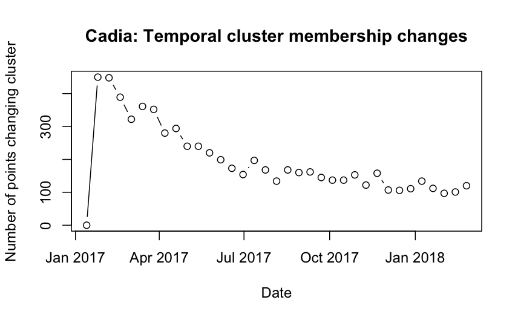

```r
# Plotting the changes
cadia_dates <- as.Date(
  sub("D_", "", iter_dates),
  format = "%Y%m%d")

changes_per_date <- colSums(change_mat)

plot(
  cadia_dates,
  changes_per_date,
  type = "b",
  xlab = "Date",
  ylab = "Number of points changing cluster",
  main = "Cadia: Temporal cluster membership changes")
```

- The resulting plot contains the number of cluster membership changes per date, including only 35 dates, as we cluster the first 10 dates initially.
- Interesting that the general trend of the plot is a decline over time. This may be due to:
  - Earlier cluster comparisons involves less overall observations, so increasing the number of dates may be more influential.
    - For example, increasing from 10 to 11 dates means the new observation is 1/11 of the information going into the second clustering. This is much more influential than going from 40 dates to 41 dates, where the new observation is only 1/41 of the information.
  - Increasing the number of observations may result in the time-series shapes/clusters becoming better established/stabilised.
    - K-means involves calculating the cluster centroids, and a larger total number of observations may better represent the sub-populations of a dataset.

However, the spatial representation of these changes may be more informative than this summary.

We convert the data from wide to long format for convenience when we use ArcGIS:

```r
# convert
cadia_cluster_long <- as.data.frame(cluster_membership_mat)

cadia_cluster_long$PT_ID <- seq_len(nrow(cadia_cluster_long))

cadia_cluster_long <- cadia_cluster_long %>%
  pivot_longer(
    cols = starts_with("cluster_"),
    names_to = "Date",
    values_to = "Cluster"
  )
```

```r
head(cadia_cluster_long)
```

| PT_ID | Date | Cluster |
| --- | --- | --- |
| 1 | cluster_20170113 | 2 |
| 1 | cluster_20170125 | 1 |
| 1 | cluster_20170206 | 1 |
| 1 | cluster_20170218 | 1 |
| 1 | cluster_20170302 | 1 |
| 1 | cluster_20170314 | 1 |

```r
# convert cluster date text to ACTUAL date
cadia_cluster_long$Date <- sub(
  "^cluster_",
  "",
  cadia_cluster_long$Date
)

cadia_cluster_long$Date <- as.Date(
  cadia_cluster_long$Date,
  format = "%Y%m%d"
)
```

```r
str(cadia_cluster_long)
```

```
tibble [437,570 × 3] (S3: tbl_df/tbl/data.frame)
 $ PT_ID  : int [1:437570] 1 1 1 1 1 1 1 1 1 1 ...
 $ Date   : Date[1:437570], format: "2017-01-13" "2017-01-25" "2017-02-06" "2017-02-18" ...
 $ Cluster: int [1:437570] 2 1 1 1 1 1 1 1 2 2 ...
```

We now create a new dataset containing only essential geographical information and cluster change information.

```r
cadia_change_long <- as.data.frame(change_mat)

cadia_change_long$PT_ID <- seq_len(nrow(cadia_change_long))

cadia_change_long <- cadia_change_long %>%
  pivot_longer(
    cols = starts_with("changed_"),
    names_to = "Date",
    values_to = "Changed"
  )

cadia_change_long$Date <- sub(
  "^changed_",
  "",
  cadia_change_long$Date
)

cadia_change_long$Date <- as.Date(
  cadia_change_long$Date,
  format = "%Y%m%d"
)
```

```r
View(cadia_change_long)
```

```r
# combine cluster + change info

cadia_cluster_summary <- cadia_cluster_long %>%
  left_join(
    cadia_change_long,
    by = c("PT_ID", "Date")
  )

head(cadia_cluster_summary)
```

| PT_ID | Date | Cluster | Changed |
| --- | --- | --- | --- |
| 1 | 2017-01-13 | 2 | 0 |
| 1 | 2017-01-25 | 1 | 1 |
| 1 | 2017-02-06 | 1 | 0 |
| 1 | 2017-02-18 | 1 | 0 |
| 1 | 2017-03-02 | 1 | 0 |
| 1 | 2017-03-14 | 1 | 0 |

```r
cadia_data_summary <- data.frame(
  PT_ID = seq_len(nrow(cadia)),
  lon = cadia$lon,
  lat = cadia$lat,
  coherence = cadia$coherence
)
```

```r
# combine geographical info w/ cluster info
cadia_cluster_summary <- cadia_cluster_summary %>%
  left_join(
    cadia_data_summary,
    by = "PT_ID"
  )
```

```r
View(cadia_cluster_summary)
```

```r
# rearrange cols to be similar to original data
cadia_cluster_summary <- cadia_cluster_summary %>%
  select(
    PT_ID,
    coherence,
    lon,
    lat,
    Date,
    Cluster,
    Changed
  )
```

```r
write.csv(
  cadia_cluster_summary,
  "../outputs/cadia_temporal_clust_long.csv",
  row.names = FALSE
)
```

```r
View(cadia_cluster_summary)
```

#### K = 3

```r
set.seed(1234)

k <- 3

cluster_membership_mat_k3 <- matrix(
  NA,
  nrow = n_pts,
  ncol = n_iters
)

# rename the columns to correspond to dates

colnames(cluster_membership_mat_k3) <- paste0(
  "cluster_",
  sub("^D_", "", iter_dates)
)
```

```r
# Kmeans loop

for (i in start_window:n_dates) {
  x <- cadia_D[, 1:i, drop = FALSE]

  # k-means
  km <- kmeans(x, centers = k, nstart = 20)

  # displacement at newest date

  latest_disp <- x[, ncol(x)]

  # median newest displacement for each cluster
  cluster_medians <- tapply(
    latest_disp,
    km$cluster,
    median
  )

  # order clusters from lower to higher median disp
  cluster_order <- order(cluster_medians)

  # replace arbitrary K-means labels w/ ordered labels
  ordered_clusters <- match(
    km$cluster,
    cluster_order
  )

  # store memberships
  iter <- i - start_window + 1

  cluster_membership_mat_k3[, iter] <- ordered_clusters
}
```

```r
# check matrix
apply(cluster_membership_mat_k3, 2, table)
```

```
  cluster_20170113 cluster_20170125 cluster_20170206 cluster_20170218 cluster_20170302 cluster_20170314 cluster_20170326 cluster_20170407 cluster_20170419 cluster_20170501 cluster_20170513 cluster_20170525
1             2406             2482             2574             2704             2772             2846             2833             3006             3109             3140             3184             3189
2             7724             7637             7469             7309             7220             7136             7077             6931             6832             6834             6827             6802
3             2372             2383             2459             2489             2510             2520             2592             2565             2561             2528             2491             2511
  cluster_20170606 cluster_20170618 cluster_20170630 cluster_20170712 cluster_20170724 cluster_20170805 cluster_20170817 cluster_20170829 cluster_20170910 cluster_20170922 cluster_20171004 cluster_20171016
1             3279             3279             3386             3375             3440             3476             3531             3560             3564             3574             3564             3549
2             6751             6776             6703             6700             6659             6617             6587             6587             6569             6579             6571             6570
3             2472             2447             2413             2427             2403             2409             2384             2355             2369             2349             2367             2383
  cluster_20171028 cluster_20171109 cluster_20171121 cluster_20171203 cluster_20171215 cluster_20171227 cluster_20180108 cluster_20180120 cluster_20180201 cluster_20180213 cluster_20180225
1             3616             3576             3634             3641             3671             3655             3648             3631             3656             3686             3668
2             6546             6571             6555             6557             6540             6552             6548             6567             6558             6546             6531
3             2340             2355             2313             2304             2291             2295             2306             2304             2288             2270             2303
```

```r
# k = 3 change matrix

change_mat_k3 <- matrix(
  0,
  nrow = nrow(cluster_membership_mat_k3),
  ncol = ncol(cluster_membership_mat_k3)
)

change_mat_k3[, 2:ncol(change_mat_k3)] <-
  cluster_membership_mat_k3[, 2:ncol(cluster_membership_mat_k3)] !=
  cluster_membership_mat_k3[, 1:(ncol(cluster_membership_mat_k3) - 1)]

change_mat_k3 <- change_mat_k3 * 1

colnames(change_mat_k3) <- paste0(
  "changed_",
  sub("^D_", "", iter_dates)
)
```

```r
colSums(change_mat_k3)
```

```
changed_20170113 changed_20170125 changed_20170206 changed_20170218 changed_20170302 changed_20170314 changed_20170326 changed_20170407 changed_20170419 changed_20170501 changed_20170513 changed_20170525
               0              501              500              470              423              436              417              408              393              336              315              317
changed_20170606 changed_20170618 changed_20170630 changed_20170712 changed_20170724 changed_20170805 changed_20170817 changed_20170829 changed_20170910 changed_20170922 changed_20171004 changed_20171016
             301              261              267              229              265              148              252              218              200              206              210              189
changed_20171028 changed_20171109 changed_20171121 changed_20171203 changed_20171215 changed_20171227 changed_20180108 changed_20180120 changed_20180201 changed_20180213 changed_20180225
             228              161              184              164              147              156              166              149              143              132              143
```

```r
head(change_mat_k3)
```

```
     changed_20170113 changed_20170125 changed_20170206 changed_20170218 changed_20170302 changed_20170314 changed_20170326 changed_20170407 changed_20170419 changed_20170501 changed_20170513 changed_20170525
[1,]                0                0                0                0                0                0                0                0                0                0                0                0
[2,]                0                0                0                0                0                0                0                0                0                0                0                0
[3,]                0                0                0                0                0                0                0                0                0                0                0                0
[4,]                0                0                0                0                0                0                0                0                0                0                0                0
[5,]                0                0                0                0                0                0                0                0                0                0                0                0
[6,]                0                0                0                0                0                0                0                0                0                0                0                0
     changed_20170606 changed_20170618 changed_20170630 changed_20170712 changed_20170724 changed_20170805 changed_20170817 changed_20170829 changed_20170910 changed_20170922 changed_20171004 changed_20171016
[1,]                0                0                0                0                0                0                0                0                0                0                0                0
[2,]                0                0                0                0                0                0                0                0                0                0                0                0
[3,]                0                0                1                1                0                1                1                0                0                0                0                0
[4,]                0                0                0                0                0                0                0                0                0                0                0                0
[5,]                0                0                0                0                0                0                0                0                0                0                0                0
[6,]                0                0                0                0                0                0                0                1                0                0                0                0
     changed_20171028 changed_20171109 changed_20171121 changed_20171203 changed_20171215 changed_20171227 changed_20180108 changed_20180120 changed_20180201 changed_20180213 changed_20180225
[1,]                0                0                0                0                0                0                0                0                0                0                0
[2,]                0                0                0                0                0                0                0                0                0                0                0
[3,]                0                0                0                0                0                1                0                0                0                0                0
[4,]                0                0                0                0                0                0                0                0                0                0                0
[5,]                0                0                0                0                0                0                0                0                0                0                0
[6,]                0                0                0                0                0                0                0                0                0                0                0
```

```r
png(
  "cadia_changes_km2_km3.png",
  width = 3200,
  height = 1800,
  res = 300
)

par(mfrow=c(1,2))

changes_per_date <- colSums(change_mat)

plot(
  cadia_dates,
  changes_per_date,
  type = "b",
  xlab = "Date",
  ylab = "Number of points changing cluster",
  main = "Cadia: Cluster Changes - k = 2")

changes_per_date_k3 <- colSums(change_mat_k3)

plot(
  cadia_dates,
  changes_per_date_k3,
  type = "b",
  xlab = "Date",
  ylab = "Number of points changing cluster",
  main = "Cadia Cluster Changes - k = 3"
)
```

```r
dev.off()
```

```r
# convert to long

cadia_cluster_long_k3 <- as.data.frame(cluster_membership_mat_k3)

cadia_cluster_long_k3$PT_ID <- seq_len(
  nrow(cadia_cluster_long_k3)
)

cadia_cluster_long_k3 <- cadia_cluster_long_k3 %>%
  pivot_longer(
    cols = starts_with("cluster_"),
    names_to = "Date",
    values_to = "Cluster"
  )


# --------

cadia_cluster_long_k3$Date <- sub(
  "^cluster_",
  "",
  cadia_cluster_long_k3$Date
)

cadia_cluster_long_k3$Date <- as.Date(
  cadia_cluster_long_k3$Date,
  format = "%Y%m%d"
)
```

```r
str(cadia_cluster_long_k3)
```

```
tibble [437,570 × 3] (S3: tbl_df/tbl/data.frame)
 $ PT_ID  : int [1:437570] 1 1 1 1 1 1 1 1 1 1 ...
 $ Date   : Date[1:437570], format: "2017-01-13" "2017-01-25" "2017-02-06" "2017-02-18" ...
 $ Cluster: int [1:437570] 2 2 2 2 2 2 2 2 2 2 ...
```

```r
# convert change matrix to long
cadia_change_long_k3 <- as.data.frame(change_mat_k3)

cadia_change_long_k3$PT_ID <- seq_len(
  nrow(cadia_change_long_k3)
)

cadia_change_long_k3 <- cadia_change_long_k3 %>%
  pivot_longer(
    cols = starts_with("changed_"),
    names_to = "Date",
    values_to = "Changed"
  )

cadia_change_long_k3$Date <- sub(
  "^changed_",
  "",
  cadia_change_long_k3$Date
)

cadia_change_long_k3$Date <- as.Date(
  cadia_change_long_k3$Date,
  format = "%Y%m%d"
)
```

```r
# combine matrices
cadia_cluster_summary_k3 <- cadia_cluster_long_k3 %>%
  left_join(
    cadia_change_long_k3,
    by = c("PT_ID", "Date")
  )
```

```r
head(cadia_cluster_summary_k3)
```

| PT_ID | Date | Cluster | Changed |
| --- | --- | --- | --- |
| 1 | 2017-01-13 | 2 | 0 |
| 1 | 2017-01-25 | 2 | 0 |
| 1 | 2017-02-06 | 2 | 0 |
| 1 | 2017-02-18 | 2 | 0 |
| 1 | 2017-03-02 | 2 | 0 |
| 1 | 2017-03-14 | 2 | 0 |

```r
# new dataset combining clusters and changes

cadia_data_summary_k3 <- data.frame(
  PT_ID = seq_len(nrow(cadia)),
  lon = cadia$lon,
  lat = cadia$lat,
  coherence = cadia$coherence
)
```

```r
cadia_cluster_summary_k3 <- cadia_cluster_summary_k3 %>%
  left_join(
    cadia_data_summary_k3,
    by = "PT_ID"
  ) %>%
  select(
    PT_ID,
    coherence,
    lon,
    lat,
    Date,
    Cluster,
    Changed
  )
```

```r
# check
dim(cadia_cluster_summary_k3)
```

```
[1] 437570      7
```

```r
table(cadia_cluster_summary_k3$Cluster)
```

```
     1      2      3
115904 237538  84128
```

```r
table(cadia_cluster_summary_k3$Changed)
```

```
     0      1
428535   9035
```

```r
View(cadia_cluster_summary_k3)
```

```r
# Export

write.csv(
  cadia_cluster_summary_k3,
  "../outputs/cadia_temporal_clust_k3_long.csv",
  row.names = FALSE
)
```

### 2.3 Cumulative displacement tracking for comparison

We can try to create a similar animation as the cluster membership tracking animation, but with just the cumulative displacement over time. It may act as a “baseline” that we can use in overall comparisons. This is straightforward, as the data is already given in such form. Although tracking the velocity through animation was another option, it was difficult to determine the best representation and calculation of velocity (expanding window, rolling window, internal velocity).

The process is just converting the data to long form:

```r
cadia_disp_long <- as.data.frame(cadia_D_mat)

cadia_disp_long$PT_ID <- seq_len(nrow(cadia_disp_long))
```

```r
cadia_disp_long <- cadia_disp_long %>%
  pivot_longer(
    cols = starts_with("D_"),
    names_to = "Date",
    values_to = "Displacement"
  )
```

```r
# convert dates
cadia_disp_long$Date <- sub(
  "^D_",
  "",
  cadia_disp_long$Date
)

cadia_disp_long$Date <- as.Date(
  cadia_disp_long$Date,
  format = "%Y%m%d"
)
```

```r
# add geographical info to new format data

cadia_disp_summary <- data.frame(
  PT_ID = seq_len(nrow(cadia)),
  lon = cadia$lon,
  lat = cadia$lat,
  coherence = cadia$coherence
)

# combine geographical info w/ disp info
cadia_disp_long <- cadia_disp_long %>%
  left_join(
    cadia_disp_summary,
    by = "PT_ID"
  )
```

```r
# rearrange new format data

cadia_disp_long <- cadia_disp_long %>%
  select(
    PT_ID,
    coherence,
    lon,
    lat,
    Date,
    Displacement
  )
```

```r
head(cadia_disp_long)
```

| PT_ID | coherence | lon | lat | Date | Displacement |
| --- | --- | --- | --- | --- | --- |
| 1 | 0.796 | 148.9938 | -33.49118 | 2016-09-27 | 0.0 |
| 1 | 0.796 | 148.9938 | -33.49118 | 2016-10-09 | -0.4 |
| 1 | 0.796 | 148.9938 | -33.49118 | 2016-10-15 | -1.7 |
| 1 | 0.796 | 148.9938 | -33.49118 | 2016-10-21 | 1.9 |
| 1 | 0.796 | 148.9938 | -33.49118 | 2016-11-02 | -0.5 |
| 1 | 0.796 | 148.9938 | -33.49118 | 2016-11-14 | -2.7 |

#### Export the data

```r
write.csv(
  cadia_disp_long,
  "../outputs/cadia_displacement_long.csv",
  row.names = FALSE
)
```

```r
View(cadia_disp_long)
```

## 3. Hierarchical clustering

Same pipeline and processing, except the hierarchical clustering step.

### 3.1 Temporal clustering

#### K = 2

```r
k <- 2

cluster_membership_mat_hc <- matrix(
  NA,
  nrow = n_pts,
  ncol = n_iters
)

colnames(cluster_membership_mat_hc) <- paste0(
  "cluster_",
  sub("^D_", "", iter_dates)
)
```

```r
for (i in start_window:n_dates) {
  x <- cadia_D[, 1:i, drop = FALSE]

  # hierarchical clustering
  x_dist <- dist(x, method = "euclidean")

  hc <- hclust(x_dist, method = "ward.D2")

  # store resulting clusters
  hc_clusters <- cutree(hc, k = k)

  # displacement at newest date

  latest_disp <- x[, ncol(x)]

  # median newest displacement for each cluster
  cluster_medians <- tapply(
    latest_disp,
    hc_clusters,
    median
  )

  # order clusters from lower to higher median disp
  cluster_order <- order(cluster_medians)

  # replace arbitrary K-means labels w/ ordered labels
  ordered_clusters <- match(
    hc_clusters,
    cluster_order
  )

  # store memberships
  iter <- i - start_window + 1

  cluster_membership_mat_hc[, iter] <- ordered_clusters
}
```

```r
# check matrix
apply(cluster_membership_mat_hc, 2, table)
```

```
  cluster_20170113 cluster_20170125 cluster_20170206 cluster_20170218 cluster_20170302 cluster_20170314 cluster_20170326 cluster_20170407 cluster_20170419 cluster_20170501 cluster_20170513 cluster_20170525
1             4065             5851             9219             8769             2926             8138             8218             9399             4627             4621             3519             4141
2             8437             6651             3283             3733             9576             4364             4284             3103             7875             7881             8983             8361
  cluster_20170606 cluster_20170618 cluster_20170630 cluster_20170712 cluster_20170724 cluster_20170805 cluster_20170817 cluster_20170829 cluster_20170910 cluster_20170922 cluster_20171004 cluster_20171016
1             3756             3714             2779             7148             8682             5326             2906             3818             4045             5656             4641             2914
2             8746             8788             9723             5354             3820             7176             9596             8684             8457             6846             7861             9588
  cluster_20171028 cluster_20171109 cluster_20171121 cluster_20171203 cluster_20171215 cluster_20171227 cluster_20180108 cluster_20180120 cluster_20180201 cluster_20180213 cluster_20180225
1             3593             3643             9807             5387             2202             6141             3863             4818             3473             6101             3926
2             8909             8859             2695             7115            10300             6361             8639             7684             9029             6401             8576
```

```r
# hc change matrix
change_mat_hc <- matrix(
  0,
  nrow = nrow(cluster_membership_mat_hc),
  ncol = ncol(cluster_membership_mat_hc)
)

change_mat_hc[, 2:ncol(change_mat_hc)] <-
  cluster_membership_mat_hc[, 2:ncol(cluster_membership_mat_hc)] !=
  cluster_membership_mat_hc[, 1:(ncol(cluster_membership_mat_hc) - 1)]

change_mat_hc <- change_mat_hc * 1

colnames(change_mat_hc) <- paste0(
  "changed_",
  sub("^D_", "", iter_dates)
)
```

```r
# check number of changes
colSums(change_mat_hc)
```

```
changed_20170113 changed_20170125 changed_20170206 changed_20170218 changed_20170302 changed_20170314 changed_20170326 changed_20170407 changed_20170419 changed_20170501 changed_20170513 changed_20170525
               0             2144             3552             1158             5843             5212             1056             1293             4776              966             1310              986
changed_20170606 changed_20170618 changed_20170630 changed_20170712 changed_20170724 changed_20170805 changed_20170817 changed_20170829 changed_20170910 changed_20170922 changed_20171004 changed_20171016
             781              630             1051             4371             1598             3364             2424             1022              479             1657             1125             1737
changed_20171028 changed_20171109 changed_20171121 changed_20171203 changed_20171215 changed_20171227 changed_20180108 changed_20180120 changed_20180201 changed_20180213 changed_20180225
             815              506             6164             4420             3185             3939             2280              973             1413             2628             2177
```

```r
head(change_mat_hc)
```

```
     changed_20170113 changed_20170125 changed_20170206 changed_20170218 changed_20170302 changed_20170314 changed_20170326 changed_20170407 changed_20170419 changed_20170501 changed_20170513 changed_20170525
[1,]                0                0                1                0                1                1                0                0                1                0                0                0
[2,]                0                0                1                0                1                1                0                0                1                0                0                0
[3,]                0                1                0                0                1                1                0                0                0                0                1                1
[4,]                0                0                1                0                1                1                0                0                1                0                0                0
[5,]                0                0                0                0                0                0                0                0                0                0                0                0
[6,]                0                0                0                0                0                0                0                0                0                0                0                0
     changed_20170606 changed_20170618 changed_20170630 changed_20170712 changed_20170724 changed_20170805 changed_20170817 changed_20170829 changed_20170910 changed_20170922 changed_20171004 changed_20171016
[1,]                0                0                0                1                0                1                0                0                0                0                0                0
[2,]                0                0                0                1                0                1                0                0                0                0                0                0
[3,]                0                0                1                1                0                0                1                1                0                0                0                1
[4,]                0                0                0                1                0                0                1                0                0                1                0                1
[5,]                0                0                0                0                0                0                0                0                0                0                0                0
[6,]                0                0                0                0                0                0                0                0                0                0                0                0
     changed_20171028 changed_20171109 changed_20171121 changed_20171203 changed_20171215 changed_20171227 changed_20180108 changed_20180120 changed_20180201 changed_20180213 changed_20180225
[1,]                0                0                1                1                0                0                0                0                0                0                0
[2,]                0                0                1                1                0                0                0                0                0                0                0
[3,]                0                0                1                0                1                1                0                0                1                1                0
[4,]                0                0                1                0                1                1                0                0                1                1                0
[5,]                0                0                0                0                0                0                0                0                0                0                0
[6,]                0                0                1                1                0                0                0                0                0                0                0
```

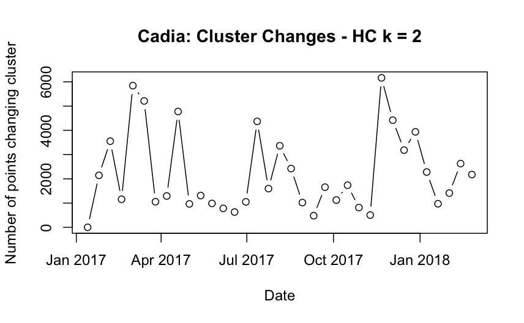

```r
# plot
cadia_dates <- as.Date(
  sub("D_", "", iter_dates),
  format = "%Y%m%d")

changes_per_date_hc <- colSums(change_mat_hc)

plot(
  cadia_dates,
  changes_per_date_hc,
  type = "b",
  xlab = "Date",
  ylab = "Number of points changing cluster",
  main = "Cadia: Cluster Changes - HC k = 2")
```

```r
length(cadia_dates)
```

```
[1] 35
```

```r
length(changes_per_date_hc)
```

```
[1] 35
```

```r
pct_changed_hc <-
  changes_per_date_hc / n_pts * 100
```

```r
pct_changed_k2 <-
  colSums(change_mat) / n_pts * 100
```

```r
pct_changed_k3 <-
  colSums(change_mat_k3) / n_pts * 100
```

```r
# compare changes

png(
  "cadia_changes_km_hc.png",
  width = 2400,
  height = 1800,
  res = 300
)

plot(
  cadia_dates,
  pct_changed_k2,
  type = "l",
  ylim = range(
    pct_changed_k2,
    pct_changed_k3,
    pct_changed_hc
  ),
  xlab = "Date",
  ylab = "Points changing cluster (%)",
  main = "Cadia: Temporal Cluster Changes"
)

lines(
  cadia_dates,
  pct_changed_k3,
  lty = 2
)

lines(
  cadia_dates,
  pct_changed_hc,
  lty = 3
)

legend(
  "topright",
  legend = c(
    "K-means k = 2",
    "K-means k = 3",
    "HC k = 2"
  ),
  lty = c(1, 2, 3)
)

dev.off()
```

```r
mean(pct_changed_k2[-1])
max(pct_changed_k2[-1])

mean(pct_changed_k3[-1])
max(pct_changed_k3[-1])

mean(pct_changed_hc[-1])
max(pct_changed_hc[-1])
```

```r
median(pct_changed_k2[-1])
median(pct_changed_k3[-1])
median(pct_changed_hc[-1])
```

```r
mean(pct_changed_k2[-1])
```

```
[1] 1.611742
```

```r
max(pct_changed_k2[-1])
```

```
[1] 3.599424
```

```r
mean(pct_changed_k3[-1])
```

```
[1] 2.125542
```

```r
max(pct_changed_k3[-1])
```

```
[1] 4.007359
```

```r
mean(pct_changed_hc[-1])
```

```
[1] 18.12298
```

```r
max(pct_changed_hc[-1])
```

```
[1] 49.30411
```

```r
# convert from wide to long - cluster membership
cadia_cluster_long_hc <- as.data.frame(
  cluster_membership_mat_hc
)

cadia_cluster_long_hc$PT_ID <- seq_len(
  nrow(cadia_cluster_long_hc)
)

cadia_cluster_long_hc <- cadia_cluster_long_hc %>%
  pivot_longer(
    cols = starts_with("cluster_"),
    names_to = "Date",
    values_to = "Cluster"
  )

cadia_cluster_long_hc$Date <- sub(
  "^cluster_",
  "",
  cadia_cluster_long_hc$Date
)

cadia_cluster_long_hc$Date <- as.Date(
  cadia_cluster_long_hc$Date,
  format = "%Y%m%d"
)
```

```r
# combine clusters and changes
cadia_cluster_summary_hc <- cadia_cluster_long_hc %>%
  left_join(
    cadia_change_long_hc,
    by = c("PT_ID", "Date")
  )
```

```r
cadia_cluster_summary_hc <- cadia_cluster_summary_hc %>%
  left_join(
    cadia_data_summary,
    by = "PT_ID"
  ) %>%
  select(
    PT_ID,
    coherence,
    lon,
    lat,
    Date,
    Cluster,
    Changed
  )
```

```r
# export
write.csv(
  cadia_cluster_summary_hc,
  "../outputs/cadia_temporal_clust_hc_k2_long.csv",
  row.names = FALSE
)
```

```r
library(mclust)

ari_hc <- numeric(
  ncol(cluster_membership_mat_hc) - 1
)

for (j in 2:ncol(cluster_membership_mat_hc)) {

  ari_hc[j - 1] <- adjustedRandIndex(
    cluster_membership_mat_hc[, j - 1],
    cluster_membership_mat_hc[, j]
  )
}
```

```r
plot(
  cadia_dates[-1],
  ari_hc,
  type = "b",
  xlab = "Date",
  ylab = "Adjusted Rand Index",
  main = "Cadia: HC Consecutive Cluster Stability"
)
```

```r
which(
  colnames(cluster_membership_mat_hc) ==
    "cluster_20170302"
)
```

```r
table(
  cluster_membership_mat_hc[, 4],
  cluster_membership_mat_hc[, 5]
)
```

#### K = 3

```r
set.seed(1234)

k <- 3

cluster_membership_mat_hc_k3 <- matrix(
  NA,
  nrow = n_pts,
  ncol = n_iters
)

# rename the columns to correspond to dates

colnames(cluster_membership_mat_hc_k3) <- paste0(
  "cluster_",
  sub("^D_", "", iter_dates)
)
```

```r
library(mclust)

ari_hc <- numeric(
  ncol(cluster_membership_mat_hc) - 1
)

for (j in 2:ncol(cluster_membership_mat_hc)) {

  ari_hc[j - 1] <- adjustedRandIndex(
    cluster_membership_mat_hc[, j - 1],
    cluster_membership_mat_hc[, j]
  )
}
```

```r
# check matrix
apply(cluster_membership_mat_hc_k3, 2, table)
```

```r
# hc change matrix
change_mat_hc_k3 <- matrix(
  0,
  nrow = nrow(cluster_membership_mat_hc_k3),
  ncol = ncol(cluster_membership_mat_hc_k3)
)

change_mat_hc_k3[, 2:ncol(change_mat_hc_k3)] <-
  cluster_membership_mat_hc_k3[, 2:ncol(cluster_membership_mat_hc_k3)] !=
  cluster_membership_mat_hc_k3[, 1:(ncol(cluster_membership_mat_hc_k3) - 1)]

change_mat_hc_k3 <- change_mat_hc_k3 * 1

colnames(change_mat_hc_k3) <- paste0(
  "changed_",
  sub("^D_", "", iter_dates)
)
```

```r
# check number of changes
colSums(change_mat_hc_k3)
head(change_mat_hc_k3)
```

```r
# plot
png(
  "cadia_changes_hc2_hc3.png",
  width = 3600,
  height = 1800,
  res = 300
)

par(mfrow=c(1,2))

plot(
  cadia_dates,
  changes_per_date_hc,
  type = "b",
  xlab = "Date",
  ylab = "Number of points changing cluster",
  main = "Cadia: Cluster Changes - HC k = 2")

changes_per_date_hc_k3 <- colSums(change_mat_hc_k3)

plot(
  cadia_dates,
  changes_per_date_hc_k3,
  type = "b",
  xlab = "Date",
  ylab = "Number of points changing cluster",
  main = "Cadia: Cluster Changes - HC k = 3")

dev.off()
```

```r
pct_changed_hc_k3 <-
  changes_per_date_hc_k3 / n_pts * 100
```

```r
png(
  "cadia_changes_km_hc.png",
  width = 2400,
  height = 1800,
  res = 300
)

plot(
  cadia_dates,
  pct_changed_k2,
  type = "l",
  ylim = range(
    pct_changed_k2,
    pct_changed_k3,
    pct_changed_hc,
    pct_changed_hc_k3
  ),
  xlab = "Date",
  ylab = "Points changing cluster (%)",
  main = "Cadia: Temporal Cluster Changes"
)

lines(
  cadia_dates,
  pct_changed_k3,
  lty = 2
)

lines(
  cadia_dates,
  pct_changed_hc,
  lty = 3
)

lines(
  cadia_dates,
  pct_changed_hc_k3,
  lty = 4
)

legend(
  "topright",
  legend = c(
    "K-means k = 2",
    "K-means k = 3",
    "HC k = 2",
    "HC k = 3"
  ),
  lty = c(1, 2, 3, 4)
)

dev.off()
```

```r
# plot
png(
  "cadia_changes_hc2_hc3.png",
  width = 3600,
  height = 1800,
  res = 300
)

par(mfrow=c(1,2))

plot(
  cadia_dates,
  changes_per_date_hc,
  type = "b",
  xlab = "Date",
  ylab = "Number of points changing cluster",
  main = "Cadia: Cluster Changes - HC k = 2")

changes_per_date_hc_k3 <- colSums(change_mat_hc_k3)

plot(
  cadia_dates,
  changes_per_date_hc_k3,
  type = "b",
  xlab = "Date",
  ylab = "Number of points changing cluster",
  main = "Cadia: Cluster Changes - HC k = 3")
```

```r
dev.off()
```

```r
# convert from wide to long - changes
cadia_change_long_hc_k3 <- as.data.frame(
  change_mat_hc_k3
)

cadia_change_long_hc_k3$PT_ID <- seq_len(
  nrow(cadia_change_long_hc_k3)
)

cadia_change_long_hc_k3 <- cadia_change_long_hc_k3 %>%
  pivot_longer(
    cols = starts_with("changed_"),
    names_to = "Date",
    values_to = "Changed"
  )

cadia_change_long_hc_k3$Date <- sub(
  "^changed_",
  "",
  cadia_change_long_hc_k3$Date
)

cadia_change_long_hc_k3$Date <- as.Date(
  cadia_change_long_hc_k3$Date,
  format = "%Y%m%d"
)
```

```r
# combine clusters and changes
cadia_cluster_summary_hc_k3 <- cadia_cluster_long_hc_k3 %>%
  left_join(
    cadia_change_long_hc_k3,
    by = c("PT_ID", "Date")
  )
```

```r
cadia_cluster_summary_hc_k3 <- cadia_cluster_summary_hc_k3 %>%
  left_join(
    cadia_data_summary,
    by = "PT_ID"
  ) %>%
  select(
    PT_ID,
    coherence,
    lon,
    lat,
    Date,
    Cluster,
    Changed
  )
```

```r
# export
write.csv(
  cadia_cluster_summary_hc_k3,
  "../outputs/cadia_temporal_clust_hc_k3_long.csv",
  row.names = FALSE
)
```

## 4. Validation Metrics

To evaluate our results quantitatively, as we already have done so spatially using ArcGIS, we can experiment using different metrics.

- For consistency with the previous stages, we will use average silhouette score, but calculating it for each method and k value for each time acquistion.
- Total number of membership changes from each point plotted against time.

### 4.1 Silhouette Score

Same process as previous stages but calculating the average silhouette score at each time acquisition.

#### K-means: K = 2

```r
# reconstruct dist matrix for each window
library(cluster)

cadia_sil_km_k2 <- numeric(n_iters)

for (i in start_window:n_dates) {

  # same expanding window used for clustering
  x <- cadia_D[, 1:i, drop = FALSE]

  # corresponding iteration
  iter <- i - start_window + 1

  # cluster memberships already calculated
  clusters <- cluster_membership_mat[, iter]

  # Euclidean distances for this window
  x_dist <- dist(x, method = "euclidean")

  # silhouette
  sil <- silhouette(clusters, x_dist)

  # average silhouette
  cadia_sil_km_k2[iter] <- mean(sil[, "sil_width"])
}
```

```r
plot(
  cadia_dates,
  cadia_sil_km_k2,
  type = "b",
  ylim = c(0, 1),
  xlab = "Date",
  ylab = "Average silhouette score",
  main = "Cadia: Temporal Silhouette Score - K-means k = 2"
)
```

#### K-means: K = 3

```r
cadia_sil_km_k3 <- numeric(n_iters)

for (i in start_window:n_dates) {

  x <- cadia_D[, 1:i, drop = FALSE]

  iter <- i - start_window + 1

  clusters <- cluster_membership_mat_k3[, iter]

  x_dist <- dist(x, method = "euclidean")

  sil <- silhouette(clusters, x_dist)

  cadia_sil_km_k3[iter] <- mean(sil[, "sil_width"])
}
```

#### HC: K = 2

```r
cadia_sil_hc_k2 <- numeric(n_iters)

for (i in start_window:n_dates) {

  x <- cadia_D[, 1:i, drop = FALSE]

  iter <- i - start_window + 1

  clusters <- cluster_membership_mat_hc[, iter]

  x_dist <- dist(x, method = "euclidean")

  sil <- silhouette(clusters, x_dist)

  cadia_sil_hc_k2[iter] <- mean(sil[, "sil_width"])
}
```

#### HC: K = 3

```r
cadia_sil_hc_k3 <- numeric(n_iters)

for (i in start_window:n_dates) {

  x <- cadia_D[, 1:i, drop = FALSE]

  iter <- i - start_window + 1

  clusters <- cluster_membership_mat_hc_k3[, iter]

  x_dist <- dist(x, method = "euclidean")

  sil <- silhouette(clusters, x_dist)

  cadia_sil_hc_k3[iter] <- mean(sil[, "sil_width"])
}
```

#### Combined Plot

```r
png(
  "cadia_sil_temporal_comparison.png",
  width = 2400,
  height = 1800,
  res = 300
)

plot(
  cadia_dates,
  cadia_sil_km_k2,
  type = "l",
  ylim = range(
    cadia_sil_km_k2,
    cadia_sil_km_k3,
    cadia_sil_hc_k2,
    cadia_sil_hc_k3
  ),
  xlab = "Date",
  ylab = "Average silhouette score",
  main = "Cadia: Temporal Cluster Validation"
)

lines(
  cadia_dates,
  cadia_sil_km_k3,
  lty = 2
)

lines(
  cadia_dates,
  cadia_sil_hc_k2,
  lty = 3
)

lines(
  cadia_dates,
  cadia_sil_hc_k3,
  lty = 4
)

legend(
  "topleft",
  legend = c(
    "K-means k = 2",
    "K-means k = 3",
    "HC k = 2",
    "HC k = 3"
  ),
  lty = c(1, 2, 3, 4)
)

dev.off()
```

# 3.1. Altered Temporal Clustering Workflow

Instead of interpreting the clusters after reordering their respective labels (based on the median of each cluster’s latest cumulative displacement observations), we can implement a fixed-threshold idea. This uses a fixed threshold to compare and assign cluster labels (again, after the actual clustering is completed) instead of recalculating the median each time.

We still compute the median cumulative displacement of the latest acquisition, but instead of relabelling clusters by ordering the medians, we compare it to a threshold to determine whether it is “concerning” or “normal” (which are the two different clusters).

## 3.1.1. K-means clustering

### K = 2

```r
set.seed(1234)

k <- 2
start_window <- 10
# added threshold for median comparison
threshold <- -10

n_pts <- nrow(cadia_D)
n_dates <- ncol(cadia_D)

n_iters <- n_dates - start_window + 1
```

```r
# storing clusters
cluster_membership_mat_v2_k2 <- matrix(
  NA,
  nrow = n_pts,
  ncol = n_iters
)

colnames(cluster_membership_mat_v2_k2) <- paste0(
  "cluster_",
  sub("^D_", "", iter_dates)
)
```

```r
cluster_status_mat_k2 <- matrix(
  NA,
  nrow = n_pts,
  ncol = n_iters
)

# rename the columns to correspond to dates

iter_dates <- colnames(cadia_D)[start_window:n_dates]

colnames(cluster_status_mat_k2) <- paste0(
  "cluster_",
  sub("^D_", "", iter_dates)
)
```

```r
# debugging
cluster_medians_mat <- matrix(
  NA,
  nrow = n_iters,
  ncol = k
)

colnames(cluster_medians_mat) <- c(
  "Lower median",
  "Higher median"
)
```

```r
for (i in start_window:n_dates) {
  x <- cadia_D[, 1:i, drop = FALSE]

  # k-means
  km <- kmeans(x, centers = k, nstart = 20)

  # displacement at newest date

  latest_disp <- x[, ncol(x)]

  iter <- i - start_window + 1

  # raw membership
  cluster_membership_mat_v2_k2[, iter] <- km$cluster

  # median newest displacement for each cluster
  cluster_medians <- tapply(
    latest_disp,
    km$cluster,
    median
  )

  # order clusters from lower to higher median disp - plotting
  ordered_medians <- sort(cluster_medians)

  # store medians
  cluster_medians_mat[iter, ] <- ordered_medians

  # replace arbitrary K-means labels w/ ordered labels
  # USING NEW threshold !!
  cluster_status <- ifelse(
    cluster_medians <= threshold,
    1, #  1 = concerning
    0 #   0 = normal-ish
  )

  # assign each point resulting status
  pt_status <- cluster_status[km$cluster]

  cluster_status_mat_k2[, iter] <- pt_status
}
```

```r
cluster_medians_mat
```

```
      Lower median Higher median
 [1,]        -5.00          2.20
 [2,]        -4.90          2.50
 [3,]        -5.60          2.50
 [4,]        -6.00          2.60
 [5,]        -6.70          1.90
 [6,]        -6.70          2.00
 [7,]        -6.70          2.30
 [8,]        -7.00          2.30
 [9,]        -7.40          2.40
[10,]        -8.30          1.70
[11,]        -8.60          1.70
[12,]        -9.00          1.90
[13,]        -8.90          2.40
[14,]       -10.40          1.10
```

[output cut: 21 more lines]

```r
range(cluster_medians_mat)
```

```
[1] -19.1   3.3
```

```r
apply(cluster_medians_mat, 2, range)
```

```
     Lower median Higher median
[1,]        -19.1           1.1
[2,]         -4.9           3.3
```

```r
par(mar = c(5, 5, 4, 2) + 0.1)

matplot(
  cadia_dates,
  cluster_medians_mat,
  type = "l",
  lty = 1,
  col = c("black", "red"),
  xlab = "Date",
  ylab = "Median cumulative displacement (mm)",
  main = "Cadia: K-means Cluster Median Displacement"
)

abline(
  h = threshold,
  lty = 2,
  col = "black"
)
```

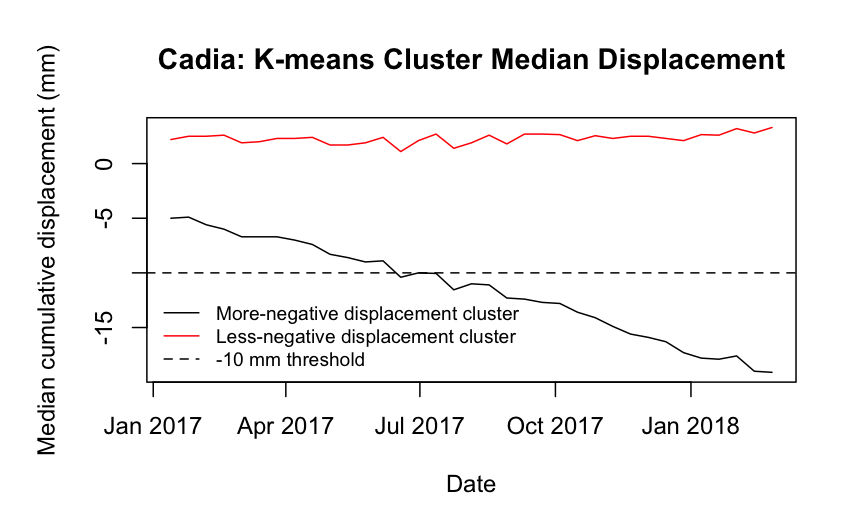

```r
legend(
  "bottomleft",
  legend = c(
    "More-negative displacement cluster",
    "Less-negative displacement cluster",
    paste0(threshold, " mm threshold")
  ),
  col = c("black", "red", "black"),
  lty = c(1, 1, 2),
  bty = "n",
  cex = 0.8
)
```

- The two lines in the above plot represent the median newest-date cumulative displacement of the two groups found by K-means at each expanding window.
- The red line (representing one cluster, after re-labelling based on the threshold rule) stays relatively stable around +1 to +3 mm.
- The black line cluster becomes increasingly negative over time. It begins at roughly -5mm and reaches approximately -10mm by June/July 2017, and finally, reaches approximately -19mm by February 2018 (one month before failure).
- The threshold was chosen based on knowledge of the failure after it occurred.

#### Investigating results

- Examine how many points are “concerning” and if they increase/decrease/stay the same over time.

```r
n_concerning_k2 <- colSums(cluster_status_mat_k2)

percent_concerning_k2 <-
  n_concerning_k2 / n_pts * 100
```

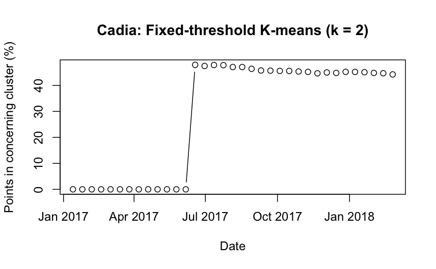

```r
plot(
  cadia_dates,
  percent_concerning_k2,
  type = "b",
  xlab = "Date",
  ylab = "Points in concerning cluster (%)",
  main = "Cadia: Fixed-threshold K-means (k = 2)"
)
```

- The above plot displays the number of points in the “Concerning” cluster (%).
- Before June/July 2017, neither K-means cluster has median displacement of -10mm or less.
- As we apply the threshold to the cluster median (not every separate point), every point belonging to that cluster becomes “concerning” simultaneously.
- The percentage subsequently remains relatively stable at approximately 44–48%.

```r
# converting from wide to long - memberships

membership_long_k2 <- as.data.frame(cluster_membership_mat_v2_k2)

membership_long_k2$PT_ID <- seq_len(nrow(membership_long_k2))

membership_long_k2 <- membership_long_k2 %>%
  pivot_longer(
    cols = starts_with("cluster_"),
    names_to = "Date",
    values_to = "Cluster"
  )

membership_long_k2$Date <- sub(
  "^cluster_",
  "",
  membership_long_k2$Date
)

membership_long_k2$Date <- as.Date(
  membership_long_k2$Date,
  format = "%Y%m%d"
)
```

```r
# converting from wide to long

cadia_status_long_k2 <- as.data.frame(cluster_status_mat_k2)

cadia_status_long_k2$PT_ID <- seq_len(nrow(cadia_status_long_k2))

cadia_status_long_k2 <- cadia_status_long_k2 %>%
  pivot_longer(
    cols = starts_with("cluster_"),
    names_to = "Date",
    values_to = "Status"
  )

cadia_status_long_k2$Date <- sub(
  "^cluster_",
  "",
  cadia_status_long_k2$Date
)

cadia_status_long_k2$Date <- as.Date(
  cadia_status_long_k2$Date,
  format = "%Y%m%d"
)
```

```r
# join membership and status
cadia_temporal_threshold_k2 <- membership_long_k2 %>%
  left_join(
    cadia_status_long_k2,
    by = c("PT_ID", "Date")
  )
```

```r
# reorder cols
cadia_temporal_threshold_k2 <- cadia_temporal_threshold_k2 %>%
  select(
    PT_ID,
    Date,
    Cluster,
    Status,
    lon,
    lat,
    coherence
  )
```

```r
# export
write.csv(
  cadia_temporal_threshold_k2,
  "../outputs/cadia_temporal_threshold_k2_v2.csv",
  row.names = FALSE
)
```

```r
View(cadia_temporal_threshold_k2)
```

```r
sum(cadia$coherence >= 0.70)
```

```
[1] 3383
```

```r
sum(cadia$coherence < 0.70)
```

```
[1] 9119
```

```r
mean(cadia$coherence >= 0.70) * 100
```

```
[1] 27.05967
```

#### Coherence Filtering + Localised TSF Version

- Also adding selection of smaller subset of points (targeted around the dam only).

```r
# read smaller region csv

cadia_tsf_only <- read.csv("../data/cadia_filtered_tsf_only.csv")

head(cadia_tsf_only)
```

|  | velocity | coherence | MuSigma | Hprecision | Vprecision | range_ | azimuth | SubArea_ID | lon | lat | xpos | ypos | zpos | Z | ALOS | ILOS | Hcorrectio | D_20160927 | D_20161009 | D_20161015 | D_20161021 | D_20161102 | D_20161114 | D_20161126 | D_20161208 | D_20161220 | D_20170101 | D_20170113 | D_20170125 | … |
| --- | --- | --- | --- | --- | --- | --- | --- | --- | --- | --- | --- | --- | --- | --- | --- | --- | --- | --- | --- | --- | --- | --- | --- | --- | --- | --- | --- | --- | --- | --- |
| 1 | 1.755 | 0.796 | 2.337 | 4.393 | 1.067 | 339 | 12 | 0 | 148.9938 | -33.49118 | 148.9938 | -33.49118 | 747.8138 | 723.9849 | -74.613 | 35.373 | 2.731 | 0 | -0.4 | -1.7 | 1.9 | -0.5 | -2.7 | 0.1 | -2.0 | 0.3 | 0.4 | -1.2 | -1.3 | … |
| 2 | 2.724 | 0.765 | 2.810 | 4.756 | 1.155 | 340 | 12 | 0 | 148.9938 | -33.49118 | 148.9938 | -33.49118 | 746.7826 | 722.9537 | -74.613 | 35.373 | 1.563 | 0 | 0.1 | -0.3 | 0.1 | 0.7 | -1.2 | 0.5 | 0.5 | 0.2 | 0.3 | -0.1 | -1.4 | … |
| 3 | -12.094 | 0.764 | 2.923 | 4.766 | 1.158 | 343 | 12 | 0 | 148.9935 | -33.49111 | 148.9935 | -33.49111 | 762.4835 | 738.6554 | -74.613 | 35.375 | 16.864 | 0 | -3.5 | 1.0 | -3.6 | -2.7 | -2.0 | -1.7 | -4.0 | -2.5 | -4.1 | -1.6 | -3.5 | … |
| 4 | -12.097 | 0.777 | 2.317 | 4.623 | 1.123 | 344 | 12 | 0 | 148.9935 | -33.49111 | 148.9935 | -33.49111 | 762.4712 | 738.6432 | -74.613 | 35.375 | 16.733 | 0 | -2.2 | 9.3 | -4.8 | -1.8 | -3.0 | 3.1 | 0.0 | 2.0 | 0.0 | 0.9 | -0.4 | … |
| 5 | -25.000 | 0.649 | 2.209 | 6.040 | 1.467 | 346 | 12 | 0 | 148.9935 | -33.49111 | 148.9935 | -33.49111 | 760.4321 | 736.6040 | -74.613 | 35.375 | 14.503 | 0 | -8.1 | -5.3 | -8.2 | -8.4 | -10.0 | -7.7 | -15.7 | -12.0 | -14.9 | -11.5 | -12.8 | … |
| 6 | -16.409 | 0.684 | 1.731 | 5.666 | 1.377 | 349 | 12 | 0 | 148.9933 | -33.49108 | 148.9933 | -33.49108 | 764.4135 | 740.5857 | -74.613 | 35.376 | 18.312 | 0 | 6.8 | 15.9 | 17.8 | 9.7 | 11.4 | 5.2 | 8.9 | 2.3 | 8.6 | 3.3 | 4.8 | … |

```r
dim(cadia_tsf_only)
```

```
[1] 7708   62
```

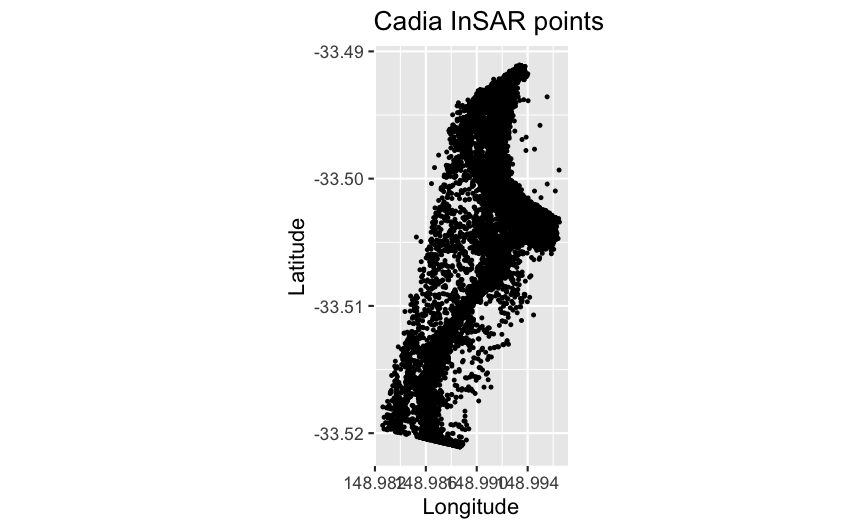

```r
library(ggplot2)

ggplot(cadia, aes(x = lon, y = lat)) +
  geom_point(size = 0.5) +
  coord_fixed() +
  labs(
    title = "Cadia InSAR points",
    x = "Longitude",
    y = "Latitude"
  )
```

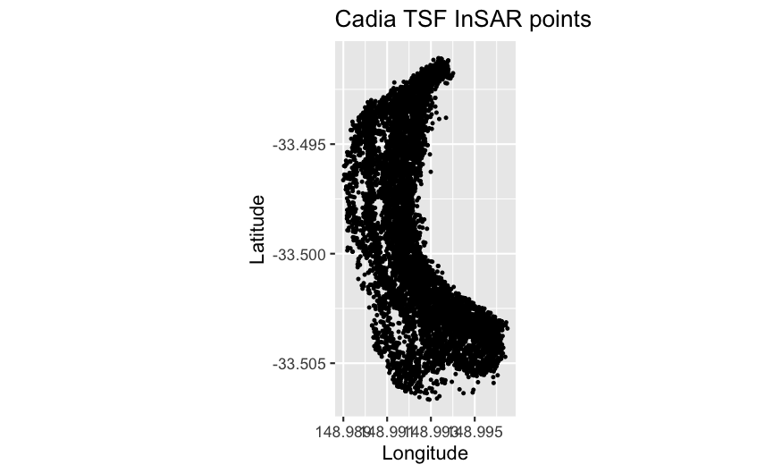

```r
ggplot(cadia_tsf_only, aes(x = lon, y = lat)) +
  geom_point(size = 0.5) +
  coord_fixed() +
  labs(
    title = "Cadia TSF InSAR points",
    x = "Longitude",
    y = "Latitude"
  )
```

```r
coherence_thresholds <- c(0.55, 0.60, 0.70)

for (t in coherence_thresholds) {

  n_keep <- sum(cadia_tsf_only$coherence >= t)
  pct_keep <- mean(cadia_tsf_only$coherence >= t) * 100

  cat(
    "Threshold:", t,
    "- Points:", n_keep,
    "- Percent:", round(pct_keep, 1), "%\n"
  )
}
```

```
Threshold: 0.55 - Points: 5503 - Percent: 71.4 %
Threshold: 0.6 - Points: 4432 - Percent: 57.5 %
Threshold: 0.7 - Points: 2495 - Percent: 32.4 %
```

- Choosing 0.60.
- V2: Choosing 0.70.

**Setup:**

```r
cadia_coherence_threshold <- 0.70

cadia_co_filtered <- cadia_tsf_only %>%
  filter(coherence >= cadia_coherence_threshold)

nrow(cadia_co_filtered)
```

```
[1] 2495
```

```r
# extract displacement cols

d_cols_filtered <- grep(
  "^D_",
  names(cadia_co_filtered),
  value = TRUE
)

cadia_D_filtered <- cadia_co_filtered[, d_cols_filtered]

cadia_D_filtered <- as.matrix(cadia_D_filtered)
```

```r
# remove 0 var dates
cadia_D_filtered_no0 <- remove_zero_var(cadia_D_filtered)
```

```r
# temporal clustering setup

set.seed(1234)

k <- 2
start_window <- 10
threshold <- -10

n_pts_filtered <- nrow(cadia_D_filtered)
n_dates_filtered <- ncol(cadia_D_filtered)

n_iters_filtered <-
  n_dates_filtered - start_window + 1

iter_dates_filtered <-
  colnames(cadia_D_filtered)[
    start_window:n_dates_filtered
  ]
```

```r
# membership matrix
cluster_membership_mat_filtered_k2 <- matrix(
  NA,
  nrow = n_pts_filtered,
  ncol = n_iters_filtered
)

colnames(cluster_membership_mat_filtered_k2) <- paste0(
  "cluster_",
  sub("^D_", "", iter_dates_filtered)
)
```

```r
# status matrix
cluster_status_mat_filtered_k2 <- matrix(
  NA,
  nrow = n_pts_filtered,
  ncol = n_iters_filtered
)

colnames(cluster_status_mat_filtered_k2) <- paste0(
  "cluster_",
  sub("^D_", "", iter_dates_filtered)
)
```

```r
# medians matrix
cluster_medians_mat_filtered_k2 <- matrix(
  NA,
  nrow = n_iters_filtered,
  ncol = k
)

colnames(cluster_medians_mat_filtered_k2) <- c(
  "Lower median",
  "Higher median"
)
```

```r
# temporal clustering loop

for (i in start_window:n_dates_filtered) {

  x <- cadia_D_filtered[
    , 1:i,
    drop = FALSE
  ]

  km <- kmeans(
    x,
    centers = k,
    nstart = 20
  )

  # displacement at newest date
  latest_disp <- x[, ncol(x)]

  # current iteration number
  iter <- i - start_window + 1

  # store raw cluster membership
  cluster_membership_mat_filtered_k2[
    , iter
  ] <- km$cluster

  # median newest displacement
    # for each raw cluster
  cluster_medians <- tapply(
    latest_disp,
    km$cluster,
    median
  )

  # ordered medians only for plotting
  ordered_medians <- sort(
    cluster_medians
  )

  cluster_medians_mat_filtered_k2[
    iter,
  ] <- ordered_medians

  # classify each cluster using THRESHOLD
  cluster_status <- ifelse(
    cluster_medians <= threshold,
    1,   # concerning
    0    # non-concerning
  )

  # each point inherits its cluster's status
  pt_status <- cluster_status[
    km$cluster
  ]

  cluster_status_mat_filtered_k2[
    , iter
  ] <- pt_status
}
```

```r
# calculate concerning pts
n_concerning_filtered_k2 <- colSums(
  cluster_status_mat_filtered_k2
)

percent_concerning_filtered_k2 <-
  n_concerning_filtered_k2 /
  n_pts_filtered * 100
```

```r
# plot % of concerning pts
png(
  "../outputs/cadia_fixed_threshold_km2_concerning_pct.png",
  width = 1000,
  height = 700,
  res = 120
)

plot(
  cadia_dates_filtered,
  percent_concerning_filtered_k2,
  type = "b",
  xlab = "Date",
  ylab = "Points in concerning cluster (%)",
  main = "Cadia: Filtered Fixed-threshold K-means (k = 2)"
)

dev.off()
```

```r
# convert to long - membership
membership_long_filtered_k2 <- as.data.frame(
  cluster_membership_mat_filtered_k2
)

membership_long_filtered_k2$PT_ID <-
  seq_len(
    nrow(membership_long_filtered_k2)
  )

membership_long_filtered_k2 <-
  membership_long_filtered_k2 %>%
  pivot_longer(
    cols = starts_with("cluster_"),
    names_to = "Date",
    values_to = "Cluster"
  )

membership_long_filtered_k2$Date <- sub(
  "^cluster_",
  "",
  membership_long_filtered_k2$Date
)

membership_long_filtered_k2$Date <- as.Date(
  membership_long_filtered_k2$Date,
  format = "%Y%m%d"
)
```

```r
# convert to long - status
status_long_filtered_k2 <- as.data.frame(
  cluster_status_mat_filtered_k2
)

status_long_filtered_k2$PT_ID <-
  seq_len(
    nrow(status_long_filtered_k2)
  )

status_long_filtered_k2 <-
  status_long_filtered_k2 %>%
  pivot_longer(
    cols = starts_with("cluster_"),
    names_to = "Date",
    values_to = "Status"
  )

status_long_filtered_k2$Date <- sub(
  "^cluster_",
  "",
  status_long_filtered_k2$Date
)

status_long_filtered_k2$Date <- as.Date(
  status_long_filtered_k2$Date,
  format = "%Y%m%d"
)
```

```r
# join membership + status
cadia_temporal_threshold_filtered_k2 <-
  membership_long_filtered_k2 %>%
  left_join(
    status_long_filtered_k2,
    by = c("PT_ID", "Date")
  )
```

```r
# add rest of data's info
cadia_temporal_threshold_filtered_k2 <-
  cadia_temporal_threshold_filtered_k2 %>%
  left_join(
    cadia_co_filtered %>%
      mutate(
        PT_ID = row_number()
      ) %>%
      select(
        PT_ID,
        lon,
        lat,
        coherence
      ),
    by = "PT_ID"
  )
```

```r
# reorder new cols
cadia_temporal_threshold_filtered_k2 <-
  cadia_temporal_threshold_filtered_k2 %>%
  select(
    PT_ID,
    Date,
    Cluster,
    Status,
    lon,
    lat,
    coherence
  )
```

```r
# export
write.csv(
  cadia_temporal_threshold_filtered_k2,
  "../outputs/cadia_threshold_tsf_filtered_060_k2.csv",
  row.names = FALSE
)
```

```r
View(cadia_temporal_threshold_filtered_k2)
```

### K = 3

```r
# status matrix
cluster_status_mat_vel_k2 <- matrix(
  NA,
  nrow = n_pts,
  ncol = n_iters
)

colnames(cluster_status_mat_vel_k2) <- paste0(
  "cluster_",
  sub("^D_", "", iter_dates)
)
```

```r
matplot(
  cadia_dates,
  cluster_velocity_mat_k2,
  type = "l",
  lty = 1,
  col = c("black", "red"),
  xlab = "Date",
  ylab = "Median recent LOS velocity (mm/year)",
  main = "Cadia: K-means Recent Cluster Velocity (3-acquisition window)"
)

abline(h = -10, lty = 2)
```

```r
abline(h = -15, lty = 2)
abline(h = -20, lty = 2)
```

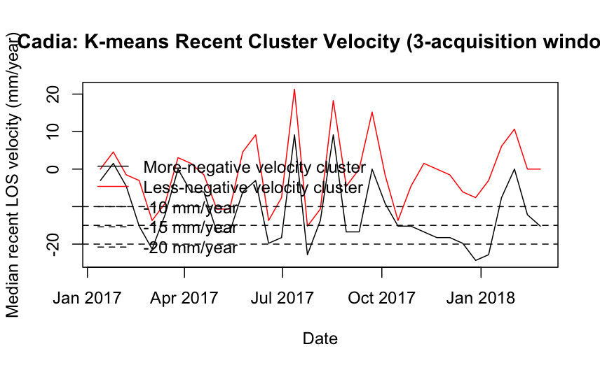

```r
legend(
  "bottomleft",
  legend = c(
    "More-negative velocity cluster",
    "Less-negative velocity cluster",
    "-10 mm/year",
    "-15 mm/year",
    "-20 mm/year"
  ),
  col = c("black", "red", "black", "black", "black"),
  lty = c(1, 1, 2, 2, 2),
  bty = "n"
)
```

```r
cluster_status_mat_k3 <- matrix(
  NA,
  nrow = n_pts,
  ncol = n_iters
)

# rename the columns to correspond to dates

iter_dates <- colnames(cadia_D)[start_window:n_dates]

colnames(cluster_status_mat_k3) <- paste0(
  "cluster_",
  sub("^D_", "", iter_dates)
)
```

```r
# debugging
cluster_medians_mat_k3 <- matrix(
  NA,
  nrow = n_iters,
  ncol = k
)

colnames(cluster_medians_mat_k3) <- c(
  "Lower median",
  "Middle median",
  "Highest median"
)
```

```r
for (i in start_window:n_dates) {

  x <- cadia_D[, 1:i, drop = FALSE]

  # k-means
  km <- kmeans(x, centers = k, nstart = 20)

  # displacement at newest date

  latest_disp <- x[, ncol(x)]

  iter <- i - start_window + 1

  # store raw K-means membership
  cluster_membership_mat_k3[, iter] <- km$cluster

  # median newest displacement for each cluster
  cluster_medians <- tapply(
    latest_disp,
    km$cluster,
    median
  )

  # order clusters from lower to higher median disp
  ordered_medians <- sort(cluster_medians)

  # store medians
  cluster_medians_mat_k3[iter, ] <- ordered_medians

  # replace arbitrary K-means labels w/ ordered labels
  # USING NEW threshold !!
  cluster_status <- ifelse(
    cluster_medians <= threshold,
    1, #  1 = concerning
    0 #   0 = normal-ish
  )

  # assign each point resulting status
  pt_status <- cluster_status[km$cluster]

  cluster_status_mat_k3[, iter] <- pt_status
}
```

- k = 3
- After K-means finds 3 clusters, the algorithm loops to calculate each cluster’s median displacement and assign each cluster a status of 0 (normal) or 1 (concerning).

#### Investigating results

```r
apply(cluster_medians_mat_k3, 2, range)
```

```
     Lower median Middle median Highest median
[1,]       -24.50          -3.4            6.3
[2,]        -9.25          -1.0           15.0
```

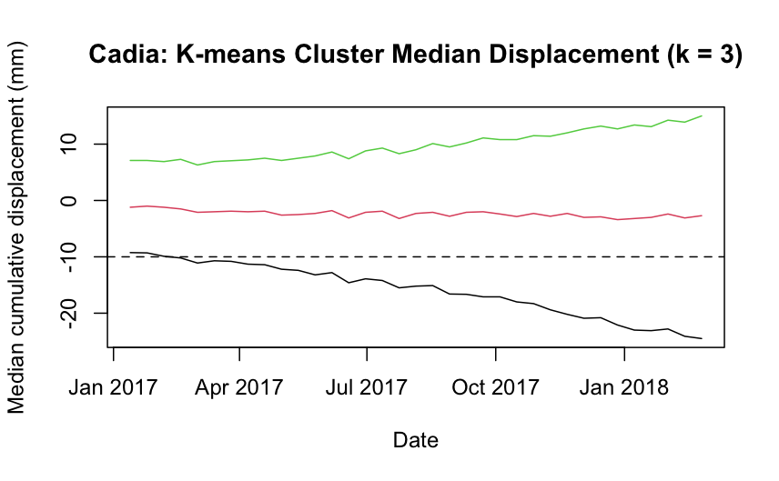

```r
matplot(
  cadia_dates,
  cluster_medians_mat_k3,
  type = "l",
  lty = 1,
  xlab = "Date",
  ylab = "Median cumulative displacement (mm)",
  main = "Cadia: K-means Cluster Median Displacement (k = 3)"
)

abline(
  h = threshold,
  lty = 2
)
```

```r
n_concerning_k3 <- colSums(
  cluster_status_mat_k3
)

percent_concerning_k3 <-
  n_concerning_k3 / n_pts * 100
```

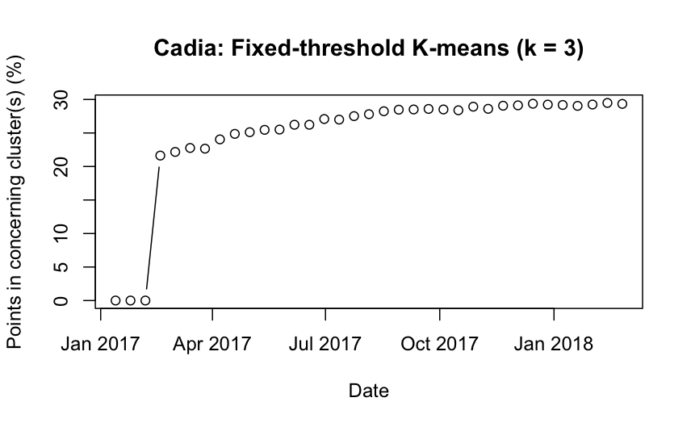

```r
plot(
  cadia_dates,
  percent_concerning_k3,
  type = "b",
  xlab = "Date",
  ylab = "Points in concerning cluster(s) (%)",
  main = "Cadia: Fixed-threshold K-means (k = 3)"
)
```

#### Coherence Filtering

Same data setup as k = 2 version.

```r
# temporal clustering setup
set.seed(1234)

k <- 3

threshold_med_concerning <- -10
threshold_high_concerning <- -20
```

```r
# cluster membership matrix
cluster_membership_mat_filtered_k3 <- matrix(
  NA,
  nrow = n_pts_filtered,
  ncol = n_iters_filtered
)

colnames(cluster_membership_mat_filtered_k3) <- paste0(
  "cluster_",
  sub("^D_", "", iter_dates_filtered)
)
```

```r
# status matrix
cluster_status_mat_filtered_k3_3class <- matrix(
  NA,
  nrow = n_pts_filtered,
  ncol = n_iters_filtered
)

colnames(cluster_status_mat_filtered_k3_3class) <- paste0(
  "cluster_",
  sub("^D_", "", iter_dates_filtered)
)
```

```r
# medians matrix
cluster_medians_mat_filtered_k3 <- matrix(
  NA,
  nrow = n_iters_filtered,
  ncol = 3
)

colnames(cluster_medians_mat_filtered_k3) <- c(
  "Lower median",
  "Middle median",
  "Higher median"
)
```

```r
# temporal clustering loop
for (i in start_window:n_dates_filtered) {

  x <- cadia_D_filtered[, 1:i, drop = FALSE]

  km <- kmeans(
    x,
    centers = k,
    nstart = 20
  )

  # newest cumulative displacement
  latest_disp <- x[, ncol(x)]

  iter <- i - start_window + 1

  # store raw cluster memberships: 1, 2, 3
  cluster_membership_mat_filtered_k3[, iter] <- km$cluster

  # median newest displacement for each raw cluster
  cluster_medians <- tapply(
    latest_disp,
    km$cluster,
    median
  )

  # ordered medians for plotting only
  ordered_medians <- sort(cluster_medians)

  cluster_medians_mat_filtered_k3[iter, ] <-
    ordered_medians

  # classify each cluster into 3 categories
  cluster_status <- ifelse(
    cluster_medians <= threshold_high_concerning,
    2,  # concerning
    ifelse(
      cluster_medians <= threshold_med_concerning,
      1,  # elevated
      0   # lower deformation
    )
  )

  # each point takes its cluster's classification
  pt_status <- cluster_status[km$cluster]

  cluster_status_mat_filtered_k3_3class[, iter] <-
    pt_status
}
```

```r
# looking at 3 cluster medians
matplot(
  cadia_dates_filtered,
  cluster_medians_mat_filtered_k3,
  type = "l",
  lty = 1,
  xlab = "Date",
  ylab = "Median cumulative displacement (mm)",
  main = "Cadia: Filtered K-means Cluster Medians (k = 3)"
)

abline(
  h = threshold_intermediate,
  lty = 2
)
```

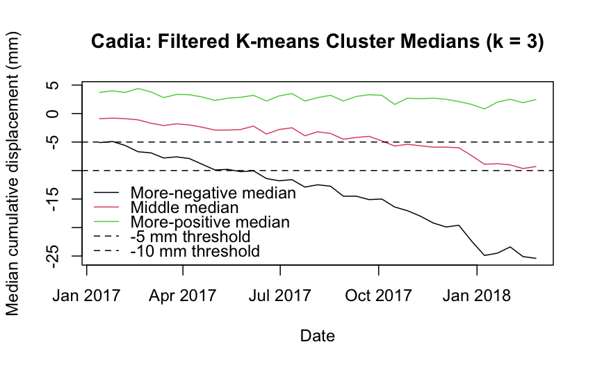

```r
abline(
  h = threshold_concerning,
  lty = 2
)

legend(
  "bottomleft",
  legend = c(
    "More-negative median",
    "Middle median",
    "More-positive median",
    "-5 mm threshold",
    "-10 mm threshold"
  ),
  lty = c(1, 1, 1, 2, 2),
  col = c(1, 2, 3, 1, 1),
  bty = "n"
)
```

```r
# calc % in each category
percent_normal_filtered_k3 <- colMeans(
  cluster_status_mat_filtered_k3_3class == 0
) * 100

percent_intermed_filtered_k3 <- colMeans(
  cluster_status_mat_filtered_k3_3class == 1
) * 100

percent_concerning_filtered_k3 <- colMeans(
  cluster_status_mat_filtered_k3_3class == 2
) * 100

status_percent_filtered_k3 <- cbind(
  Normal = percent_normal_filtered_k3,
  Elevated = percent_intermed_filtered_k3,
  Concerning = percent_concerning_filtered_k3
)
```

```r
# plot ^
png(
  "../outputs/cadia_fixed_km3_diff_clusters_pct.png",
  width = 1000,
  height = 700,
  res = 120
)

matplot(
  cadia_dates_filtered,
  status_percent_filtered_k3,
  type = "l",
  lty = 1,
  xlab = "Date",
  ylab = "Points (%)",
  main = "Cadia: Filtered Three-level K-means Classification (k = 3)"
)

legend(
  "right",
  legend = c(
    "Lower deformation",
    "Elevated deformation",
    "Concerning deformation"
  ),
  lty = 1,
  col = 1:3,
  bty = "n"
)

dev.off()
```

- The abrupt changes in the proportion of points assigned to each status occur because thresholds are applied to cluster medians, meaning all points within a cluster inherit the same status simultaneously.

```r
# convert to long - memberships
membership_long_filtered_k3 <- as.data.frame(
  cluster_membership_mat_filtered_k3
)

membership_long_filtered_k3$PT_ID <- seq_len(
  nrow(membership_long_filtered_k3)
)

membership_long_filtered_k3 <- membership_long_filtered_k3 %>%
  pivot_longer(
    cols = starts_with("cluster_"),
    names_to = "Date",
    values_to = "Cluster"
  )

membership_long_filtered_k3$Date <- sub(
  "^cluster_",
  "",
  membership_long_filtered_k3$Date
)

membership_long_filtered_k3$Date <- as.Date(
  membership_long_filtered_k3$Date,
  format = "%Y%m%d"
)
```

```r
# convert to long - status

status_long_filtered_k3 <- as.data.frame(
  cluster_status_mat_filtered_k3_3class
)

status_long_filtered_k3$PT_ID <- seq_len(
  nrow(status_long_filtered_k3)
)

status_long_filtered_k3 <- status_long_filtered_k3 %>%
  pivot_longer(
    cols = starts_with("cluster_"),
    names_to = "Date",
    values_to = "Status"
  )

status_long_filtered_k3$Date <- sub(
  "^cluster_",
  "",
  status_long_filtered_k3$Date
)

status_long_filtered_k3$Date <- as.Date(
  status_long_filtered_k3$Date,
  format = "%Y%m%d"
)
```

```r
# join
cadia_temporal_threshold_filtered_k3 <-
  membership_long_filtered_k3 %>%
  left_join(
    status_long_filtered_k3,
    by = c("PT_ID", "Date")
  )
```

```r
# add other info
cadia_temporal_threshold_filtered_k3 <-
  cadia_temporal_threshold_filtered_k3 %>%
  left_join(
    cadia_co_filtered %>%
      mutate(PT_ID = row_number()) %>%
      select(
        PT_ID,
        lon,
        lat,
        coherence
      ),
    by = "PT_ID"
  )
```

```r
# reorder info
cadia_temporal_threshold_filtered_k3 <-
  cadia_temporal_threshold_filtered_k3 %>%
  select(
    PT_ID,
    Date,
    Cluster,
    Status,
    lon,
    lat,
    coherence
  )
```

```r
# export
write.csv(
  cadia_temporal_threshold_filtered_k3,
  "../outputs/cadia_threshold_tsf_filtered_060_k3_3class.csv",
  row.names = FALSE
)
```

```r
View(cadia_temporal_threshold_filtered_k3)
```

## 3.1.2 Silhouette Score

We calculate the silhouette score for the filtered data versions.

```r
# expanding-window silhouette: k = 2

n_iters_expand_k2 <- ncol(
  cluster_membership_mat_filtered_k2
)

silhouette_expand_k2 <- numeric(
  n_iters_expand_k2
)

for (iter in 1:n_iters_expand_k2) {

  # expanding window ends at:
  i <- start_window + iter - 1

  x <- cadia_D_filtered[
    , 1:i,
    drop = FALSE
  ]

  clusters <-
    cluster_membership_mat_filtered_k2[, iter]

  sil <- cluster::silhouette(
    clusters,
    dist(x)
  )

  silhouette_expand_k2[iter] <-
    mean(sil[, "sil_width"])
}
```

```r
summary(silhouette_expand_k2)
```

```
     Min.   1st Qu.    Median      Mean   3rd Qu.      Max.
-0.004739  0.014276  0.020462  0.027576  0.030738  0.156246
```

```r
mean(silhouette_expand_k2)
```

```
[1] 0.02757556
```

```r
n_iters_expand_k3 <- ncol(
  cluster_membership_mat_filtered_k3
)

silhouette_expand_k3 <- numeric(
  n_iters_expand_k3
)

for (iter in 1:n_iters_expand_k3) {

  i <- start_window + iter - 1

  x <- cadia_D_filtered[
    , 1:i,
    drop = FALSE
  ]

  clusters <-
    cluster_membership_mat_filtered_k3[, iter]

  sil <- cluster::silhouette(
    clusters,
    dist(x)
  )

  silhouette_expand_k3[iter] <-
    mean(sil[, "sil_width"])
}
```

```r
summary(silhouette_expand_k3)
```

```
   Min. 1st Qu.  Median    Mean 3rd Qu.    Max.
 0.2334  0.2529  0.2724  0.2675  0.2787  0.2957
```

```r
mean(silhouette_expand_k3)
```

```
[1] 0.2674984
```

```r
start_window
```

```
[1] 10
```

```r
ncol(cluster_membership_mat_filtered_k2)
```

```
[1] 35
```

```r
ncol(cluster_membership_mat_filtered_k3)
```

```
[1] 35
```

# 4. Sliding Window Temporal Clustering Workflow

## Median Cumulative Displacement Version

```r
# filtered cadia dataset including 0 baseline
cadia_D_filtered_sliding <- cadia_D_filtered
```

```r
# expanding-window silhouette: k = 2

n_iters_expand_k2 <- ncol(
  cluster_membership_mat_filtered_k2
)

silhouette_expand_k2 <- numeric(
  n_iters_expand_k2
)

for (iter in 1:n_iters_expand_k2) {

  # expanding window ends at:
  i <- start_window + iter - 1

  x <- cadia_D_filtered[
    , 1:i,
    drop = FALSE
  ]

  clusters <-
    cluster_membership_mat_filtered_k2[, iter]

  sil <- cluster::silhouette(
    clusters,
    dist(x)
  )

  silhouette_expand_k2[iter] <-
    mean(sil[, "sil_width"])
}
```

```r
n_iters_expand_k3 <- ncol(
  cluster_membership_mat_filtered_k3
)

silhouette_expand_k3 <- numeric(
  n_iters_expand_k3
)

for (iter in 1:n_iters_expand_k3) {

  i <- start_window + iter - 1

  x <- cadia_D_filtered[
    , 1:i,
    drop = FALSE
  ]

  clusters <-
    cluster_membership_mat_filtered_k3[, iter]

  sil <- cluster::silhouette(
    clusters,
    dist(x)
  )

  silhouette_expand_k3[iter] <-
    mean(sil[, "sil_width"])
}
```

```r
# membership matrix
cluster_membership_mat_sliding_k3 <- matrix(
  NA,
  nrow = n_pts_filtered,
  ncol = n_iters_filtered
)

colnames(cluster_membership_mat_sliding_k3) <- paste0(
  "cluster_",
  sub("^D_", "", iter_dates_filtered)
)
```

```r
# status matrix
cluster_status_mat_sliding_k3 <- matrix(
  NA,
  nrow = n_pts_filtered,
  ncol = n_iters_filtered
)

colnames(cluster_status_mat_sliding_k3) <- paste0(
  "cluster_",
  sub("^D_", "", iter_dates_filtered)
)
```

```r
# medians matrix
cluster_medians_mat_sliding_k3 <- matrix(
  NA,
  nrow = n_iters_filtered,
  ncol = k
)

colnames(cluster_medians_mat_sliding_k3) <- c(
  "Lower median",
  "Middle median",
  "Higher median"
)
```

```r
n_iters_filtered
```

```
[1] 43
```

```r
ncol(cluster_membership_mat_sliding_k2)
```

```
[1] 43
```

```r
length(iter_dates_filtered)
```

```
[1] 43
```

```r
# temporal clustering loop

for (i in window_size:n_dates_filtered) {

  start_idx <- i - window_size + 1

  x <- cadia_D_filtered_sliding[
    , start_idx:i,
    drop = FALSE
  ]

  # reset each pt to 0 at the start of each window
  x <- sweep(
    x,
    1,
    x[, 1],
    FUN = "-"
  )

  km <- kmeans(
    x,
    centers = k,
    nstart = 20
  )

  # displacement at newest date
  latest_disp <- x[, ncol(x)]

  # current iteration number
  iter <- i - window_size + 1

  # store raw cluster membership
  cluster_membership_mat_sliding_k3[
    , iter
  ] <- km$cluster

  # median newest displacement
  # for each raw cluster
  cluster_medians <- tapply(
    latest_disp,
    km$cluster,
    median
  )

  # ordered medians only for plotting
  ordered_medians <- sort(
    cluster_medians
  )

  cluster_medians_mat_sliding_k3[
    iter,
  ] <- ordered_medians

  # classify each raw K-means cluster
  cluster_status <- ifelse(
    cluster_medians <= threshold_2,
    2,
    ifelse(
      cluster_medians <= threshold_1,
      1,
      0
    )
  )

  # each point inherits the status of its cluster
  pt_status <- cluster_status[
    as.character(km$cluster)
  ]

  cluster_status_mat_sliding_k3[
    , iter
  ] <- pt_status

}
```

```r
head(cluster_medians_mat_sliding_k3)
```

```
     Lower median Middle median Higher median
[1,]         -3.0           0.5          5.00
[2,]         -5.1          -0.1          3.10
[3,]         -4.5          -0.7          2.30
[4,]         -3.8          -0.1          5.70
[5,]         -3.8          -0.5          1.90
[6,]         -3.5          -0.1          5.05
```

```r
tail(cluster_medians_mat_sliding_k3)
```

```
      Lower median Middle median Higher median
[38,]        -7.00          -0.9           9.7
[39,]        -8.90          -1.1           9.2
[40,]        -7.40           0.2           7.7
[41,]        -6.50           1.7           9.9
[42,]        -7.15           0.2          10.4
[43,]        -7.70           0.3          10.5
```

```r
summary(cluster_medians_mat_sliding_k3)
```

```
  Lower median    Middle median     Higher median
 Min.   :-8.900   Min.   :-1.2000   Min.   : 1.500
 1st Qu.:-5.100   1st Qu.:-0.7500   1st Qu.: 2.800
 Median :-4.100   Median :-0.2000   Median : 4.000
 Mean   :-4.509   Mean   :-0.2221   Mean   : 5.092
 3rd Qu.:-3.250   3rd Qu.: 0.2000   3rd Qu.: 7.650
 Max.   :-2.100   Max.   : 1.7000   Max.   :10.500
```

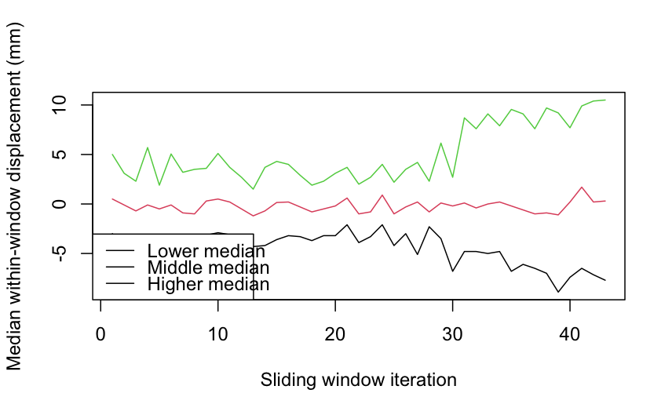

```r
matplot(
  cluster_medians_mat_sliding_k3,
  type = "l",
  lty = 1,
  xlab = "Sliding window iteration",
  ylab = "Median within-window displacement (mm)"
)

legend(
  "bottomleft",
  legend = colnames(cluster_medians_mat_sliding_k3),
  lty = 1
)
```

```r
dim(cluster_membership_mat_sliding_k2)
```

```
[1] 2495   43
```

```r
dim(cluster_status_mat_sliding_k2)
```

```
[1] 2495   43
```

```r
dim(cluster_medians_mat_sliding_k2)
```

```
[1] 43  2
```

#### Median check:

- We check the medians from the initial test to choose an appropriate threshold.

```r
head(cluster_medians_mat_sliding_k2)
```

```
     Lower median Higher median
[1,]         -1.0          1.90
[2,]         -1.8          1.80
[3,]         -1.9          0.30
[4,]         -2.4          1.00
[5,]         -1.5          0.50
[6,]         -1.8          1.25
```

```r
tail(cluster_medians_mat_sliding_k2)
```

```
      Lower median Higher median
[38,]         -2.2           7.2
[39,]         -3.1           3.4
[40,]         -3.0           2.1
[41,]         -3.1           4.2
[42,]         -4.2           1.9
[43,]         -2.1           6.6
```

```r
summary(cluster_medians_mat_sliding_k2)
```

```
  Lower median    Higher median
 Min.   :-5.600   Min.   :0.100
 1st Qu.:-2.400   1st Qu.:0.750
 Median :-1.900   Median :1.400
 Mean   :-2.012   Mean   :1.944
 3rd Qu.:-1.500   3rd Qu.:2.100
 Max.   : 0.000   Max.   :7.200
```

```r
thresholds <- c(-2, -2.5, -3, -3.5, -4, -5)

threshold_check <- data.frame(
  Threshold = thresholds,
  WindowsFlagged = sapply(
    thresholds,
    function(th) {
      sum(lower_med <= th, na.rm = TRUE)
    }
  )
)

threshold_check
```

| Threshold | WindowsFlagged |
| --- | --- |
| -2.0 | 20 |
| -2.5 | 8 |
| -3.0 | 5 |
| -3.5 | 2 |
| -4.0 | 2 |
| -5.0 | 1 |

```r
matplot(
  cluster_medians_mat_sliding_k2,
  type = "l",
  lty = 1,
  xlab = "Sliding window iteration",
  ylab = "Median within-window displacement (mm)"
)

abline(h = -2, lty = 2)
```

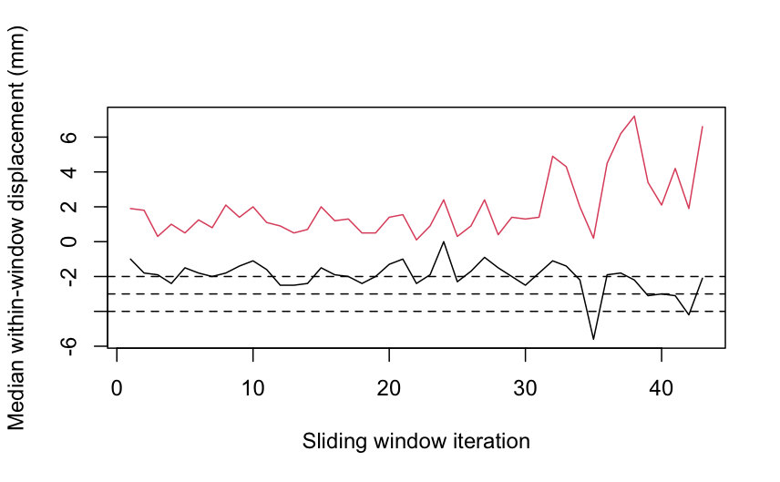

```r
abline(h = -3, lty = 2)
abline(h = -4, lty = 2)
```

```r
table(cluster_status_mat_sliding_k3)
```

```
cluster_status_mat_sliding_k3
    0     1     2
88882 13039  5364
```

```r
status_counts_k3 <- t(
  apply(
    cluster_status_mat_sliding_k3,
    2,
    function(x) table(
      factor(x, levels = c(0, 1, 2))
    )
  )
)

colnames(status_counts_k3) <- c(
  "Status0",
  "Status1",
  "Status2"
)

status_counts_k3
```

```
                 Status0 Status1 Status2
cluster_20161015    1992     503       0
cluster_20161021    2194       0     301
cluster_20161102    2249     246       0
cluster_20161114    1798     697       0
cluster_20161126    2171     324       0
cluster_20161208    1967     528       0
cluster_20161220    2200     295       0
cluster_20170101    2082     413       0
cluster_20170113    1975     520       0
cluster_20170125    2495       0       0
cluster_20170206    2044     451       0
cluster_20170218    1850     645       0
cluster_20170302    2009     486       0
cluster_20170314    2030     465       0
cluster_20170326    1950     545       0
cluster_20170407    2004     491       0
cluster_20170419    1875     620       0
cluster_20170501    1882     613       0
cluster_20170513    1905     590       0
cluster_20170525    2161     334       0
cluster_20170606    2495       0       0
cluster_20170618    1977     518       0
cluster_20170630    1893     602       0
cluster_20170712    2495       0       0
cluster_20170724    2119     376       0
cluster_20170805    2495       0       0
cluster_20170817    2261       0     234
cluster_20170829    2495       0       0
cluster_20170910    1779     716       0
cluster_20170922    2339       0     156
cluster_20171004    2124     371       0
cluster_20171016    2026     469       0
cluster_20171028    1887     608       0
cluster_20171109    1882     613       0
cluster_20171121    2017       0     478
cluster_20171203    1951       0     544
cluster_20171215    2115       0     380
cluster_20171227    1931       0     564
cluster_20180108    2020       0     475
cluster_20180120    2043       0     452
cluster_20180201    1879       0     616
cluster_20180213    1933       0     562
cluster_20180225    1893       0     602
```

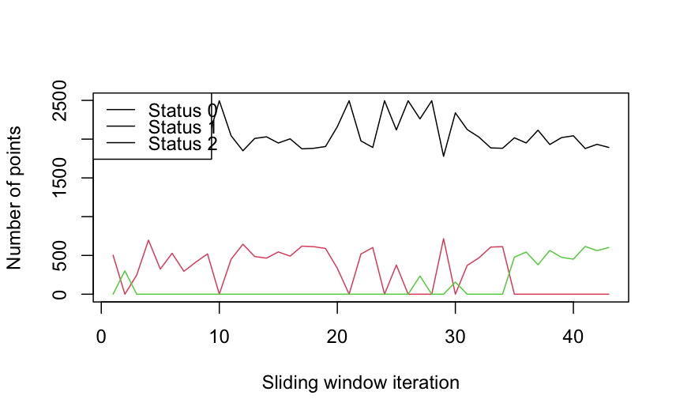

```r
matplot(
  status_counts_k3,
  type = "l",
  lty = 1,
  xlab = "Sliding window iteration",
  ylab = "Number of points"
)

legend(
  "topleft",
  legend = c(
    "Status 0",
    "Status 1",
    "Status 2"
  ),
  lty = 1
)
```

### Exporting k = 3 results:

```r
# cluster membership conversion
cadia_sliding_clusters_df_k3 <-
  as.data.frame(cluster_membership_mat_sliding_k3)

cadia_sliding_clusters_df_k3$PointID <-
  cadia_info_sliding$PointID

cadia_sliding_clusters_long_k3 <-
  cadia_sliding_clusters_df_k3 %>%
  pivot_longer(
    cols = -PointID,
    names_to = "Date",
    values_to = "RawCluster"
  )
```

```r
# status conversion
cadia_sliding_status_df_k3 <-
  as.data.frame(cluster_status_mat_sliding_k3)

cadia_sliding_status_df_k3$PointID <-
  cadia_info_sliding$PointID

cadia_sliding_status_long_k3 <-
  cadia_sliding_status_df_k3 %>%
  pivot_longer(
    cols = -PointID,
    names_to = "Date",
    values_to = "Status"
  )
```

```r
# combine membership + status
cadia_sliding_results_k3 <-
  cadia_sliding_clusters_long_k3 %>%
  left_join(
    cadia_sliding_status_long_k3,
    by = c("PointID", "Date")
  )
```

```r
cadia_sliding_results_k3 <-
  cadia_sliding_results_k3 %>%
  mutate(
    Date = sub("^cluster_", "", Date),
    Date = as.Date(Date, format = "%Y%m%d")
  )
```

```r
# join other data
cadia_sliding_results_k3 <-
  cadia_sliding_results_k3 %>%
  left_join(
    cadia_info_sliding,
    by = "PointID"
  )
```

```r
names(cadia_sliding_results_k3)
```

```
[1] "PointID"    "Date"       "RawCluster" "Status"     "lon"        "lat"        "coherence"
```

```r
head(cadia_sliding_results_k3)
```

| PointID | Date | RawCluster | Status | lon | lat | coherence |
| --- | --- | --- | --- | --- | --- | --- |
| 1 | 2016-10-15 | 1 | 0 | 148.9938 | -33.49118 | 0.796 |
| 1 | 2016-10-21 | 1 | 0 | 148.9938 | -33.49118 | 0.796 |
| 1 | 2016-11-02 | 3 | 0 | 148.9938 | -33.49118 | 0.796 |
| 1 | 2016-11-14 | 3 | 1 | 148.9938 | -33.49118 | 0.796 |
| 1 | 2016-11-26 | 2 | 0 | 148.9938 | -33.49118 | 0.796 |
| 1 | 2016-12-08 | 1 | 0 | 148.9938 | -33.49118 | 0.796 |

```r
# export
write.csv(
  cadia_sliding_results_k3,
  "../outputs/cadia_sliding_k3_w3_thresholds3_5.csv",
  row.names = FALSE
)
```

#### Results check:

```r
# join other data
cadia_sliding_results_k3 <-
  cadia_sliding_results_k3 %>%
  left_join(
    cadia_info_sliding,
    by = "PointID"
  )
```

```r
# status conversion
cadia_sliding_status_df_k3 <-
  as.data.frame(cluster_status_mat_sliding_k3)

cadia_sliding_status_df_k3$PointID <-
  cadia_info_sliding$PointID

cadia_sliding_status_long_k3 <-
  cadia_sliding_status_df_k3 %>%
  pivot_longer(
    cols = -PointID,
    names_to = "Date",
    values_to = "Status"
  )
```

```r
# check matrix
table(cluster_status_mat_sliding_k2, useNA = "ifany")
```

```
cluster_status_mat_sliding_k2
    0     1
98333  8952
```

### Converting and exporting results:

- From wide to long.

```r
cadia_co_filtered <- cadia_co_filtered %>%
  mutate(PointID = row_number())
```

```r
cadia_info_sliding <- cadia_co_filtered %>%
  select(
    PointID,
    lon,
    lat,
    coherence
  )

cadia_D_filtered_sliding <- cadia_co_filtered %>%
  select(starts_with("D_"))
```

```r
nrow(cadia_D_filtered)
```

```
[1] 2495
```

```r
nrow(cadia_D_filtered_sliding)
```

```
[1] 2495
```

```r
# convert clusters
cadia_sliding_clusters_df <- as.data.frame(
  cluster_membership_mat_sliding_k2
)

cadia_sliding_clusters_df$PointID <- cadia_info_sliding$PointID

cadia_sliding_clusters_long <- cadia_sliding_clusters_df %>%
  pivot_longer(
    cols = -PointID,
    names_to = "Date",
    values_to = "RawCluster"
  )
```

```r
# convert status
cadia_sliding_status_df <- as.data.frame(
  cluster_status_mat_sliding_k2
)

cadia_sliding_status_df$PointID <- cadia_info_sliding$PointID

cadia_sliding_status_long <- cadia_sliding_status_df %>%
  pivot_longer(
    cols = -PointID,
    names_to = "Date",
    values_to = "Status"
  )
```

```r
cadia_sliding_results <- cadia_sliding_clusters_long %>%
  left_join(
    cadia_sliding_status_long,
    by = c("PointID", "Date")
  )
```

```r
# convert dates
cadia_sliding_results <- cadia_sliding_results %>%
  mutate(
    Date = sub("^cluster_", "", Date),
    Date = as.Date(Date, format = "%Y%m%d")
  )
```

```r
head(cadia_sliding_results$Date)
```

```
[1] "2016-10-15" "2016-10-21" "2016-11-02" "2016-11-14" "2016-11-26" "2016-12-08"
```

```r
str(cadia_sliding_results$Date)
```

```
 Date[1:107285], format: "2016-10-15" "2016-10-21" "2016-11-02" "2016-11-14" "2016-11-26" "2016-12-08" "2016-12-20" "2017-01-01" ...
```

```r
cadia_sliding_results <- cadia_sliding_results %>%
  left_join(
    cadia_info_sliding,
    by = "PointID"
  )
```

```r
names(cadia_sliding_results)
```

```
[1] "PointID"    "Date"       "RawCluster" "Status"     "lon"        "lat"        "coherence"
```

```r
write.csv(
  cadia_sliding_results,
  "../outputs/cadia_sliding_k2_w3_threshold2.5.csv",
  row.names = FALSE
)
```

## Median Velocity Version

### K = 2

```r
# setup
set.seed(1234)

k <- 2
window_size <- 3

n_pts_filtered <- nrow(cadia_D_filtered_sliding)
n_dates_filtered <- ncol(cadia_D_filtered_sliding)

n_iters_filtered <-
  n_dates_filtered - window_size + 1

iter_dates_filtered <-
  colnames(cadia_D_filtered_sliding)[
    window_size:n_dates_filtered
  ]
```

```r
cadia_all_dates <- as.Date(
  sub("^D_", "", colnames(cadia_D_filtered_sliding)),
  format = "%Y%m%d"
)
```

```r
head(cadia_all_dates)
```

```
[1] "2016-09-27" "2016-10-09" "2016-10-15" "2016-10-21" "2016-11-02" "2016-11-14"
```

```r
diff(cadia_all_dates)
```

```
Time differences in days
 [1] 12  6  6 12 12 12 12 12 12 12 12 12 12 12 12 12 12 12 12 12 12 12 12 12 12 12 12 12 12 12 12 12 12 12 12 12 12 12
[39] 12 12 12 12 12 12
```

```r
# membership matrice
cluster_membership_mat_velocity_k2 <- matrix(
  NA,
  nrow = n_pts_filtered,
  ncol = n_iters_filtered
)

colnames(cluster_membership_mat_velocity_k2) <- paste0(
  "cluster_",
  sub("^D_", "", iter_dates_filtered)
)
```

```r
cluster_status_mat_velocity_k2 <- matrix(
  NA,
  nrow = n_pts_filtered,
  ncol = n_iters_filtered
)

colnames(cluster_status_mat_velocity_k2) <-
  colnames(cluster_membership_mat_velocity_k2)
```

```r
# median matrix
cluster_velocity_mat_k2 <- matrix(
  NA,
  nrow = n_iters_filtered,
  ncol = k
)

colnames(cluster_velocity_mat_k2) <- c(
  "Lower velocity",
  "Higher velocity"
)
```

```r
# temporal clustering loop - velocity version

for (i in window_size:n_dates_filtered) {

  start_idx <- i - window_size + 1

  # current 3-date displacement window
  x <- cadia_D_filtered_sliding[
    , start_idx:i,
    drop = FALSE
  ]

  # reset each point to 0 at start of window
  x <- sweep(
    x,
    1,
    x[, 1],
    FUN = "-"
  )

  # dates in current window
  window_dates <- cadia_all_dates[start_idx:i]

  # time from start of window in days
  time_days <- as.numeric(
    window_dates - window_dates[1]
  )

  # K-means on displacement trajectories
  km <- kmeans(
    x,
    centers = k,
    nstart = 20
  )

  # iteration number
  iter <- i - window_size + 1

  # store raw cluster membership
  cluster_membership_mat_velocity_k2[
    , iter
  ] <- km$cluster

  # velocity for each individual point
  point_velocity <- apply(
    x,
    1,
    function(y) {
      coef(lm(y ~ time_days))[2]
    }
  )

  # mm/day -> mm/year
  point_velocity <- point_velocity * 365.25

  # median velocity for each raw K-means cluster
  cluster_velocities <- tapply(
    point_velocity,
    km$cluster,
    median
  )

  # ordered values just for plotting/inspection
  ordered_velocities <- sort(
    cluster_velocities
  )

  cluster_velocity_mat_k2[
    iter,
  ] <- ordered_velocities

  # classify each K-means cluster using fixed velocity threshold
  cluster_status <- ifelse(
    cluster_velocities <= velocity_threshold,
    1,   # concerning negative velocity
    0    # non-concerning
  )

  # every point inherits the status of its K-means cluster
  pt_status <- cluster_status[
    as.character(km$cluster)
  ]

  # store point status
  cluster_status_mat_velocity_k2[
    , iter
  ] <- pt_status
}
```

Inspect velocity results:

```r
head(cluster_velocity_mat_k2)
```

```
     Lower velocity Higher velocity
[1,]      -20.87143       42.177679
[2,]      -54.78750       54.787500
[3,]      -31.52455       -1.304464
[4,]      -36.52500       15.218750
[5,]      -22.82813        7.609375
[6,]      -27.39375       19.023438
```

```r
tail(cluster_velocity_mat_k2)
```

```
      Lower velocity Higher velocity
[38,]      -33.48125       109.57500
[39,]      -47.17813        51.74375
[40,]      -45.65625        31.95938
[41,]      -47.17812        63.91875
[42,]      -63.91875        28.91563
[43,]      -31.95938       100.44375
```

```r
summary(cluster_velocity_mat_k2)
```

```
 Lower velocity   Higher velocity
 Min.   :-85.22   Min.   : -1.304
 1st Qu.:-36.52   1st Qu.: 12.936
 Median :-30.44   Median : 21.306
 Mean   :-31.44   Mean   : 30.432
 3rd Qu.:-22.83   3rd Qu.: 36.525
 Max.   :  0.00   Max.   :109.575
```

```r
matplot(
  cluster_velocity_mat_k2,
  type = "l",
  lty = 1,
  xlab = "Sliding window iteration",
  ylab = "Median LOS velocity (mm/year)"
)

abline(h = 0, lty = 2)
```

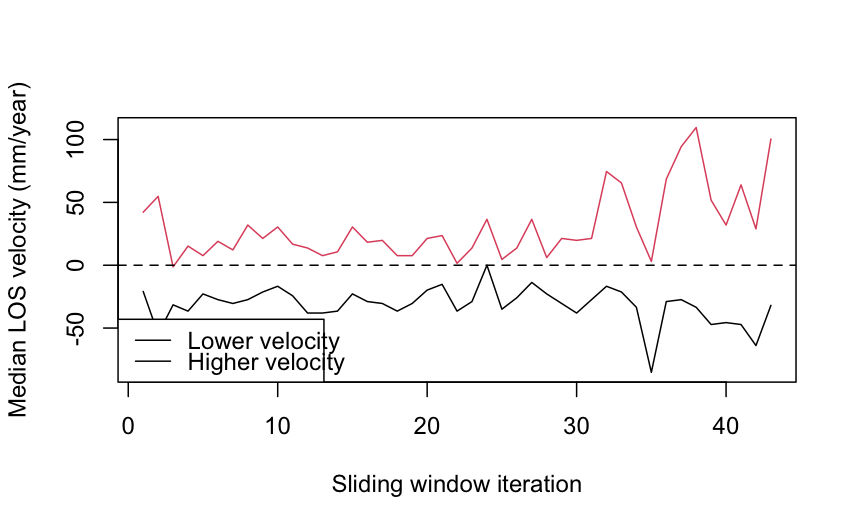

```r
legend(
  "bottomleft",
  legend = colnames(cluster_velocity_mat_k2),
  lty = 1
)
```

```r
table(cluster_status_mat_velocity_k2)
```

```
cluster_status_mat_velocity_k2
    0     1
66836 40449
```

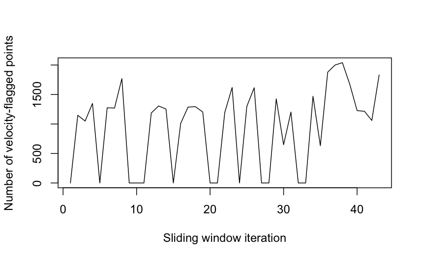

```r
flagged_velocity <- colSums(
  cluster_status_mat_velocity_k2 == 1,
  na.rm = TRUE
)

plot(
  flagged_velocity,
  type = "l",
  xlab = "Sliding window iteration",
  ylab = "Number of velocity-flagged points"
)
```

```r
velocity_flag_check <- data.frame(
  Date = iter_dates_filtered,
  LowerVelocity = cluster_velocity_mat_k2[, 1],
  HigherVelocity = cluster_velocity_mat_k2[, 2],
  FlaggedPoints = flagged_velocity
)

velocity_flag_check
```

|  | Date | LowerVelocity | HigherVelocity | FlaggedPoints |
| --- | --- | --- | --- | --- |
| cluster_20161015 | D_20161015 | -2.087143e+01 | 42.177679 | 0 |
| cluster_20161021 | D_20161021 | -5.478750e+01 | 54.787500 | 1148 |
| cluster_20161102 | D_20161102 | -3.152455e+01 | -1.304464 | 1050 |
| cluster_20161114 | D_20161114 | -3.652500e+01 | 15.218750 | 1349 |
| cluster_20161126 | D_20161126 | -2.282813e+01 | 7.609375 | 0 |
| cluster_20161208 | D_20161208 | -2.739375e+01 | 19.023438 | 1275 |
| cluster_20161220 | D_20161220 | -3.043750e+01 | 12.175000 | 1271 |
| cluster_20170101 | D_20170101 | -2.739375e+01 | 31.959375 | 1771 |
| cluster_20170113 | D_20170113 | -2.130625e+01 | 21.306250 | 0 |
| cluster_20170125 | D_20170125 | -1.674063e+01 | 30.437500 | 0 |

[output cut: 33 more lines]

```r
dim(cluster_membership_mat_velocity_k2)
```

```
[1] 2495   43
```

```r
dim(cluster_status_mat_velocity_k2)
```

```
[1] 2495   43
```

```r
table(cluster_status_mat_velocity_k2)
```

```
cluster_status_mat_velocity_k2
    0     1
66836 40449
```

```r
head(colnames(cluster_status_mat_velocity_k2))
```

```
[1] "cluster_20161015" "cluster_20161021" "cluster_20161102" "cluster_20161114" "cluster_20161126" "cluster_20161208"
```

```r
head(colnames(cluster_membership_mat_velocity_k2))
```

```
[1] "cluster_20161015" "cluster_20161021" "cluster_20161102" "cluster_20161114" "cluster_20161126" "cluster_20161208"
```

## Exporting the results:

```r
cadia_info_velocity <- cadia_co_filtered %>%
  select(
    PointID,
    lon,
    lat,
    coherence
  )
```

```r
nrow(cadia_info_velocity)
```

```
[1] 2495
```

```r
nrow(cluster_membership_mat_velocity_k2)
```

```
[1] 2495
```

```r
# convert clusters
cadia_velocity_clusters_df <-
  as.data.frame(cluster_membership_mat_velocity_k2)

cadia_velocity_clusters_df$PointID <-
  cadia_info_velocity$PointID
```

```r
cadia_velocity_clusters_long <-
  cadia_velocity_clusters_df %>%
  pivot_longer(
    cols = -PointID,
    names_to = "Date",
    values_to = "RawCluster"
  )
```

```r
# convert status
cadia_velocity_status_df <-
  as.data.frame(cluster_status_mat_velocity_k2)

cadia_velocity_status_df$PointID <-
  cadia_info_velocity$PointID
```

```r
cadia_velocity_status_long <-
  cadia_velocity_status_df %>%
  pivot_longer(
    cols = -PointID,
    names_to = "Date",
    values_to = "Status"
  )
```

```r
# combine clusters and status
cadia_velocity_results <-
  cadia_velocity_clusters_long %>%
  left_join(
    cadia_velocity_status_long,
    by = c("PointID", "Date")
  )
```

```r
head(cadia_velocity_results)
```

| PointID | Date | RawCluster | Status |
| --- | --- | --- | --- |
| 1 | cluster_20161015 | 1 | 0 |
| 1 | cluster_20161021 | 1 | 0 |
| 1 | cluster_20161102 | 1 | 0 |
| 1 | cluster_20161114 | 2 | 1 |
| 1 | cluster_20161126 | 2 | 0 |
| 1 | cluster_20161208 | 2 | 0 |

```r
names(cadia_velocity_results)
```

```
[1] "PointID"    "Date"       "RawCluster" "Status"
```

```r
# convert the dates
cadia_velocity_results <-
  cadia_velocity_results %>%
  mutate(
    Date = sub("^cluster_", "", Date),
    Date = as.Date(
      Date,
      format = "%Y%m%d"
    )
  )
```

```r
head(cadia_velocity_results$Date)
```

```
[1] "2016-10-15" "2016-10-21" "2016-11-02" "2016-11-14" "2016-11-26" "2016-12-08"
```

```r
str(cadia_velocity_results$Date)
```

```
 Date[1:107285], format: "2016-10-15" "2016-10-21" "2016-11-02" "2016-11-14" "2016-11-26" "2016-12-08" "2016-12-20" "2017-01-01" ...
```

```r
# join other info
cadia_velocity_results <-
  cadia_velocity_results %>%
  left_join(
    cadia_info_velocity,
    by = "PointID"
  )
```

```r
names(cadia_velocity_results)
```

```
[1] "PointID"    "Date"       "RawCluster" "Status"     "lon"        "lat"        "coherence"
```

```r
head(cadia_velocity_results)
```

| PointID | Date | RawCluster | Status | lon | lat | coherence |
| --- | --- | --- | --- | --- | --- | --- |
| 1 | 2016-10-15 | 1 | 0 | 148.9938 | -33.49118 | 0.796 |
| 1 | 2016-10-21 | 1 | 0 | 148.9938 | -33.49118 | 0.796 |
| 1 | 2016-11-02 | 1 | 0 | 148.9938 | -33.49118 | 0.796 |
| 1 | 2016-11-14 | 2 | 1 | 148.9938 | -33.49118 | 0.796 |
| 1 | 2016-11-26 | 2 | 0 | 148.9938 | -33.49118 | 0.796 |
| 1 | 2016-12-08 | 2 | 0 | 148.9938 | -33.49118 | 0.796 |

```r
summary(cadia_velocity_results$Status)
```

```
   Min. 1st Qu.  Median    Mean 3rd Qu.    Max.
  0.000   0.000   0.000   0.377   1.000   1.000
```

```r
length(unique(cadia_velocity_results$PointID))
```

```
[1] 2495
```

```r
length(unique(cadia_velocity_results$Date))
```

```
[1] 43
```

```r
table(cadia_velocity_results$Status)
```

```
    0     1
66836 40449
```

```r
write.csv(
  cadia_velocity_results,
  "../outputs/cadia_sliding_velocity_k2_w3_threshold25.csv",
  row.names = FALSE
)
```

### K = 3

```r
set.seed(1234)

k <- 3
window_size <- 3
threshold_1 <- -25
threshold_2 <- -75

n_pts_filtered <- nrow(cadia_D_filtered_sliding)
n_dates_filtered <- ncol(cadia_D_filtered_sliding)

n_iters_filtered <-
  n_dates_filtered - window_size + 1

iter_dates_filtered <-
  colnames(cadia_D_filtered_sliding)[
    window_size:n_dates_filtered
  ]

cadia_all_dates <- as.Date(
  sub("^D_", "", colnames(cadia_D_filtered_sliding)),
  format = "%Y%m%d"
)
```

```r
cluster_membership_mat_velocity_k3 <- matrix(
  NA,
  nrow = n_pts_filtered,
  ncol = n_iters_filtered
)

colnames(cluster_membership_mat_velocity_k3) <- paste0(
  "cluster_",
  sub("^D_", "", iter_dates_filtered)
)
```

```r
cluster_status_mat_velocity_k3 <- matrix(
  NA,
  nrow = n_pts_filtered,
  ncol = n_iters_filtered
)

colnames(cluster_status_mat_velocity_k3) <-
  colnames(cluster_membership_mat_velocity_k3)
```

```r
cluster_velocity_mat_k3 <- matrix(
  NA,
  nrow = n_iters_filtered,
  ncol = k
)

colnames(cluster_velocity_mat_k3) <- c(
  "Lower velocity",
  "Middle velocity",
  "Higher velocity"
)
```

#### Loop

```r
for (i in window_size:n_dates_filtered) {

  start_idx <- i - window_size + 1

  # extract current 3-date window
  x <- cadia_D_filtered_sliding[
    , start_idx:i,
    drop = FALSE
  ]

  # reset each point to 0 at start of window
  x <- sweep(
    x,
    1,
    x[, 1],
    FUN = "-"
  )

  # dates for current window
  window_dates <- cadia_all_dates[start_idx:i]

  # time in days from start of window
  time_days <- as.numeric(
    window_dates - window_dates[1]
  )

  # K-means on rebased displacement
  km <- kmeans(
    x,
    centers = k,
    nstart = 20
  )

  iter <- i - window_size + 1

  # store RAW K-means membership
  cluster_membership_mat_velocity_k3[
    , iter
  ] <- km$cluster

  # velocity of each individual point
  point_velocity <- apply(
    x,
    1,
    function(y) {
      coef(lm(y ~ time_days))[2]
    }
  )

  # mm/day -> mm/year
  point_velocity <- point_velocity * 365.25

  # median velocity of each raw K-means cluster
  cluster_velocities <- tapply(
    point_velocity,
    km$cluster,
    median
  )

  # sort ONLY for inspection
  ordered_velocities <- sort(
    cluster_velocities
  )

  cluster_velocity_mat_k3[
    iter,
  ] <- ordered_velocities

  # classify raw clusters by median velocity
  cluster_status <- ifelse(
    cluster_velocities <= threshold_2,
    2,
    ifelse(
      cluster_velocities <= threshold_1,
      1,
      0
    )
  )

  # each point inherits its cluster's status
  pt_status <- cluster_status[
    as.character(km$cluster)
  ]

cluster_status_mat_velocity_k3[
  , iter
] <- pt_status
}
```

```r
head(cluster_velocity_mat_k3)
```

```
     Lower velocity Middle velocity Higher velocity
[1,]      -64.78839        9.566071       109.57500
[2,]     -155.23125       -3.043750        94.35625
[3,]      -63.48393      -14.783929        30.87232
[4,]      -57.83125       -1.521875        88.26875
[5,]      -54.78750       -7.609375        35.00312
[6,]      -53.26562       -1.521875        76.85469
```

```r
tail(cluster_velocity_mat_k3)
```

```
      Lower velocity Middle velocity Higher velocity
[38,]     -106.53125      -13.696875        147.6219
[39,]     -135.44688      -16.740625        140.0125
[40,]     -112.61875        3.043750        117.1844
[41,]      -98.92188       25.871875        150.6656
[42,]     -108.81406        3.043750        158.2750
[43,]     -117.18438        4.565625        159.7969
```

```r
summary(cluster_velocity_mat_k3)
```

```
 Lower velocity    Middle velocity   Higher velocity
 Min.   :-155.23   Min.   :-18.262   Min.   : 22.83
 1st Qu.: -85.22   1st Qu.:-12.175   1st Qu.: 42.61
 Median : -63.48   Median : -3.044   Median : 60.88
 Mean   : -70.71   Mean   : -3.501   Mean   : 79.34
 3rd Qu.: -50.22   3rd Qu.:  3.044   3rd Qu.:116.42
 Max.   : -31.96   Max.   : 25.872   Max.   :159.80
```

```r
matplot(
  cluster_velocity_mat_k3,
  type = "l",
  lty = 1,
  xlab = "Sliding window iteration",
  ylab = "Median LOS velocity (mm/year)"
)

abline(h = 0, lty = 2)
```

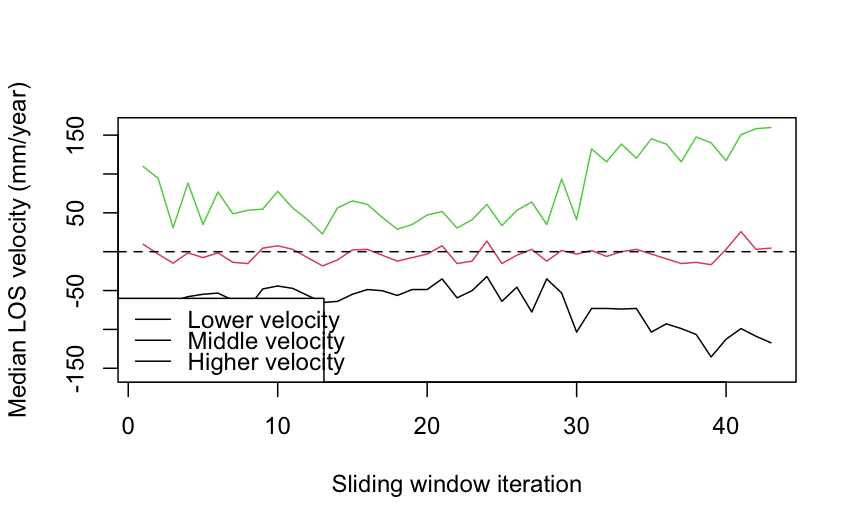

```r
legend(
  "bottomleft",
  legend = colnames(cluster_velocity_mat_k3),
  lty = 1
)
```

```r
table(cluster_status_mat_velocity_k3)
```

```
cluster_status_mat_velocity_k3
    0     1     2
86183 15738  5364
```

```r
status_counts_velocity_k3 <- t(
  apply(
    cluster_status_mat_velocity_k3,
    2,
    function(x) {
      table(
        factor(x, levels = c(0, 1, 2))
      )
    }
  )
)

colnames(status_counts_velocity_k3) <-
  c("Status0", "Status1", "Status2")

status_counts_velocity_k3
```

```
                 Status0 Status1 Status2
cluster_20161015    1992     503       0
cluster_20161021    2194       0     301
cluster_20161102    2249     246       0
cluster_20161114    1798     697       0
cluster_20161126    2171     324       0
cluster_20161208    1967     528       0
cluster_20161220    2200     295       0
cluster_20170101    2082     413       0
cluster_20170113    1975     520       0
cluster_20170125    1997     498       0
cluster_20170206    2044     451       0
cluster_20170218    1850     645       0
cluster_20170302    2009     486       0
cluster_20170314    2030     465       0
cluster_20170326    1950     545       0
cluster_20170407    2004     491       0
cluster_20170419    1875     620       0
cluster_20170501    1882     613       0
cluster_20170513    1905     590       0
cluster_20170525    2161     334       0
cluster_20170606    1954     541       0
cluster_20170618    1977     518       0
cluster_20170630    1893     602       0
cluster_20170712    2089     406       0
cluster_20170724    2119     376       0
cluster_20170805    1764     731       0
cluster_20170817    2261       0     234
cluster_20170829    1972     523       0
cluster_20170910    1779     716       0
cluster_20170922    2339       0     156
cluster_20171004    2124     371       0
cluster_20171016    2026     469       0
cluster_20171028    1887     608       0
cluster_20171109    1882     613       0
cluster_20171121    2017       0     478
cluster_20171203    1951       0     544
cluster_20171215    2115       0     380
cluster_20171227    1931       0     564
cluster_20180108    2020       0     475
cluster_20180120    2043       0     452
cluster_20180201    1879       0     616
cluster_20180213    1933       0     562
cluster_20180225    1893       0     602
```

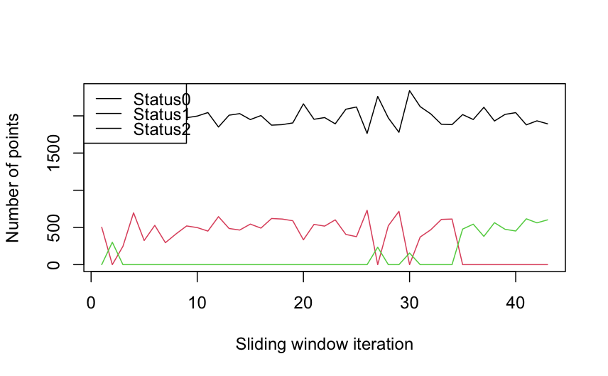

```r
matplot(
  status_counts_velocity_k3,
  type = "l",
  lty = 1,
  xlab = "Sliding window iteration",
  ylab = "Number of points"
)

legend(
  "topleft",
  legend = colnames(status_counts_velocity_k3),
  lty = 1
)
```

```r
# convert clusters
cadia_velocity_clusters_df_k3 <-
  as.data.frame(cluster_membership_mat_velocity_k3)

cadia_velocity_clusters_df_k3$PointID <-
  cadia_info_velocity$PointID

cadia_velocity_clusters_long_k3 <-
  cadia_velocity_clusters_df_k3 %>%
  pivot_longer(
    cols = -PointID,
    names_to = "Date",
    values_to = "RawCluster"
  )
```

```r
# convert status
cadia_velocity_status_df_k3 <-
  as.data.frame(cluster_status_mat_velocity_k3)

cadia_velocity_status_df_k3$PointID <-
  cadia_info_velocity$PointID

cadia_velocity_status_long_k3 <-
  cadia_velocity_status_df_k3 %>%
  pivot_longer(
    cols = -PointID,
    names_to = "Date",
    values_to = "Status"
  )
```

```r
# join cluster and status
cadia_velocity_results_k3 <-
  cadia_velocity_clusters_long_k3 %>%
  left_join(
    cadia_velocity_status_long_k3,
    by = c("PointID", "Date")
  )
```

```r
cadia_velocity_results_k3 <-
  cadia_velocity_results_k3 %>%
  mutate(
    Date = sub("^cluster_", "", Date),
    Date = as.Date(Date, format = "%Y%m%d")
  )
```

```r
cadia_velocity_results_k3 <-
  cadia_velocity_results_k3 %>%
  left_join(
    cadia_info_velocity,
    by = "PointID"
  )
```

```r
names(cadia_velocity_results_k3)
```

```
[1] "PointID"    "Date"       "RawCluster" "Status"     "lon"        "lat"        "coherence"
```

```r
head(cadia_velocity_results_k3)
```

| PointID | Date | RawCluster | Status | lon | lat | coherence |
| --- | --- | --- | --- | --- | --- | --- |
| 1 | 2016-10-15 | 1 | 0 | 148.9938 | -33.49118 | 0.796 |
| 1 | 2016-10-21 | 1 | 0 | 148.9938 | -33.49118 | 0.796 |
| 1 | 2016-11-02 | 3 | 0 | 148.9938 | -33.49118 | 0.796 |
| 1 | 2016-11-14 | 3 | 1 | 148.9938 | -33.49118 | 0.796 |
| 1 | 2016-11-26 | 2 | 0 | 148.9938 | -33.49118 | 0.796 |
| 1 | 2016-12-08 | 1 | 0 | 148.9938 | -33.49118 | 0.796 |

```r
table(cadia_velocity_results_k3$RawCluster)
```

```
    1     2     3
37316 34285 35684
```

```r
table(cadia_velocity_results_k3$Status)
```

```
    0     1     2
86183 15738  5364
```

```r
length(unique(cadia_velocity_results_k3$PointID))
```

```
[1] 2495
```

```r
length(unique(cadia_velocity_results_k3$Date))
```

```
[1] 43
```

```r
nrow(cadia_velocity_results_k3)
```

```
[1] 107285
```

```r
write.csv(
  cadia_velocity_results_k3,
  "../outputs/cadia_sliding_velocity_k3_w3_thresholds25_75.csv",
  row.names = FALSE
)
```

# 5. DBSCAN Sliding Window Temporal Clustering

Same concept / approach as K-means, but with DBSCAN. This means we have to tune the hyperparameters instead.

```r
# setup
library(dbscan)

window_size <- 3

n_pts_filtered <- nrow(cadia_D_filtered_sliding)
n_dates_filtered <- ncol(cadia_D_filtered_sliding)

n_iters_filtered <-
  n_dates_filtered - window_size + 1

iter_dates_filtered <-
  colnames(cadia_D_filtered_sliding)[
    window_size:n_dates_filtered
  ]
```

```r
# cluster membership matrix
dbscan_membership_mat <- matrix(
  NA,
  nrow = n_pts_filtered,
  ncol = n_iters_filtered
)

colnames(dbscan_membership_mat) <- paste0(
  "cluster_",
  sub("^D_", "", iter_dates_filtered)
)
```

```r
# noise matrix
dbscan_noise_mat <- matrix(
  NA,
  nrow = n_pts_filtered,
  ncol = n_iters_filtered
)

colnames(dbscan_noise_mat) <-
  colnames(dbscan_membership_mat)
```

We will test the process on one temporal window first.

```r
# initial test HP: minPts
minPts <- 5
```

We use minPts = 5 as a test. This aligns with the common rule to choose the minPts value in relation to dimensionality, often around double the number of dimensions as a starting point.

```r
# initial test HP: eps
x_test <- cadia_D_filtered_sliding[
  , 1:3,
  drop = FALSE
]

x_test <- sweep(
  x_test,
  1,
  x_test[, 1],
  FUN = "-"
)
```

```r
x_test_db <- x_test[, -1, drop = FALSE]
```

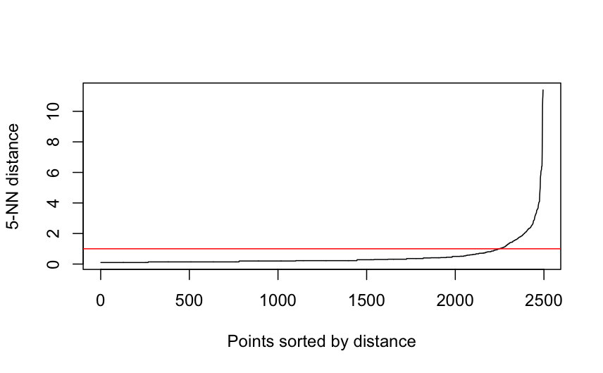

```r
kNNdistplot(
  x_test_db,
  k = minPts
)
abline(h = 1, col = "red")
```

The k-NN plot suggests an eps value of approximately 1 to be appropriate (for an initial test).

```r
eps <- 1
```

```r
# test w/ 1 window
db_test <- dbscan(
  x_test_db,
  eps = 1,
  minPts = 5
)

table(db_test$cluster)
```

```
   0    1    2
 187 2303    5
```

```r
mean(db_test$cluster == 0)
```

```
[1] 0.0749499
```

### Displacement Version: Temporal Clustering Loop

```r
# full loop
  # minPts = 5
  # eps = 1.2 v2

for (i in window_size:n_dates_filtered) {

  start_idx <- i - window_size + 1

  # current 3-date sliding window
  x <- cadia_D_filtered_sliding[
    , start_idx:i,
    drop = FALSE
  ]

  # reset each pt to 0 at start of window
  x <- sweep(
    x,
    1,
    x[, 1],
    FUN = "-"
  )

  # remove first col cause its all 0 now
  x_db <- x[, -1, drop = FALSE]

  db <- dbscan(
    x_db,
    eps = eps,
    minPts = minPts
  )

  iter <- i - window_size + 1

  # raw DBSCAN cluster
  dbscan_membership_mat[, iter] <-
    db$cluster

  # 1 = noise/anomaly candidate
  # 0 = belongs to a DBSCAN cluster
  dbscan_noise_mat[, iter] <-
    as.integer(db$cluster == 0)
}
```

```r
dim(dbscan_noise_mat)
```

```
[1] 2495   43
```

```r
table(dbscan_noise_mat)
```

```
dbscan_noise_mat
     0      1
100823   6462
```

```r
table(dbscan_membership_mat[, 1])
```

```
   0    1    2    3    4    5
 153 2319    8    5    5    5
```

```r
table(dbscan_membership_mat[, 20])
```

```
   0    1    2    3    4    5
  72 2398    9    5    6    5
```

```r
table(dbscan_membership_mat[, 43])
```

```
   0    1    2    3    4    5    6    7    8    9   10   11   12   13   14   15   16
 290 2058    6    8   13   10   12   45    5   13    7    5    5    4    5    4    5
```

```r
# inspect noise
noise_per_iter_eps1p2 <- colSums(
  dbscan_noise_mat == 1,
  na.rm = TRUE
)

summary(noise_per_iter)
```

```
   Min. 1st Qu.  Median    Mean 3rd Qu.    Max.
   72.0   100.0   130.0   150.3   198.0   290.0
```

```r
# inspect noise 2
noise_per_iter_eps1 <- colSums(
  dbscan_noise_mat == 1,
  na.rm = TRUE
)

summary(noise_per_iter_eps1)
```

```
   Min. 1st Qu.  Median    Mean 3rd Qu.    Max.
     94     123     161     193     266     395
```

```r
png(
  "cadia_dbscan_eps1p2_noise.png",
  width = 2400,
  height = 1800,
  res = 300
)

plot(
  noise_per_iter_eps1p2,
  type = "l",
  xlab = "Sliding window iteration",
  ylab = "Number of DBSCAN noise points",
  ylim = c(0, 300)
)

dev.off()
```

```r
png(
  "cadia_dbscan_eps_noise_comp.png",
  width = 2400,
  height = 1800,
  res = 300
)

plot(
  noise_per_iter_eps1,
  type = "l",
  lty = 1,
  ylim = c(0, 420),
  xlab = "Sliding window iteration",
  ylab = "Number of DBSCAN noise points"
)

lines(
  noise_per_iter_eps1p2,
  lty = 2
)

legend(
  "topleft",
  legend = c(
    "eps = 1.0",
    "eps = 1.2"
  ),
  lty = c(1, 2)
)

dev.off()
```

### Exporting the results:

```r
plot(
  noise_per_iter_eps1,
  type = "l",
  lty = 1,
  ylim = c(0, 500),
  xlab = "Sliding window iteration",
  ylab = "Number of DBSCAN noise points"
)

lines(
  noise_per_iter_eps1p2,
  lty = 2
)
```

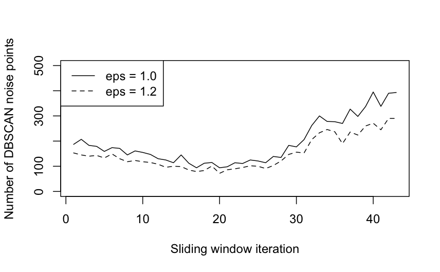

```r
legend(
  "topleft",
  legend = c(
    "eps = 1.0",
    "eps = 1.2"
  ),
  lty = c(1, 2)
)
```

```r
# convert to long: noise status
cadia_dbscan_noise_df <- as.data.frame(dbscan_noise_mat)

cadia_dbscan_noise_df$PointID <- cadia_info_sliding$PointID

cadia_dbscan_noise_long <- cadia_dbscan_noise_df %>%
  pivot_longer(
    cols = -PointID,
    names_to = "Date",
    values_to = "Noise"
  )
```

```r
# join clusters + noise status
cadia_dbscan_results <- cadia_dbscan_cluster_long %>%
  left_join(
    cadia_dbscan_noise_long,
    by = c("PointID", "Date")
  )
```

```r
# fix date
cadia_dbscan_results <- cadia_dbscan_results %>%
  mutate(
    Date = sub("^cluster_", "", Date),
    Date = as.Date(Date, format = "%Y%m%d")
  )
```

```r
# add other info
cadia_dbscan_results <- cadia_dbscan_results %>%
  left_join(
    cadia_info_sliding,
    by = "PointID"
  )
```

```r
# checks before exporting
names(cadia_dbscan_results)
```

```
[1] "PointID"   "Date"      "DBCluster" "Noise"     "lon"       "lat"       "coherence"
```

```r
head(cadia_dbscan_results)
```

| PointID | Date | DBCluster | Noise | lon | lat | coherence |
| --- | --- | --- | --- | --- | --- | --- |
| 1 | 2016-10-15 | 1 | 0 | 148.9938 | -33.49118 | 0.796 |
| 1 | 2016-10-21 | 1 | 0 | 148.9938 | -33.49118 | 0.796 |
| 1 | 2016-11-02 | 1 | 0 | 148.9938 | -33.49118 | 0.796 |
| 1 | 2016-11-14 | 1 | 0 | 148.9938 | -33.49118 | 0.796 |
| 1 | 2016-11-26 | 1 | 0 | 148.9938 | -33.49118 | 0.796 |
| 1 | 2016-12-08 | 1 | 0 | 148.9938 | -33.49118 | 0.796 |

```r
table(cadia_dbscan_results$Noise)
```

```
     0      1
100823   6462
```

```r
table(cadia_dbscan_results$DBCluster)
```

```
    0     1     2     3     4     5     6     7     8     9    10    11    12    13    14    15
 6462 99392   288   236   205   145   101   164    61    72    44    41    30    21     9     9
   16
    5
```

```r
sum(is.na(cadia_dbscan_results$lon))
```

```
[1] 0
```

```r
sum(is.na(cadia_dbscan_results$lat))
```

```
[1] 0
```

```r
View(cadia_dbscan_results)
```

```r
write.csv(
  cadia_dbscan_results,
  "../outputs/cadia_sw_dbscan_eps1p2_minpts5.csv",
  row.names = FALSE
)
```

### Testing other hyperparameters (eps, minPts):

```r
eps_values <- c(0.8, 1.0, 1.2, 1.5)
minPts_values <- c(5, 10)
```

```r
# wrapped loop to test
dbscan_tuning <- data.frame()

for (eps_val in eps_values) {

  for (minPts_val in minPts_values) {

    noise_mat_temp <- matrix(
      NA,
      nrow = n_pts_filtered,
      ncol = n_iters_filtered
    )

    for (i in window_size:n_dates_filtered) {

      start_idx <- i - window_size + 1

      x <- cadia_D_filtered_sliding[
        , start_idx:i,
        drop = FALSE
      ]

      # rebase window
      x <- sweep(
        x,
        1,
        x[, 1],
        FUN = "-"
      )

      db <- dbscan(
        x,
        eps = eps_val,
        minPts = minPts_val
      )

      iter <- i - window_size + 1

      # 1 = noise, 0 = clustered
      noise_mat_temp[, iter] <- as.integer(db$cluster == 0)
    }

    noise_per_iter_temp <- colSums(noise_mat_temp)

    dbscan_tuning <- rbind(
      dbscan_tuning,
      data.frame(
        eps = eps_val,
        minPts = minPts_val,
        Iteration = 1:n_iters_filtered,
        Date = iter_dates_filtered,
        NoisePoints = noise_per_iter_temp
      )
    )
  }
}
```

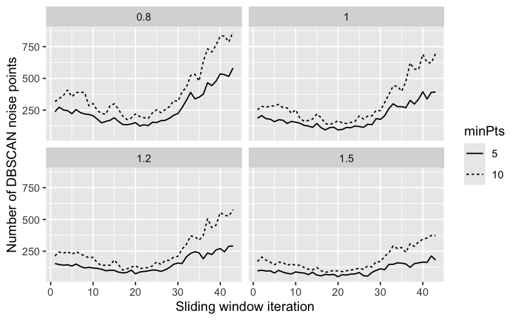

```r
# plot comparison
ggplot(
  dbscan_tuning,
  aes(
    x = Iteration,
    y = NoisePoints,
    group = interaction(eps, minPts),
    linetype = factor(minPts)
  )
) +
  geom_line() +
  facet_wrap(~ eps) +
  labs(
    x = "Sliding window iteration",
    y = "Number of DBSCAN noise points",
    linetype = "minPts"
  )
```

```r
# summary stats
dbscan_tuning_summary <- dbscan_tuning %>%
  group_by(eps, minPts) %>%
  summarise(
    MeanNoise = mean(NoisePoints),
    MedianNoise = median(NoisePoints),
    MaxNoise = max(NoisePoints),
    FinalNoise = last(NoisePoints),
    .groups = "drop"
  )

dbscan_tuning_summary
```

| eps | minPts | MeanNoise | MedianNoise | MaxNoise | FinalNoise |
| --- | --- | --- | --- | --- | --- |
| 0.8 | 5 | 260.2326 | 220 | 582 | 582 |
| 0.8 | 10 | 391.6744 | 320 | 865 | 865 |
| 1.0 | 5 | 192.9535 | 161 | 395 | 393 |
| 1.0 | 10 | 305.0930 | 253 | 695 | 695 |
| 1.2 | 5 | 150.2791 | 130 | 290 | 290 |
| 1.2 | 10 | 251.0465 | 210 | 577 | 577 |
| 1.5 | 5 | 100.5116 | 85 | 212 | 181 |
| 1.5 | 10 | 180.9070 | 151 | 374 | 373 |

- The plot shows that changing minPts from 5 to 10 mostly increases the noise across every eps value.

## 6. Sliding Window w/ 5 Acquisitions

Instead of 3.

### Median Cumulative Displacement

#### K = 2

```r
# temporal clustering setup
# sliding window size 5 instead of expanding by 1

set.seed(1234)

k <- 2
window_size <- 5
threshold_w5 <- -4 # change after checking

n_pts_filtered <- nrow(cadia_D_filtered_sliding)
n_dates_filtered <- ncol(cadia_D_filtered_sliding)

# number of overlapping sliding windows
n_iters_filtered <- n_dates_filtered - window_size + 1

# date representing each window = final date in window
iter_dates_filtered <- colnames(cadia_D_filtered_sliding)[
  window_size:n_dates_filtered
]
```

```r
# check
n_iters_filtered
```

```
[1] 41
```

```r
ncol(cluster_membership_mat_w5)
```

```
[1] 41
```

```r
length(iter_dates_filtered)
```

```
[1] 41
```

```r
# temporal clustering loop
# w = 5 version
set.seed(1234)

for (i in window_size:n_dates_filtered) {

  start_idx <- i - window_size + 1

  # Extract window
  x <- cadia_D_filtered_sliding[
    , start_idx:i,
    drop = FALSE
  ]

  # Rebase first observation to zero
  x <- sweep(x, 1, x[, 1], FUN = "-")

  # K-means
  km <- kmeans(
    x,
    centers = 2,
    nstart = 20
  )

  sil <- cluster::silhouette(
    km$cluster,
    dist(x)
  )

  silhouette_w5[iter] <- mean(sil[, "sil_width"])

  iter <- i - window_size + 1

  cluster_membership_mat_w5[, iter] <- km$cluster

  # Displacement at end of window
  latest_disp <- x[, ncol(x)]

  # Median for each raw K-means cluster
  cluster_medians <- tapply(
    latest_disp,
    km$cluster,
    median
  )

  # Sorted ONLY for plotting
  medians_mat_w5[iter, ] <- sort(cluster_medians)

  # Apply fixed threshold
  cluster_status <- ifelse(
    cluster_medians <= threshold_w5,
    1,
    0
  )

  # Give every point its cluster's status
  status_mat_w5[, iter] <-
    cluster_status[km$cluster]
}
```

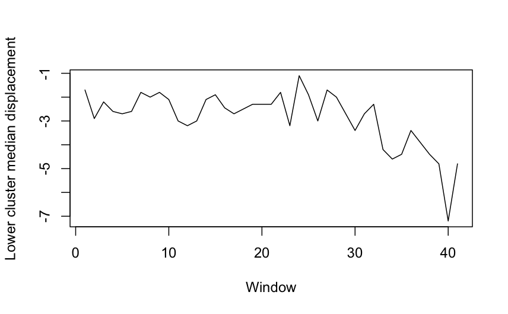

```r
# check threshold first
plot(
  medians_mat_w5[, 1],
  type = "l",
  xlab = "Window",
  ylab = "Lower cluster median displacement"
)
```

```r
head(medians_mat_w5)
```

```
     Lower_Cluster Higher_Cluster
[1,]          -1.7            1.3
[2,]          -2.9            1.3
[3,]          -2.2            0.4
[4,]          -2.6            0.6
[5,]          -2.7            0.4
[6,]          -2.6            1.2
```

```r
tail(medians_mat_w5)
```

```
      Lower_Cluster Higher_Cluster
[36,]          -3.4           3.10
[37,]          -3.9           4.40
[38,]          -4.4           2.45
[39,]          -4.8           2.20
[40,]          -7.2           1.80
[41,]          -4.8           3.00
```

```r
summary(medians_mat_w5)
```

```
 Lower_Cluster   Higher_Cluster
 Min.   :-7.20   Min.   :-0.400
 1st Qu.:-3.20   1st Qu.: 0.750
 Median :-2.60   Median : 1.000
 Mean   :-2.87   Mean   : 1.249
 3rd Qu.:-2.10   3rd Qu.: 1.600
 Max.   :-1.10   Max.   : 4.400
```

```r
# threshold checking
thresholds <- c(-3, -3.5, -4, -4.5, -5)

sapply(
  thresholds,
  function(t) sum(medians_mat_w5[, "Lower_Cluster"] <= t)
)
```

```
[1] 15  8  7  4  1
```

#### Results checking:

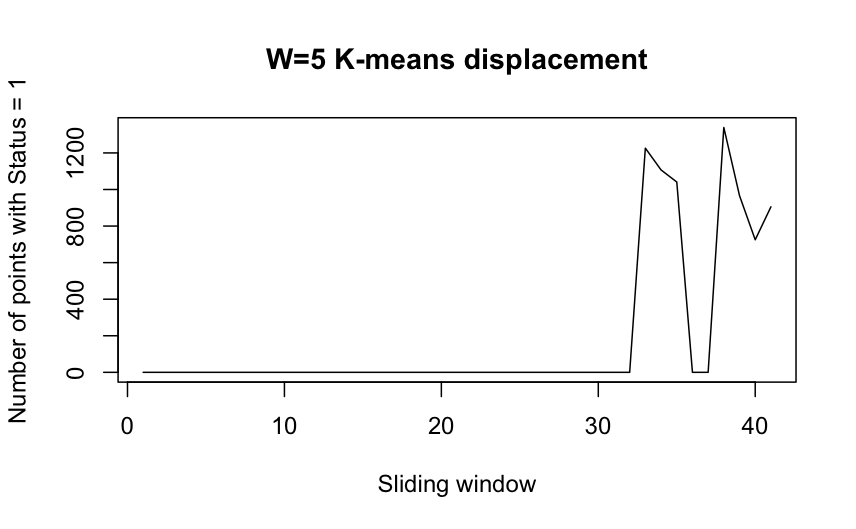

```r
flagged_w5 <- colSums(status_mat_w5 == 1)

plot(
  flagged_w5,
  type = "l",
  xlab = "Sliding window",
  ylab = "Number of points with Status = 1",
  main = "W=5 K-means displacement"
)
```

```r
summary(flagged_w5)
```

```
   Min. 1st Qu.  Median    Mean 3rd Qu.    Max.
    0.0     0.0     0.0   178.3     0.0  1339.0
```

```r
which(medians_mat_w5[, "Lower_Cluster"] <= threshold_w5)
```

```
[1] 33 34 35 38 39 40 41
```

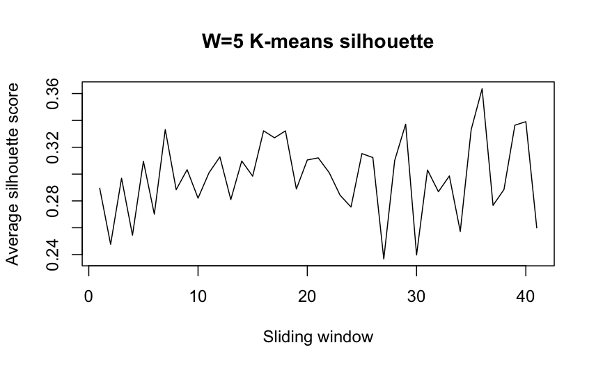

```r
# silhouette score
plot(
  silhouette_w5,
  type = "l",
  xlab = "Sliding window",
  ylab = "Average silhouette score",
  main = "W=5 K-means silhouette"
)
```

```r
summary(silhouette_w5)
```

```
   Min. 1st Qu.  Median    Mean 3rd Qu.    Max.
 0.2367  0.2821  0.3009  0.2984  0.3128  0.3636
```

```r
mean(silhouette_w5)
```

```
[1] 0.2984496
```

```r
# status changes
change_mat_w5 <- matrix(
  0,
  nrow = nrow(status_mat_w5),
  ncol = ncol(status_mat_w5)
)

change_mat_w5[, 2:ncol(change_mat_w5)] <-
  status_mat_w5[, 2:ncol(status_mat_w5)] !=
  status_mat_w5[, 1:(ncol(status_mat_w5) - 1)]

changes_w5 <- colSums(change_mat_w5)

change_prop_w5 <- colMeans(change_mat_w5)
```

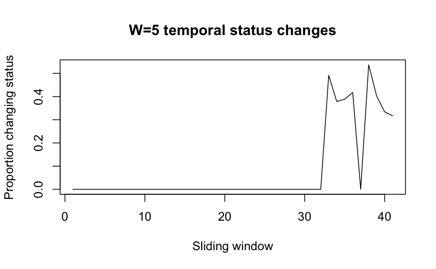

```r
plot(
  change_prop_w5,
  type = "l",
  xlab = "Sliding window",
  ylab = "Proportion changing status",
  main = "W=5 temporal status changes"
)
```

#### Exporting the results:

```r
# converting to long: cluster

cluster_df_w5 <- as.data.frame(
  cluster_membership_mat_w5
)

cluster_df_w5$PointID <- cadia_info_sliding$PointID

clusters_long_w5 <- cluster_df_w5 %>%
  pivot_longer(
    cols = -PointID,
    names_to = "Date",
    values_to = "RawCluster"
  )

# converting to long: status
status_df_w5 <- as.data.frame(status_mat_w5)

status_df_w5$PointID <- cadia_info_sliding$PointID

status_long_w5 <- status_df_w5 %>%
  pivot_longer(
    cols = -PointID,
    names_to = "Date",
    values_to = "Status"
  )
```

```r
# combining clusters and status
cadia_kmeans_w5_results <-
  clusters_long_w5 %>%
  left_join(
    status_long_w5,
    by = c("PointID", "Date")
  ) %>%
  mutate(
    Date = sub("^cluster_", "", Date),
    Date = as.Date(Date, format = "%Y%m%d")
  ) %>%
  left_join(
    cadia_info_sliding,
    by = "PointID"
  )
```

```r
# exporting
write.csv(
  cadia_kmeans_w5_results,
  "../outputs/cadia_sw_km2_disp_w5_k2_threshold4.csv",
  row.names = FALSE
)
```

### Median Velocity version

#### K = 2

```r
window_size <- 5
k <- 2

n_pts_filtered <- nrow(cadia_D_filtered_sliding)
n_dates_filtered <- ncol(cadia_D_filtered_sliding)

n_iters_vel_w5 <- n_dates_filtered - window_size + 1

iter_dates_vel_w5 <-
  colnames(cadia_D_filtered_sliding)[
    window_size:n_dates_filtered
  ]

cadia_all_dates <- as.Date(
  sub(
    "^D_",
    "",
    colnames(cadia_D_filtered_sliding)
  ),
  format = "%Y%m%d"
)
```

```r
cluster_membership_vel_w5 <- matrix(
  NA,
  nrow = n_pts_filtered,
  ncol = n_iters_vel_w5
)

status_vel_w5 <- matrix(
  NA,
  nrow = n_pts_filtered,
  ncol = n_iters_vel_w5
)

vel_medians_w5 <- matrix(
  NA,
  nrow = n_iters_vel_w5,
  ncol = 2
)

silhouette_vel_w5 <- numeric(n_iters_vel_w5)

colnames(vel_medians_w5) <-
  c("Lower_Cluster", "Higher_Cluster")

date_names_vel_w5 <- paste0(
  "cluster_",
  sub("^D_", "", iter_dates_vel_w5)
)

colnames(cluster_membership_vel_w5) <- date_names_vel_w5
colnames(status_vel_w5) <- date_names_vel_w5
```

```r
# temporal clustering loop
set.seed(1234)

for (i in window_size:n_dates_filtered) {

  start_idx <- i - window_size + 1
  iter <- i - window_size + 1

  # W5 displacement trajectory
  x <- cadia_D_filtered_sliding[
    , start_idx:i,
    drop = FALSE
  ]

  # Rebase
  x <- sweep(x, 1, x[, 1], FUN = "-")

  # K-means on trajectory
  km <- kmeans(
    x,
    centers = k,
    nstart = 20
  )

  cluster_membership_vel_w5[, iter] <- km$cluster

  # Actual acquisition dates
  window_dates <- cadia_all_dates[start_idx:i]

  time_days <- as.numeric(
    window_dates - window_dates[1]
  )

  # Regression velocity for each point
  point_velocity <- apply(
    x,
    1,
    function(y) coef(lm(y ~ time_days))[2]
  ) * 365.25

  # Median velocity of each raw cluster
  cluster_velocity <- tapply(
    point_velocity,
    km$cluster,
    median
  )

  vel_medians_w5[iter, ] <-
    sort(cluster_velocity)

  # Fixed velocity status
  cluster_status <- ifelse(
    cluster_velocity <= velocity_threshold,
    1,
    0
  )

  status_vel_w5[, iter] <-
    cluster_status[km$cluster]

  # Silhouette
  sil <- cluster::silhouette(
    km$cluster,
    dist(x)
  )

  silhouette_vel_w5[iter] <-
    mean(sil[, "sil_width"])
}
```

```r
head(vel_medians_w5)
```

```
     Lower_Cluster Higher_Cluster
[1,]     -15.52313      12.022813
[2,]     -24.97974       7.242026
[3,]     -16.44367      -1.317721
[4,]     -17.34938       3.652500
[5,]     -17.65375       3.043750
[6,]     -20.08875       7.913750
```

```r
tail(vel_medians_w5)
```

```
      Lower_Cluster Higher_Cluster
[36,]     -25.26312       22.52375
[37,]     -26.78500       25.56750
[38,]     -32.56813       14.91437
[39,]     -34.09000       16.13188
[40,]     -49.00437       16.74062
[41,]     -31.95937       20.39313
```

```r
summary(vel_medians_w5)
```

```
 Lower_Cluster    Higher_Cluster
 Min.   :-49.00   Min.   :-3.044
 1st Qu.:-24.98   1st Qu.: 4.261
 Median :-18.26   Median : 7.914
 Mean   :-20.74   Mean   : 8.363
 3rd Qu.:-15.52   3rd Qu.:11.262
 Max.   :-10.96   Max.   :25.567
```

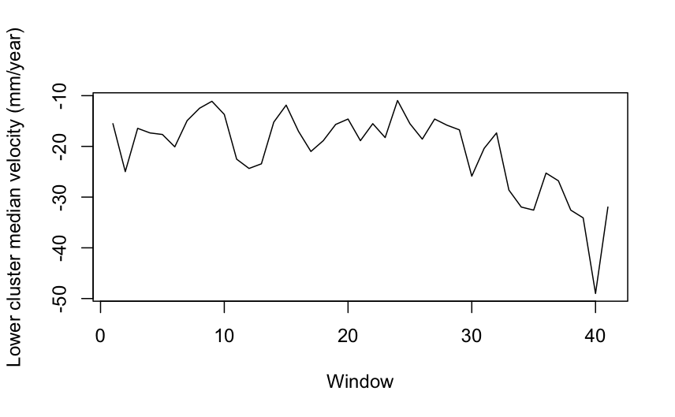

```r
plot(
  vel_medians_w5[, "Lower_Cluster"],
  type = "l",
  xlab = "Window",
  ylab = "Lower cluster median velocity (mm/year)"
)
```

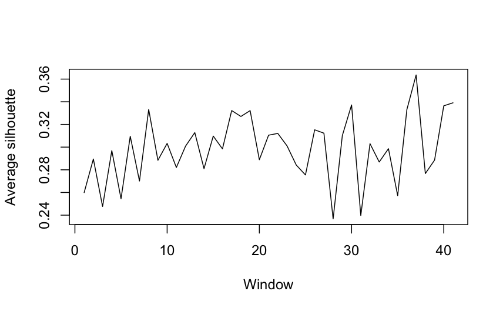

```r
plot(
  silhouette_vel_w5,
  type = "l",
  xlab = "Window",
  ylab = "Average silhouette"
)
```

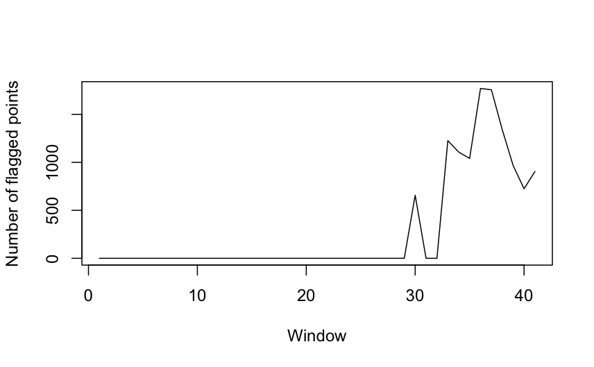

```r
# flagged pts
flagged_vel_w5 <- colSums(status_vel_w5 == 1)

plot(
  flagged_vel_w5,
  type = "l",
  xlab = "Window",
  ylab = "Number of flagged points"
)
```

#### Exporting the results:

```r
cluster_vel_df_w5 <- as.data.frame(
  cluster_membership_vel_w5
)

cluster_vel_df_w5$PointID <-
  cadia_info_sliding$PointID

cluster_vel_long_w5 <- cluster_vel_df_w5 %>%
  pivot_longer(
    cols = -PointID,
    names_to = "Date",
    values_to = "RawCluster"
  )
```

```r
status_vel_df_w5 <- as.data.frame(
  status_vel_w5
)

status_vel_df_w5$PointID <-
  cadia_info_sliding$PointID

status_vel_long_w5 <- status_vel_df_w5 %>%
  pivot_longer(
    cols = -PointID,
    names_to = "Date",
    values_to = "Status"
  )
```

```r
# combine
cadia_vel_w5_k2 <- cluster_vel_long_w5 %>%
  left_join(
    status_vel_long_w5,
    by = c("PointID", "Date")
  ) %>%
  mutate(
    Date = sub("^cluster_", "", Date),
    Date = as.Date(Date, format = "%Y%m%d")
  ) %>%
  left_join(
    cadia_info_sliding,
    by = "PointID"
  )
```

```r
# export
write.csv(
  cadia_vel_w5_k2,
  "../outputs/cadia_sw_vel_w5_k2.csv",
  row.names = FALSE
)
```

### DBSCAN

```r
# setup + test
window_size <- 5

i <- ncol(cadia_D_filtered_sliding)

start_idx <- i - window_size + 1

x_test_w5 <- cadia_D_filtered_sliding[
  , start_idx:i,
  drop = FALSE
]

x_test_w5 <- sweep(
  x_test_w5,
  1,
  x_test_w5[, 1],
  FUN = "-"
)

# Drop zero baseline
x_test_db_w5 <- x_test_w5[, -1, drop = FALSE]
```

```r
minPts <- 5
```

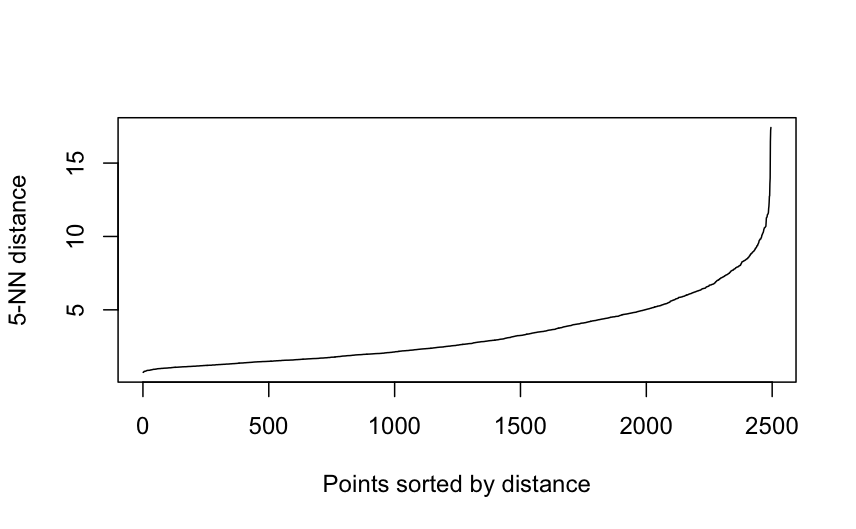

```r
kNNdistplot(
  x_test_db_w5,
  k = minPts
)
```

```r
# test
eps_values <- c(4, 5, 6)
minPts <- 5

for (e in c(4, 5, 6)) {

  db_test <- dbscan(
    x_test_db_w5,
    eps = e,
    minPts = 5
  )

  cat(
    "\neps =", e,
    "\nclusters =",
    length(unique(db_test$cluster[db_test$cluster != 0])),
    "\nnoise =",
    sum(db_test$cluster == 0),
    "\nnoise % =",
    round(mean(db_test$cluster == 0) * 100, 1),
    "%\n"
  )
}
```

```
eps = 4
clusters = 10
noise = 517
noise % = 20.7 %

eps = 5
clusters = 4
noise = 289
noise % = 11.6 %

eps = 6
clusters = 1
noise = 162
noise % = 6.5 %
```

```r
# setup after picking HPs
window_size <- 5
eps_w5 <- 5
minPts <- 5

n_pts_filtered <- nrow(cadia_D_filtered_sliding)
n_dates_filtered <- ncol(cadia_D_filtered_sliding)

n_iters_db_w5 <- n_dates_filtered - window_size + 1

iter_dates_db_w5 <-
  colnames(cadia_D_filtered_sliding)[
    window_size:n_dates_filtered
  ]

dbscan_membership_w5 <- matrix(
  NA,
  nrow = n_pts_filtered,
  ncol = n_iters_db_w5
)

dbscan_noise_w5 <- matrix(
  NA,
  nrow = n_pts_filtered,
  ncol = n_iters_db_w5
)

date_names_db_w5 <- paste0(
  "cluster_",
  sub("^D_", "", iter_dates_db_w5)
)

colnames(dbscan_membership_w5) <- date_names_db_w5
colnames(dbscan_noise_w5) <- date_names_db_w5
```

```r
# temporal clustering loop
for (i in window_size:n_dates_filtered) {

  start_idx <- i - window_size + 1
  iter <- i - window_size + 1

  x <- cadia_D_filtered_sliding[
    , start_idx:i,
    drop = FALSE
  ]

  # Rebase each point within window
  x <- sweep(
    x,
    1,
    x[, 1],
    FUN = "-"
  )

  # Remove constant zero baseline
  x_db <- x[, -1, drop = FALSE]

  db <- dbscan(
    x_db,
    eps = eps_w5,
    minPts = minPts
  )

  dbscan_membership_w5[, iter] <-
    db$cluster

  dbscan_noise_w5[, iter] <-
    as.integer(db$cluster == 0)
}
```

#### Results checking:

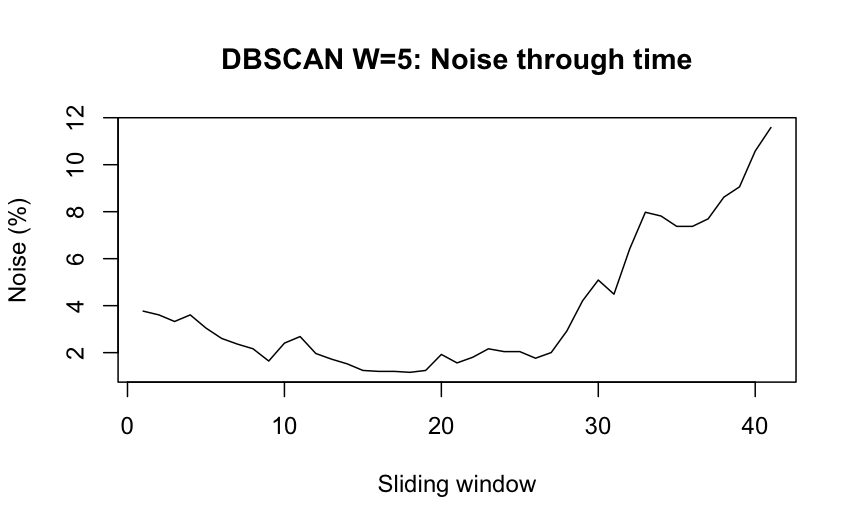

```r
noise_per_iter_w5 <- colSums(
  dbscan_noise_w5
)

noise_prop_w5 <- colMeans(
  dbscan_noise_w5
)

plot(
  noise_prop_w5 * 100,
  type = "l",
  xlab = "Sliding window",
  ylab = "Noise (%)",
  main = "DBSCAN W=5: Noise through time"
)
```

```r
summary(noise_prop_w5 * 100)
```

```
   Min. 1st Qu.  Median    Mean 3rd Qu.    Max.
  1.162   1.804   2.605   3.878   5.090  11.583
```

```r
summary(noise_prop_w5 * 100)
```

```
   Min. 1st Qu.  Median    Mean 3rd Qu.    Max.
  1.162   1.804   2.605   3.878   5.090  11.583
```

```r
summary(n_clusters_w5)
```

```
   Min. 1st Qu.  Median    Mean 3rd Qu.    Max.
  1.000   1.000   1.000   1.634   2.000   4.000
```

```r
table(n_clusters_w5)
```

```
n_clusters_w5
 1  2  3  4
22 15  1  3
```

#### Exporting the results:

```r
head(colnames(dbscan_membership_w5))
```

```
[1] "cluster_20161102" "cluster_20161114" "cluster_20161126" "cluster_20161208" "cluster_20161220" "cluster_20170101"
```

```r
head(colnames(dbscan_noise_w5))
```

```
[1] "cluster_20161102" "cluster_20161114" "cluster_20161126" "cluster_20161208" "cluster_20161220" "cluster_20170101"
```

```r
# converting to long: clusters
db_cluster_w5 <- as.data.frame(
  dbscan_membership_w5
)

db_cluster_w5$PointID <-
  cadia_info_sliding$PointID

db_cluster_long_w5 <- db_cluster_w5 %>%
  pivot_longer(
    cols = -PointID,
    names_to = "Date",
    values_to = "DBCluster"
  )
```

```r
# converting to nlong: noise
db_noise_w5 <- as.data.frame(
  dbscan_noise_w5
)

db_noise_w5$PointID <-
  cadia_info_sliding$PointID

db_noise_long_w5 <- db_noise_w5 %>%
  pivot_longer(
    cols = -PointID,
    names_to = "Date",
    values_to = "Noise"
  )
```

```r
# combine cluster + noise
cadia_dbscan_w5 <- db_cluster_long_w5 %>%
  left_join(
    db_noise_long_w5,
    by = c("PointID", "Date")
  ) %>%
  mutate(
    Date = sub("^cluster_", "", Date),
    Date = as.Date(Date, format = "%Y%m%d"),
    WindowSize = 5,
    Eps = 5,
    MinPts = 5
  ) %>%
  left_join(
    cadia_info_sliding,
    by = "PointID"
  )
```

```r
head(cadia_dbscan_w5)
```

| PointID | Date | DBCluster | Noise | WindowSize | Eps | MinPts | lon | lat | coherence |
| --- | --- | --- | --- | --- | --- | --- | --- | --- | --- |
| 1 | 2016-11-02 | 1 | 0 | 5 | 5 | 5 | 148.9938 | -33.49118 | 0.796 |
| 1 | 2016-11-14 | 1 | 0 | 5 | 5 | 5 | 148.9938 | -33.49118 | 0.796 |
| 1 | 2016-11-26 | 1 | 0 | 5 | 5 | 5 | 148.9938 | -33.49118 | 0.796 |
| 1 | 2016-12-08 | 1 | 0 | 5 | 5 | 5 | 148.9938 | -33.49118 | 0.796 |
| 1 | 2016-12-20 | 1 | 0 | 5 | 5 | 5 | 148.9938 | -33.49118 | 0.796 |
| 1 | 2017-01-01 | 1 | 0 | 5 | 5 | 5 | 148.9938 | -33.49118 | 0.796 |

```r
table(
  cadia_dbscan_w5$DBCluster,
  cadia_dbscan_w5$Noise
)
```

```
        0     1
  0     0  3967
  1 98151     0
  2   132     0
  3    27     0
  4    18     0
```

```r
nrow(cadia_dbscan_w5)
```

```
[1] 102295
```

```r
# should be 102295
```

```r
write.csv(
  cadia_dbscan_w5,
  "../outputs/cadia_sw_dbscan_w5_eps5_minpts5.csv",
  row.names = FALSE
)
```

## Altered Hierarchical Clustering Implementation

```r
start_window <- 10
k <- 2

n_dates <- ncol(cadia_D)
n_pts   <- nrow(cadia_D)
n_iters <- n_dates - start_window + 1

hc_membership <- matrix(
  NA,
  nrow = n_pts,
  ncol = n_iters
)

for (i in start_window:n_dates) {

  # 1. Expanding time-series matrix
  x <- cadia_D[, 1:i, drop = FALSE]

  # 2. Normal hierarchical clustering
  d <- dist(x, method = "euclidean")
  hc <- hclust(d, method = "ward.D2")
  current <- cutree(hc, k = k)

  iter <- i - start_window + 1

  if (iter == 1) {

    # First result: just keep HC labels
    hc_membership[, iter] <- current

  } else {

    previous <- hc_membership[, iter - 1]

    # 3. Check which labelling best corresponds
    #    to the previous partition
    keep <- sum(current == previous)

    swapped <- ifelse(current == 1, 2, 1)
    swap <- sum(swapped == previous)

    # Only change the NAMES 1/2 if necessary
    if (swap > keep) {
      current <- swapped
    }

    hc_membership[, iter] <- current
  }
}
```

```r
# calculate changes
change_mat_hc <- matrix(
  0,
  nrow = n_pts,
  ncol = n_iters
)

change_mat_hc[, 2:n_iters] <-
  hc_membership[, 2:n_iters] !=
  hc_membership[, 1:(n_iters - 1)]

change_mat_hc <- change_mat_hc * 1

changes_per_iter_hc <- colSums(change_mat_hc)

changes_pct_hc <- changes_per_iter_hc / n_pts * 100
```

```r
changes_pct_hc
```

```
 [1]  0.000000 30.339146 17.149256 28.411454  9.262518 46.736522 41.689330
 [8]  8.446649 10.342345 38.201888  7.726764 10.478323  7.886738  6.247000
[15]  5.039194  8.406655 34.962406 12.781955 26.907695 19.388898  8.174692
[22]  3.831387 13.253879  8.998560 13.893777  6.518957  4.047352 49.304111
[29] 35.354343 25.475924 31.506959 18.237082  7.782755 11.302192 21.020637
[36] 17.413214
```

```r
library(mclust)

ari_hc <- numeric(n_iters - 1)

for (j in 2:n_iters) {

  ari_hc[j - 1] <- adjustedRandIndex(
    hc_membership[, j - 1],
    hc_membership[, j]
  )
}
```

```r
# Date corresponding to the final acquisition in each expanding window
hc_dates <- colnames(cadia_D)[start_window:n_dates]

# Remove D_ prefix
hc_dates <- sub("^D_", "", hc_dates)

# Convert to Date
hc_dates <- as.Date(hc_dates, format = "%Y%m%d")
```

```r
length(hc_dates)
```

```
[1] 36
```

```r
length(changes_pct_hc)
```

```
[1] 36
```

```r
length(hc_dates[-1])
```

```
[1] 35
```

```r
length(ari_hc)
```

```
[1] 35
```

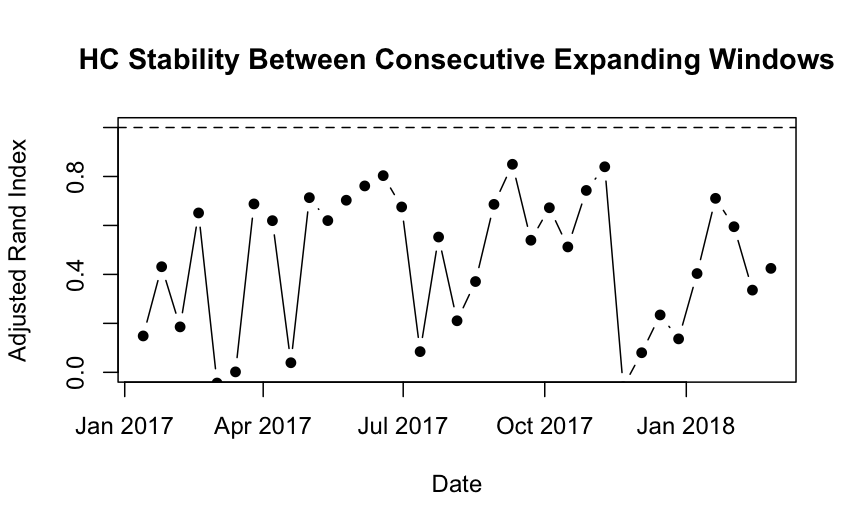

```r
plot(
  hc_dates[-1],
  ari_hc,
  type = "b",
  pch = 16,
  ylim = c(0, 1),
  xlab = "Date",
  ylab = "Adjusted Rand Index",
  main = "HC Stability Between Consecutive Expanding Windows"
)

abline(h = 1, lty = 2)
```

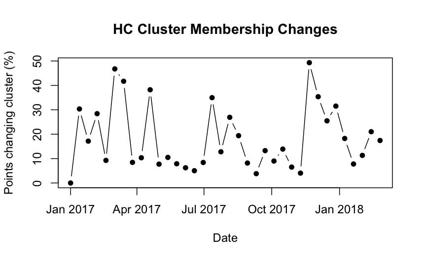

```r
plot(
  hc_dates,
  changes_pct_hc,
  type = "b",
  pch = 16,
  xlab = "Date",
  ylab = "Points changing cluster (%)",
  main = "HC Cluster Membership Changes"
)
```

```r
hc_check <- data.frame(
  Date = hc_dates[-1],
  Percent_Changed = changes_pct_hc[-1],
  ARI = ari_hc
)

hc_check
```

| Date | Percent_Changed | ARI |
| --- | --- | --- |
| 2017-01-13 | 30.339146 | 0.148607872 |
| 2017-01-25 | 17.149256 | 0.431344032 |
| 2017-02-06 | 28.411454 | 0.185624120 |
| 2017-02-18 | 9.262518 | 0.651033749 |
| 2017-03-02 | 46.736522 | -0.043705390 |
| 2017-03-14 | 41.689330 | 0.001839545 |
| 2017-03-26 | 8.446649 | 0.687835273 |
| 2017-04-07 | 10.342345 | 0.619516693 |
| 2017-04-19 | 38.201888 | 0.039177691 |
| 2017-05-01 | 7.726764 | 0.713475728 |

[output cut: 25 more lines]

```r
hc_check[order(-hc_check$Percent_Changed), ]
```

|  | Date | Percent_Changed | ARI |
| --- | --- | --- | --- |
| 27 | 2017-11-21 | 49.304111 | -0.059537521 |
| 5 | 2017-03-02 | 46.736522 | -0.043705390 |
| 6 | 2017-03-14 | 41.689330 | 0.001839545 |
| 9 | 2017-04-19 | 38.201888 | 0.039177691 |
| 28 | 2017-12-03 | 35.354343 | 0.080061909 |
| 16 | 2017-07-12 | 34.962406 | 0.084586916 |
| 30 | 2017-12-27 | 31.506959 | 0.136644785 |
| 1 | 2017-01-13 | 30.339146 | 0.148607872 |
| 3 | 2017-02-06 | 28.411454 | 0.185624120 |
| 18 | 2017-08-05 | 26.907695 | 0.210635238 |

[output cut: 25 more lines]

```r
start_window <- 10
k <- 2

n_dates <- ncol(cadia_D)
n_pts   <- nrow(cadia_D)
n_iters <- n_dates - start_window + 1

hc_membership_avg <- matrix(
  NA,
  nrow = n_pts,
  ncol = n_iters
)

for (i in start_window:n_dates) {

  # Expanding time-series matrix
  x <- cadia_D[, 1:i, drop = FALSE]

  # Hierarchical clustering - AVERAGE LINKAGE
  d <- dist(x, method = "euclidean")
  hc <- hclust(d, method = "average")
  current <- cutree(hc, k = k)

  iter <- i - start_window + 1

  if (iter == 1) {

    hc_membership_avg[, iter] <- current

  } else {

    previous <- hc_membership_avg[, iter - 1]

    # Check whether labels should be swapped
    keep <- sum(current == previous)

    swapped <- ifelse(current == 1, 2, 1)
    swap <- sum(swapped == previous)

    # Only swap cluster labels, not membership
    if (swap > keep) {
      current <- swapped
    }

    hc_membership_avg[, iter] <- current
  }
}
```

```r
change_mat_hc_avg <- matrix(
  0,
  nrow = n_pts,
  ncol = n_iters
)

change_mat_hc_avg[, 2:n_iters] <-
  hc_membership_avg[, 2:n_iters] !=
  hc_membership_avg[, 1:(n_iters - 1)]

change_mat_hc_avg <- change_mat_hc_avg * 1

changes_per_iter_hc_avg <- colSums(change_mat_hc_avg)

changes_pct_hc_avg <-
  changes_per_iter_hc_avg / n_pts * 100
```

```r
ari_hc_avg <- numeric(n_iters - 1)

for (j in 2:n_iters) {

  ari_hc_avg[j - 1] <- adjustedRandIndex(
    hc_membership_avg[, j - 1],
    hc_membership_avg[, j]
  )
}
```

```r
plot(
  hc_dates,
  changes_pct_hc,
  type = "l",
  ylim = range(c(changes_pct_hc, changes_pct_hc_avg)),
  xlab = "Date",
  ylab = "Points changing cluster (%)",
  main = "HC Linkage Comparison"
)

lines(
  hc_dates,
  changes_pct_hc_avg,
  lty = 2
)
```

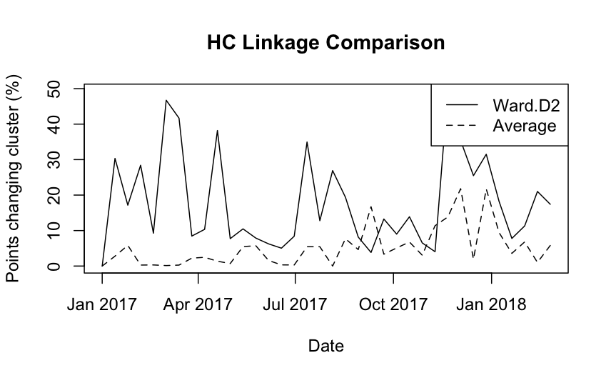

```r
legend(
  "topright",
  c("Ward.D2", "Average"),
  lty = c(1, 2)
)
```

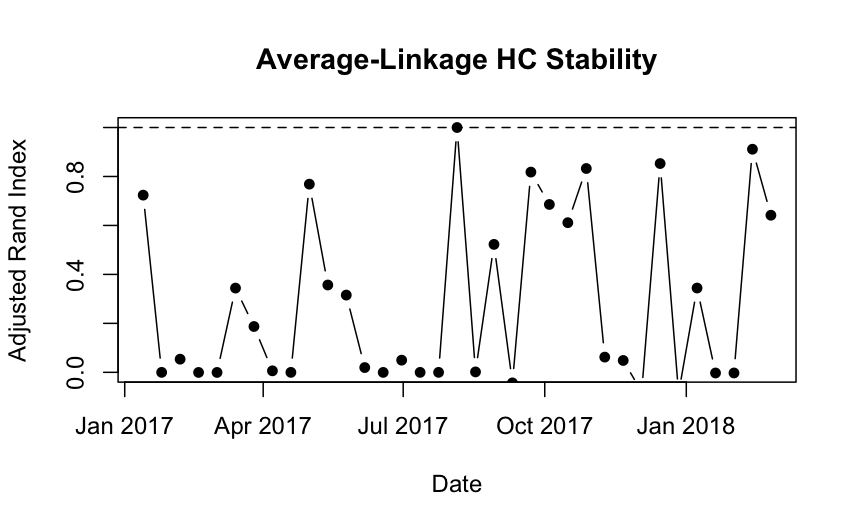

```r
plot(
  hc_dates[-1],
  ari_hc_avg,
  type = "b",
  pch = 16,
  ylim = c(0, 1),
  xlab = "Date",
  ylab = "Adjusted Rand Index",
  main = "Average-Linkage HC Stability"
)

abline(h = 1, lty = 2)
```

```r
summary(ari_hc_avg)
```

```
      Min.    1st Qu.     Median       Mean    3rd Qu.       Max.
-0.0855543 -0.0001537  0.0537554  0.2840800  0.6265013  1.0000000
```

```r
summary(changes_pct_hc_avg)
```

```
   Min. 1st Qu.  Median    Mean 3rd Qu.    Max.
 0.0000  0.9438  3.4594  5.1478  6.0670 21.8045
```

```r
cluster_sizes_avg <- data.frame(
  Date = hc_dates,
  Cluster1 = colSums(hc_membership_avg == 1),
  Cluster2 = colSums(hc_membership_avg == 2)
)

cluster_sizes_avg
```

| Date | Cluster1 | Cluster2 |
| --- | --- | --- |
| 2017-01-01 | 11763 | 739 |
| 2017-01-13 | 11774 | 728 |
| 2017-01-25 | 12501 | 1 |
| 2017-02-06 | 12466 | 36 |
| 2017-02-18 | 12499 | 3 |
| 2017-03-02 | 12488 | 14 |
| 2017-03-14 | 12464 | 38 |
| 2017-03-26 | 12193 | 309 |
| 2017-04-07 | 12501 | 1 |
| 2017-04-19 | 12332 | 170 |

[output cut: 26 more lines]

```r
cluster_sizes_avg$Cluster1_pct <-
  cluster_sizes_avg$Cluster1 / n_pts * 100

cluster_sizes_avg$Cluster2_pct <-
  cluster_sizes_avg$Cluster2 / n_pts * 100

cluster_sizes_avg
```

| Date | Cluster1 | Cluster2 | Cluster1_pct | Cluster2_pct |
| --- | --- | --- | --- | --- |
| 2017-01-01 | 11763 | 739 | 94.08895 | 5.91105423 |
| 2017-01-13 | 11774 | 728 | 94.17693 | 5.82306831 |
| 2017-01-25 | 12501 | 1 | 99.99200 | 0.00799872 |
| 2017-02-06 | 12466 | 36 | 99.71205 | 0.28795393 |
| 2017-02-18 | 12499 | 3 | 99.97600 | 0.02399616 |
| 2017-03-02 | 12488 | 14 | 99.88802 | 0.11198208 |
| 2017-03-14 | 12464 | 38 | 99.69605 | 0.30395137 |
| 2017-03-26 | 12193 | 309 | 97.52840 | 2.47160454 |
| 2017-04-07 | 12501 | 1 | 99.99200 | 0.00799872 |
| 2017-04-19 | 12332 | 170 | 98.64022 | 1.35978243 |

[output cut: 26 more lines]

```r
plot(
  hc_dates,
  cluster_sizes_avg$Cluster1_pct,
  type = "l",
  ylim = c(0, 100),
  xlab = "Date",
  ylab = "Points in cluster (%)",
  main = "Average-Linkage HC Cluster Sizes"
)

lines(
  hc_dates,
  cluster_sizes_avg$Cluster2_pct,
  lty = 2
)
```

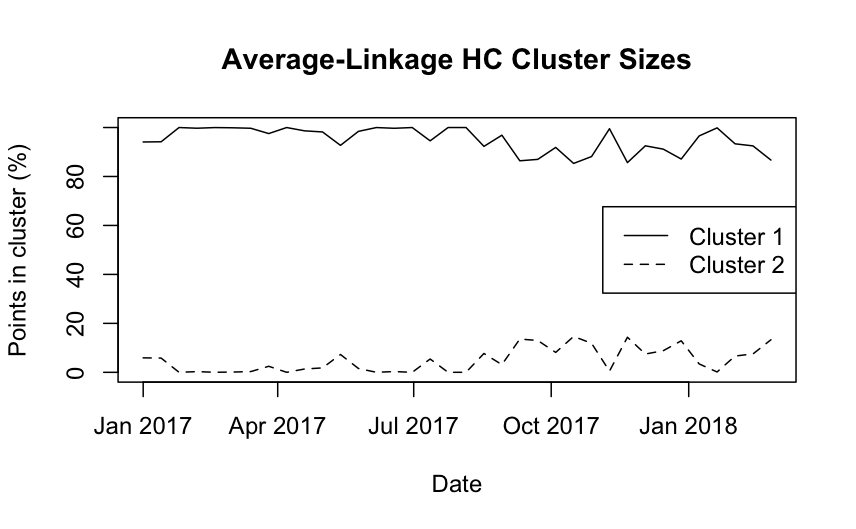

```r
legend(
  "right",
  c("Cluster 1", "Cluster 2"),
  lty = c(1, 2)
)
```

```r
data.frame(
  Date = as.Date(
    sub("^D_", "", iter_dates),
    format = "%Y%m%d"
  ),
  Cluster1_Median = cluster_medians[, 1],
  Cluster2_Median = cluster_medians[, 2],
  Percent_Status1 = percent_flagged
)
```

| Date | Cluster1_Median | Cluster2_Median | Percent_Status1 |
| --- | --- | --- | --- |
| 2017-01-01 | 0.40 | -3.90 | 0.00000 |
| 2017-01-13 | 0.60 | -3.80 | 0.00000 |
| 2017-01-25 | 0.70 | -3.60 | 0.00000 |
| 2017-02-06 | 0.80 | -3.90 | 0.00000 |
| 2017-02-18 | 0.60 | -4.90 | 0.00000 |
| 2017-03-02 | -0.10 | -5.50 | 0.00000 |
| 2017-03-14 | -0.40 | -5.90 | 0.00000 |
| 2017-03-26 | 0.10 | -5.95 | 0.00000 |
| 2017-04-07 | 0.00 | -6.20 | 0.00000 |
| 2017-04-19 | 0.00 | -6.60 | 0.00000 |

[output cut: 26 more lines]

Complete Linkage:

```r
start_window <- 10
k <- 2

n_dates <- ncol(cadia_D)
n_pts   <- nrow(cadia_D)
n_iters <- n_dates - start_window + 1

hc_membership_complete <- matrix(
  NA,
  nrow = n_pts,
  ncol = n_iters
)

for (i in start_window:n_dates) {

  x <- cadia_D[, 1:i, drop = FALSE]

  d <- dist(x, method = "euclidean")
  hc <- hclust(d, method = "complete")
  current <- cutree(hc, k = k)

  iter <- i - start_window + 1

  if (iter == 1) {

    hc_membership_complete[, iter] <- current

  } else {

    previous <- hc_membership_complete[, iter - 1]

    keep <- sum(current == previous)

    swapped <- ifelse(current == 1, 2, 1)
    swap <- sum(swapped == previous)

    if (swap > keep) {
      current <- swapped
    }

    hc_membership_complete[, iter] <- current
  }
}
```

```r
cluster_sizes_complete <- data.frame(
  Date = hc_dates,
  Cluster1 = colSums(hc_membership_complete == 1),
  Cluster2 = colSums(hc_membership_complete == 2)
)

cluster_sizes_complete$Cluster1_pct <-
  cluster_sizes_complete$Cluster1 / n_pts * 100

cluster_sizes_complete$Cluster2_pct <-
  cluster_sizes_complete$Cluster2 / n_pts * 100

cluster_sizes_complete
```

| Date | Cluster1 | Cluster2 | Cluster1_pct | Cluster2_pct |
| --- | --- | --- | --- | --- |
| 2017-01-01 | 9598 | 2904 | 76.771717 | 23.228283 |
| 2017-01-13 | 10830 | 1672 | 86.626140 | 13.373860 |
| 2017-01-25 | 11243 | 1259 | 89.929611 | 10.070389 |
| 2017-02-06 | 4993 | 7509 | 39.937610 | 60.062390 |
| 2017-02-18 | 3305 | 9197 | 26.435770 | 73.564230 |
| 2017-03-02 | 4776 | 7726 | 38.201888 | 61.798112 |
| 2017-03-14 | 10262 | 2240 | 82.082867 | 17.917133 |
| 2017-03-26 | 8035 | 4467 | 64.269717 | 35.730283 |
| 2017-04-07 | 2164 | 10338 | 17.309231 | 82.690769 |
| 2017-04-19 | 819 | 11683 | 6.550952 | 93.449048 |

[output cut: 26 more lines]

## HC V3:

Perform HC independently on every expanding time-series and use cluster overlap only to establish temporal cluster identity.

```r
cadia_D_hc <- cadia_D_filtered
```

```r
nrow(cadia_D_hc)
```

```
[1] 2495
```

```r
start_window <- 10
k <- 2

n_dates <- ncol(cadia_D_hc)
n_pts   <- nrow(cadia_D_hc)
n_iters <- n_dates - start_window + 1

hc_membership_jaccard <- matrix(
  NA,
  nrow = n_pts,
  ncol = n_iters
)

for (i in start_window:n_dates) {

  # Expanding time-series matrix
  x <- cadia_D_hc[, 1:i, drop = FALSE]

  # Normal hierarchical clustering
  d <- dist(x, method = "euclidean")
  hc <- hclust(d, method = "ward.D2")
  current <- cutree(hc, k = k)

  iter <- i - start_window + 1

  # First window: no previous clustering to match against
  if (iter == 1) {

    hc_membership_jaccard[, iter] <- current

  } else {

    previous <- hc_membership_jaccard[, iter - 1]

    # Jaccard similarities
    j11 <- sum(previous == 1 & current == 1) /
      sum(previous == 1 | current == 1)

    j12 <- sum(previous == 1 & current == 2) /
      sum(previous == 1 | current == 2)

    j21 <- sum(previous == 2 & current == 1) /
      sum(previous == 2 | current == 1)

    j22 <- sum(previous == 2 & current == 2) /
      sum(previous == 2 | current == 2)

    # Keep current labels vs swap them
    keep_score <- j11 + j22
    swap_score <- j12 + j21

    if (swap_score > keep_score) {
      current <- ifelse(current == 1, 2, 1)
    }

    hc_membership_jaccard[, iter] <- current
  }
}
```

```r
# calculate changes
change_mat_hc_jaccard <- matrix(
  0,
  nrow = n_pts,
  ncol = n_iters
)

change_mat_hc_jaccard[, 2:n_iters] <-
  hc_membership_jaccard[, 2:n_iters] !=
  hc_membership_jaccard[, 1:(n_iters - 1)]

change_mat_hc_jaccard <- change_mat_hc_jaccard * 1

changes_per_iter_hc_jaccard <-
  colSums(change_mat_hc_jaccard)

changes_pct_hc_jaccard <-
  changes_per_iter_hc_jaccard / n_pts * 100
```

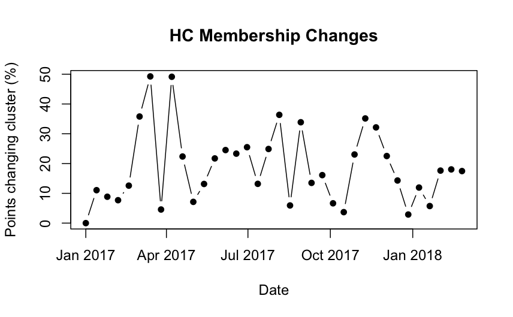

```r
plot(
  hc_dates,
  changes_pct_hc_jaccard,
  type = "b",
  pch = 16,
  xlab = "Date",
  ylab = "Points changing cluster (%)",
  main = "HC Membership Changes"
)
```

```r
table(
  Previous = hc_membership_jaccard[, j - 1],
  Current  = hc_membership_jaccard[, j]
)
```

```
        Current
Previous    1    2
       1 1614    0
       2  436  445
```

```r
j <- which.max(changes_pct_hc_jaccard)

hc_dates[j]
```

```
[1] "2017-03-14"
```

```r
changes_pct_hc_jaccard[j]
```

```
[1] 49.25852
```

```r
table(
  Previous = hc_membership_jaccard[, j - 1],
  Current  = hc_membership_jaccard[, j]
)
```

```
        Current
Previous    1    2
       1  828    0
       2 1229  438
```

Average linkage:

```r
# Average-linkage HC + Jaccard temporal matching

start_window <- 10
k <- 2

n_dates <- ncol(cadia_D_hc)
n_pts   <- nrow(cadia_D_hc)
n_iters <- n_dates - start_window + 1

hc_membership_avg_jaccard <- matrix(
  NA,
  nrow = n_pts,
  ncol = n_iters
)

for (i in start_window:n_dates) {

  # Expanding time-series matrix
  x <- cadia_D_hc[, 1:i, drop = FALSE]

  # Hierarchical clustering - AVERAGE LINKAGE
  d <- dist(x, method = "euclidean")
  hc <- hclust(d, method = "average")
  current <- cutree(hc, k = k)

  iter <- i - start_window + 1

  # First window: no previous clustering to match against
  if (iter == 1) {

    hc_membership_avg_jaccard[, iter] <- current

  } else {

    previous <- hc_membership_avg_jaccard[, iter - 1]

    # Jaccard similarities
    j11 <- sum(previous == 1 & current == 1) /
      sum(previous == 1 | current == 1)

    j12 <- sum(previous == 1 & current == 2) /
      sum(previous == 1 | current == 2)

    j21 <- sum(previous == 2 & current == 1) /
      sum(previous == 2 | current == 1)

    j22 <- sum(previous == 2 & current == 2) /
      sum(previous == 2 | current == 2)

    # Compare keeping labels with swapping labels
    keep_score <- j11 + j22
    swap_score <- j12 + j21

    # Only rename clusters if reversed correspondence is stronger
    if (swap_score > keep_score) {
      current <- ifelse(current == 1, 2, 1)
    }

    hc_membership_avg_jaccard[, iter] <- current
  }
}
```

```r
# calculate changes
change_mat_hc_avg_jaccard <- matrix(
  0,
  nrow = n_pts,
  ncol = n_iters
)

change_mat_hc_avg_jaccard[, 2:n_iters] <-
  hc_membership_avg_jaccard[, 2:n_iters] !=
  hc_membership_avg_jaccard[, 1:(n_iters - 1)]

change_mat_hc_avg_jaccard <- change_mat_hc_avg_jaccard * 1

changes_per_iter_hc_avg_jaccard <-
  colSums(change_mat_hc_avg_jaccard)

changes_pct_hc_avg_jaccard <-
  changes_per_iter_hc_avg_jaccard / n_pts * 100
```

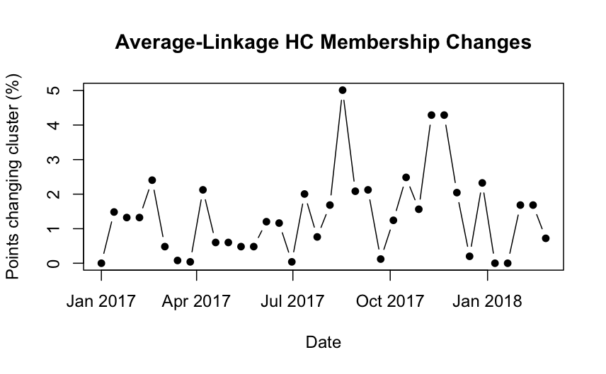

```r
plot(
  hc_dates,
  changes_pct_hc_avg_jaccard,
  type = "b",
  pch = 16,
  xlab = "Date",
  ylab = "Points changing cluster (%)",
  main = "Average-Linkage HC Membership Changes"
)
```

```r
cluster_sizes_avg_jaccard <- data.frame(
  Date = hc_dates,
  Cluster1 = colSums(hc_membership_avg_jaccard == 1),
  Cluster2 = colSums(hc_membership_avg_jaccard == 2)
)

cluster_sizes_avg_jaccard$Cluster1_pct <-
  cluster_sizes_avg_jaccard$Cluster1 / n_pts * 100

cluster_sizes_avg_jaccard$Cluster2_pct <-
  cluster_sizes_avg_jaccard$Cluster2 / n_pts * 100

cluster_sizes_avg_jaccard
```

| Date | Cluster1 | Cluster2 | Cluster1_pct | Cluster2_pct |
| --- | --- | --- | --- | --- |
| 2017-01-01 | 2490 | 5 | 99.79960 | 0.20040080 |
| 2017-01-13 | 2463 | 32 | 98.71743 | 1.28256513 |
| 2017-01-25 | 2494 | 1 | 99.95992 | 0.04008016 |
| 2017-02-06 | 2463 | 32 | 98.71743 | 1.28256513 |
| 2017-02-18 | 2467 | 28 | 98.87776 | 1.12224449 |
| 2017-03-02 | 2479 | 16 | 99.35872 | 0.64128257 |
| 2017-03-14 | 2479 | 16 | 99.35872 | 0.64128257 |
| 2017-03-26 | 2480 | 15 | 99.39880 | 0.60120240 |
| 2017-04-07 | 2457 | 38 | 98.47695 | 1.52304609 |
| 2017-04-19 | 2472 | 23 | 99.07816 | 0.92184369 |

[output cut: 26 more lines]

## HC V4:

Subsetted Cadia dataset again:

```r
start_window <- 10
k <- 2

n_dates <- ncol(cadia_D_hc)
n_pts   <- nrow(cadia_D_hc)
n_iters <- n_dates - start_window + 1

hc_membership_raw <- matrix(
  NA,
  nrow = n_pts,
  ncol = n_iters
)

for (i in start_window:n_dates) {

  # All data available up to current acquisition
  x <- cadia_D_hc[, 1:i, drop = FALSE]

  # Normal HC
  d <- dist(x, method = "euclidean")
  hc <- hclust(d, method = "ward.D2")

  # Cut dendrogram into 2 clusters
  current <- cutree(hc, k = k)

  iter <- i - start_window + 1

  # Store exactly what HC returns
  hc_membership_raw[, iter] <- current
}
```

```r
change_mat_hc_raw <- matrix(
  0,
  nrow = n_pts,
  ncol = n_iters
)

change_mat_hc_raw[, 2:n_iters] <-
  hc_membership_raw[, 2:n_iters] !=
  hc_membership_raw[, 1:(n_iters - 1)]

changes_pct_hc_raw <-
  colSums(change_mat_hc_raw) / n_pts * 100
```

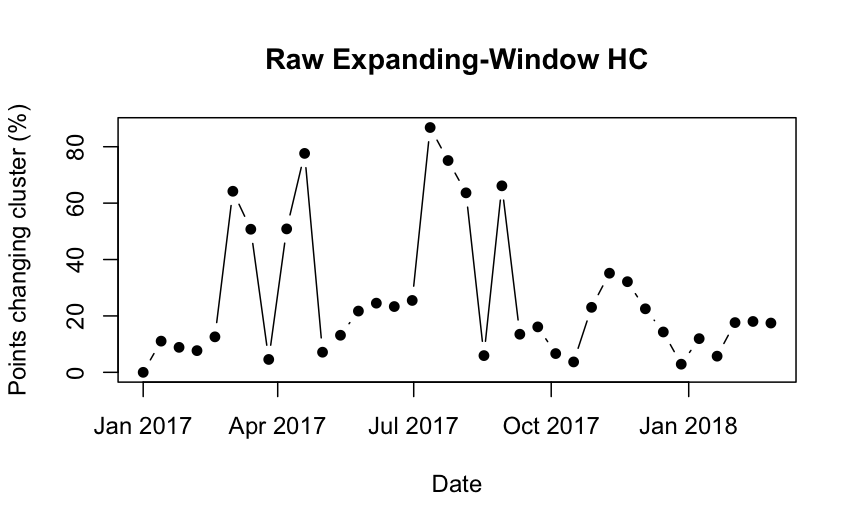

```r
plot(
  hc_dates,
  changes_pct_hc_raw,
  type = "b",
  pch = 16,
  xlab = "Date",
  ylab = "Points changing cluster (%)",
  main = "Raw Expanding-Window HC"
)
```

```r
plot(
  hc_dates,
  changes_pct_hc_raw,
  type = "l",
  ylim = range(c(
    changes_pct_hc_raw,
    changes_pct_hc_jaccard
  )),
  xlab = "Date",
  ylab = "Points changing cluster (%)",
  main = "Raw vs Jaccard-Aligned Ward HC"
)

lines(
  hc_dates,
  changes_pct_hc_jaccard,
  lty = 2
)
```

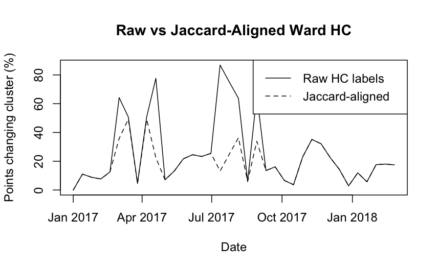

```r
legend(
  "topright",
  c("Raw HC labels", "Jaccard-aligned"),
  lty = c(1, 2)
)
```

Average linkage:

```r
start_window <- 10
k <- 2

n_dates <- ncol(cadia_D_hc)
n_pts   <- nrow(cadia_D_hc)
n_iters <- n_dates - start_window + 1

hc_membership_avg_raw <- matrix(
  NA,
  nrow = n_pts,
  ncol = n_iters
)

for (i in start_window:n_dates) {

  x <- cadia_D_hc[, 1:i, drop = FALSE]

  d <- dist(x, method = "euclidean")
  hc <- hclust(d, method = "average")

  current <- cutree(hc, k = k)

  iter <- i - start_window + 1
  hc_membership_avg_raw[, iter] <- current
}
```

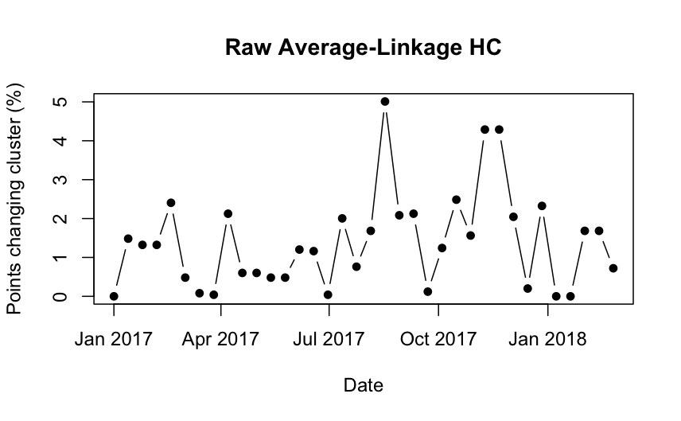

```r
# calculate changes

change_mat_avg_raw <- matrix(
  0,
  nrow = n_pts,
  ncol = n_iters
)

change_mat_avg_raw[, 2:n_iters] <-
  hc_membership_avg_raw[, 2:n_iters] !=
  hc_membership_avg_raw[, 1:(n_iters - 1)]

changes_pct_avg_raw <-
  colSums(change_mat_avg_raw) / n_pts * 100

plot(
  hc_dates,
  changes_pct_avg_raw,
  type = "b",
  pch = 16,
  xlab = "Date",
  ylab = "Points changing cluster (%)",
  main = "Raw Average-Linkage HC"
)
```

```r
cluster_sizes_avg_raw <- data.frame(
  Date = hc_dates,
  Cluster1 = colSums(hc_membership_avg_raw == 1),
  Cluster2 = colSums(hc_membership_avg_raw == 2)
)

cluster_sizes_avg_raw$Cluster1_pct <-
  cluster_sizes_avg_raw$Cluster1 / n_pts * 100

cluster_sizes_avg_raw$Cluster2_pct <-
  cluster_sizes_avg_raw$Cluster2 / n_pts * 100

cluster_sizes_avg_raw
```

| Date | Cluster1 | Cluster2 | Cluster1_pct | Cluster2_pct |
| --- | --- | --- | --- | --- |
| 2017-01-01 | 2490 | 5 | 99.79960 | 0.20040080 |
| 2017-01-13 | 2463 | 32 | 98.71743 | 1.28256513 |
| 2017-01-25 | 2494 | 1 | 99.95992 | 0.04008016 |
| 2017-02-06 | 2463 | 32 | 98.71743 | 1.28256513 |
| 2017-02-18 | 2467 | 28 | 98.87776 | 1.12224449 |
| 2017-03-02 | 2479 | 16 | 99.35872 | 0.64128257 |
| 2017-03-14 | 2479 | 16 | 99.35872 | 0.64128257 |
| 2017-03-26 | 2480 | 15 | 99.39880 | 0.60120240 |
| 2017-04-07 | 2457 | 38 | 98.47695 | 1.52304609 |
| 2017-04-19 | 2472 | 23 | 99.07816 | 0.92184369 |

[output cut: 26 more lines]

```r
ari_ward <- numeric(n_iters - 1)
ari_average <- numeric(n_iters - 1)

for (j in 2:n_iters) {

  ari_ward[j - 1] <- adjustedRandIndex(
    hc_membership_raw[, j - 1],
    hc_membership_raw[, j]
  )

  ari_average[j - 1] <- adjustedRandIndex(
    hc_membership_avg_raw[, j - 1],
    hc_membership_avg_raw[, j]
  )
}
```

```r
plot(
  hc_dates[-1],
  ari_ward,
  type = "l",
  ylim = c(-0.1, 1),
  xlab = "Date",
  ylab = "Adjusted Rand Index",
  main = "Temporal Stability of HC"
)

lines(
  hc_dates[-1],
  ari_average,
  lty = 2
)
```

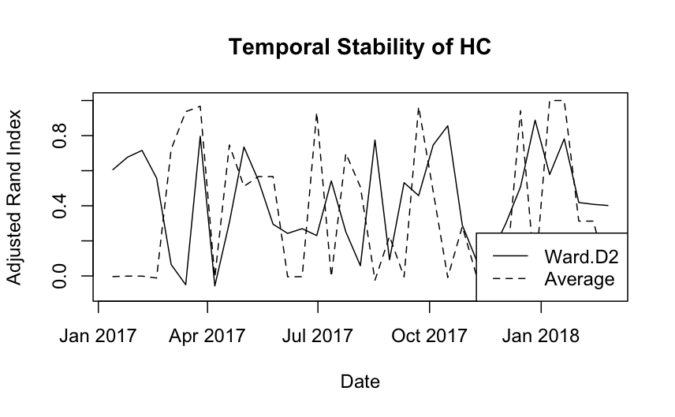

```r
legend(
  "bottomright",
  c("Ward.D2", "Average"),
  lty = c(1, 2)
)
```

```r
summary(ari_ward)
```

```
    Min.  1st Qu.   Median     Mean  3rd Qu.     Max.
-0.05704  0.24686  0.41856  0.42931  0.64126  0.88783
```

```r
summary(ari_average)
```

```
     Min.   1st Qu.    Median      Mean   3rd Qu.      Max.
-0.024321 -0.005318  0.282412  0.359167  0.710069  1.000000
```

- Average linkage in all approaches lead to extremely unbalanced cluster sizes, with one cluster consisting of almost all the points and another with sometimes only 1.
- Ward linkage produces a better mean/median ARI.